# 为哲学家写的简明数学史

# A Concise History of Mathematics for Philosophers

约翰·史迪威（John Stillwell），旧金山大学

John Stillwell, University of San Francisco

## 摘要

## Abstract

本书旨在勾勒数学及其历史的轮廓，并特别着重于那些动摇了数学哲学的事件。它的范围从古希腊发现无理数，一直延伸到十九、二十世纪关于无穷与证明之本性的发现。贯穿全书的主题是：直觉与逻辑、意义与存在，以及离散与连续。这些主题在新的数学发现的影响下不断演变，而它们的演变史在很大程度上就是数学哲学史。

This Element aims to present an outline of mathematics and its history, with particular emphasis on events that shook up its philosophy. It ranges from the discovery of irrational numbers in ancient Greece to the nineteenth- and twentieth-century discoveries on the nature of infinity and proof. Recurring themes are intuition and logic, meaning and existence, and the discrete and the continuous. These themes have evolved under the influence of new mathematical discoveries, and the story of their evolution is, to a large extent, the story of philosophy of mathematics.

关键词：数学，哲学

Keywords: mathematics, philosophy

# 序言

# Preface

自古以来，数学与其哲学之间就一直存在着角力。每当关于数学本性的某种观点似乎已经确立，总会有新的数学发现出现并将其打破。于是，毕达哥拉斯学派“万物皆数”的观点被无理长度的发现所打破，数学哲学不得不扩展，把几何作为一个独立的领域包括进来。但这又引出了一个问题：几何的观点能否与数的观点相调和？如果能，又该如何调和？千百年来，事情就这样一直发展下去。

Since ancient times, there has been a struggle between mathematics and its philosophy. As soon as there seems to be a settled view of the nature of mathematics, some new mathematical discovery comes along to disrupt it. Thus, the Pythagorean view that ‘all is number’ was disrupted by the discovery of irrational lengths, and the philosophy of mathematics had to expand to include a separate field of geometry. But this raised the question, Can the geometric view be reconciled with the numerical view? If so, how? And so it went, for millennia.

在许多情况下，数学的进展迫使人们接受此前被认为不可能或自相矛盾的概念，从而改变了人们对数学的看法。数学就这样扰动了哲学。反过来，哲学则通过指出矛盾、并提出如何澄清概念以消除这些矛盾，使数学保持诚实。有时哲学家与数学家是同一个人——例如笛卡尔、莱布尼茨或波尔查诺——因此人们几乎可以说，数学是哲学中一个特别丰富而稳定的分支。

In many cases, advances in mathematics changed ideas about mathematics, by forcing the acceptance of concepts previously thought impossible or paradoxical. Thus mathematics disrupted philosophy. In the opposite direction, philosophy kept mathematics honest by pointing out contradictions and suggesting how concepts might be clarified in order to resolve them. Sometimes the philosopher and the mathematician were one and the same person – such as Descartes, Leibniz, or Bolzano – so one might almost say that mathematics is an especially rich and stable branch of philosophy.

无论如何，要理解数学哲学的过去与现状，首先必须理解数学及其历史。本书的目的，是对数学及其历史作一简要介绍，并特别着重于那些动摇了数学哲学的事件。如果你愿意，也可以说这是一本关于“写给哲学家的数学”的书。我尽量不采取某种特定的哲学立场，只想说明我相信：数学引导哲学，多于哲学引导数学。作为推论，我相信数学家对哲学作出过重要贡献，即使那并非他们的本意。

At any rate, if one is to understand the past and present state of the philosophy of mathematics, one must first understand mathematics, and its history. The aim of the present Element is to give a brief introduction to mathematics and its history, with particular emphasis on events that shook up its philosophy. If you like, it is a book on ‘mathematics for philosophers’. I try not to take a particular philosophical position, except to say that I believe that mathematics guides philosophy, more so than the other way round. As a corollary, I believe that mathematicians have made important contributions to philosophy, even when it was not their intention.

每一节都以对将要讨论的主题的预览开始，并以一个小节结束，突出该节数学内容所引发的哲学问题。同样的主题在各节中反复出现——直觉与逻辑、意义与存在、离散与连续——但它们在新的数学发现的影响下不断演变。

Each section begins with a preview of topics to be discussed and ends with a section highlighting the philosophical questions raised by the mathematics. The same themes recur from section to section – intuition and logic, meaning and existence, and the discrete and the continuous – but they evolve under the influence of new mathematical discoveries.

专家们也许会惊讶于本书很少甚至没有提及二十世纪显赫一时的各种数学哲学——例如柏拉图主义、逻辑主义、形式主义、唯名论和直觉主义。部分原因是我认为它们都不够充分，但主要原因是我希望在不受标签影响的情况下审视数学哲学。我想尽可能多地呈现在哲学上富有启发的数学，而让读者自己决定应如何用哲学术语对其进行分类和贴标签。我希望本书能为读者提供一面“数学透镜”，借以审视许多哲学问题。

Experts may be surprised that there is little or no mention of philosophies of mathematics that were prominent in the twentieth century – platonism, logicism, formalism, nominalism, and intuitionism, for example. This is partly because I find none of them adequate, but mainly because I hope to look at the philosophy of mathematics without being influenced by labels. I want to present as much philosophically instructive mathematics as possible and leave readers to decide how it should be sorted and labelled in philosophical terms. My hope is that this Element will equip readers with a ‘mathematical lens’ with which to view many philosophical issues.

感谢 Jeremy Avigad、Rossella Lupacchini、Wilfried Sieg 以及一位匿名审稿人提出的有益意见，这些意见带来了许多改进。

I thank Jeremy Avigad, Rossella Lupacchini, Wilfried Sieg, and an anonymous referee for their helpful comments, which have resulted in many improvements.

# 1 无理数与几何

# 1 Irrational Numbers and Geometry

### 预览

### PREVIEW

数学哲学中许多问题的源头——证明与真理的本性；数的意义与存在；无穷的作用；以及几何、代数与算术之间的关系——是约公元前300年欧几里得的《几何原本》。《几何原本》最著名的是它的公理化几何，即欧几里得几何，其中包括若干标志性结果的证明，例如勾股定理，以及恰好存在五种正多面体。然而，《几何原本》也包含数论的基本思想，例如素数有无穷多个、求最大公因数的欧几里得算法，以及（与之等价的）唯一素因数分解。

The source of many issues in the philosophy of mathematics – the nature of proof and truth; the meaning and existence of numbers; the role of infinity; and the relation between geometry, algebra, and arithmetic – is Euclid’s *Elements* from around 300 BCE. The *Elements* is best known for its axiomatic geometry – Euclidean geometry – which includes proofs of signature results such as the Pythagorean theorem and the existence of exactly five regular polyhedra. However, the *Elements* also includes fundamental ideas of number theory, such as the existence of infinitely many prime numbers, the Euclidean algorithm for greatest common divisor, and (an equivalent of) unique prime factorization.

在欧几里得的时代，正如今天一样，几何与数论之间存在着一道概念鸿沟——即度量与计数之间、或连续与离散之间的鸿沟。造成这道鸿沟的主要原因是无理量的存在；它们在欧几里得之前由毕达哥拉斯学派发现，到《几何原本》成书时，已成为一套精妙的“比例论”的研究对象。这套理论见于《几何原本》第五卷，在连续与离散之间架起了一座脆弱的桥梁。几个世纪以来，后世数学家的工作逐渐加固了这座桥梁，但这一过程并非没有哲学冲突和数学上的意外。这些问题就是本节和下一节的主题。

In Euclid‘s time, as now, there was a conceptual gulf between geometry and number theory – between measuring and counting, or between the continuous and the discrete. The major reason for this gulf was the existence of irrationals, discovered before Euclid’s time by the Pythagoreans and, by the time of the *Elements*, the subject of a sophisticated ‘theory of proportions’. This theory, in Book V of the *Elements*, made a tenuous bridge between the continuous and the discrete. The bridge was gradually strengthened over the centuries by the work of later mathematicians, but not without philosophical conflicts and mathematical surprises. These issues are the subject of this section and the next.

## 1.1 勾股定理

## 1.1 The Pythagorean Theorem

勾股定理在人类历史上曾被多次独立发现，出现在若干不同的文化中。因此，如果说有哪一条定理能代表数学——及其普遍性——那就是它了。

The Pythagorean theorem was discovered independently several times in human history, and in several different cultures. So if any theorem typifies mathematics – and its universality – this is it.

图 1 说明了这条定理：（白色）直角三角形斜边上的（灰色）正方形，等于另外两边上的（黑色）正方形之和。图 2 给出了这条定理一个可信的“看图证明”：灰色正方形等于大正方形减去三角形的四个副本，而后者又等于两个黑色正方形之和。该定理的大多数独立发现大概都是如此，事实上，人类视觉系统确实促成了许多数学发现。尽管如此，为此后两千年数学定下方向的，却是通往定理的一条截然不同的公理化道路，我们将在第 1.4 节讨论。

Figure 1 illustrates the theorem: the (grey) square on the hypotenuse of the (white) right-angled triangle is equal to sum of the (black) squares on the other two sides. Figure 2 shows a plausible ‘proof by picture’ of the theorem: the grey square equals the big square minus four copies of the triangle, which in turn equals the sum of the two black squares. Most of the independent discoveries of the theorem were probably like this, and indeed the human visual system has many mathematical discoveries to its credit. Nevertheless, it was the radically different axiomatic path to theorems, discussed in Section 1.4, that set the direction of mathematics for the next 2000 years.

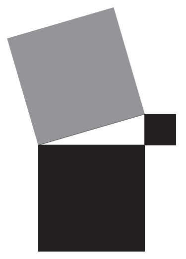

**图 1** 勾股定理。

**Figure 1** The Pythagorean theorem.

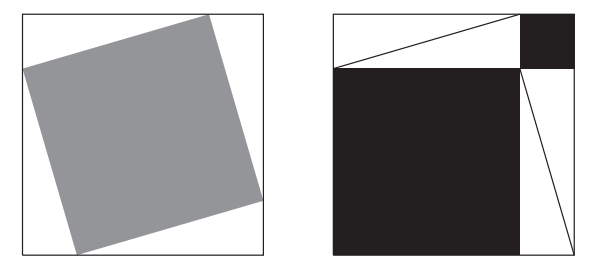

**图 2** 看见勾股定理。

**Figure 2** Seeing the Pythagorean theorem.

但在公理化道路确立之前，勾股定理已引发了另一项重要的概念发展：长度与数之间的区分。相传毕达哥拉斯学派的哲学是“万物皆数”，其起因是发现整数比支配着音乐的和谐。当人们在几何中发现无理比时——正是由于勾股定理——这一哲学便被推翻了。

But before the axiomatic path was established, the Pythagorean theorem provoked another important conceptual development: a distinction between length and number. Legend has it that the philosophy of the Pythagoreans was ‘all is number’, prompted by the discovery that whole number ratios govern musical harmony. This philosophy was overturned when irrational ratios were found in geometry – because of the Pythagorean theorem.

## 1.2 无理性

## 1.2 Irrationality

勾股定理谈论的是平方和——我们将在下文进一步讨论这一运算——但它也间接地告诉我们一些关于长度的事情。特别是，它说明：如果一个三角形两条互相垂直的边长度都是 1，那么它的斜边长度 $l$ 的平方等于 2。用现代记号 $l2$ 表示边长为 $l$ 的正方形，我们有 $l2=12+12=2$。

The Pythagorean theorem talks about sums of squares – an operation we will say more about below – but indirectly, it also tells us something about lengths. In particular, it says that if a triangle has perpendicular sides of length 1, then its hypotenuse has the length $l$ whose square is 2. Using the modern notation $l2$ to denote the square of side $l$, we have $l2=12+12=2$.

现在（仍使用现代记号），假设 $l$ 是有理数，此时我们可以设 $l=m/n$，其中 $m$ 和 $n$ 是整数。我们还可以假设 $m$ 与 $n$ 除 1 以外没有公因数，因为任何其他公因数都可以预先从 $m$ 和 $n$ 中约去，而不改变 $l$。在这些条件下，我们可以通过下面一系列推导得出矛盾（这些推导大概可以追溯到毕达哥拉斯学派，但这类证明已知最早的线索见于亚里士多德的《前分析篇》1.23）：

Now (again using modern notation), suppose that $l$ is rational, in which case we can suppose that $l=m/n$, where $m$ and $n$ are whole numbers. We can also suppose that $m$ and $n$ have no common divisor except 1, since any other common divisor could be divided out of $m$ and $n$ in advance, without changing $l$. Under these conditions we can derive a contradiction by the following series of implications (these probably go back to the Pythagoreans, but the first known hint of such a proof is in Aristotle’s *Prior Analytics* 1.23):

$$l=m/n⇒2=m2/n2（两边平方）(squaring both sides)⇒2n2=m2（两边同乘以 n²）(multiplying both sides by n²)⇒m2 is even / 是偶数⇒m is even, say, / 是偶数，设 =2p（因为奇数的平方是奇数）(since the square of an odd number is odd)⇒2n2=(2p)2=4p2（把 m = 2p 代入 2n² = m²）(substituting m = 2p in 2n² = m²)⇒n2=2p2⇒n2 is even / 是偶数⇒n is even / 是偶数⇒2 divides both m and n / 同时整除 m 与 n，与没有公因数的假设矛盾。contrary to the assumption of no common divisor.$$

既然假设 $l$ 是整数之比会导致矛盾，$l$ 就是一个无理长度。希腊人常常这样表述这一点：两直角边相等的直角三角形，其直角边与斜边是*不可公度的*——它们不是任何共同度量单位的整数倍。

Since it is contradictory to assume that $l$ is a ratio of whole numbers, $l$ is an irrational length. The Greeks often expressed this by saying that the side and hypotenuse of the right-angled triangle with equal sides are *incommensurable* – not whole number multiples of any common unit of measure.

在毕达哥拉斯学派看来，缺乏共同的长度单位意味着长度不是数，因为在他们那里，“数”就是整数及其比。特别是，长度的和与积未必像数的和与积那样，因此“平方和”这一概念需要澄清。在下一节中，我们将看到欧几里得是如何处理长度的和与积的。

In the view of the Pythagoreans, the lack of a common unit of length meant that lengths are not numbers, because ‘numbers’ to them were whole numbers and their ratios. In particular, sums and products of lengths are not necessarily like sums and products of numbers, so the concept of ‘sum of squares’ needs clarification. In the next section we will see how Euclid handled sums and products of lengths.

## 1.3 长度与数的运算

## 1.3 Operations on Lengths and Numbers

毕达哥拉斯之后的希腊数学家既否认无理长度可以是数，又允许它们被平方和相加，因此他们不得不用纯几何的方式来定义和与积。

By denying that irrational lengths could be numbers, yet allowing that they could be squared and added, the Greek mathematicians after Pythagoras had to define sum and product in purely geometric terms.

两个长度之和按图 3 所提示的显而易见的方式定义。长度由两条线段 $a$ 和 $b$ 表示，把这两条线段首尾相接，就得到 $a+b$。由此容易推出 $a+b=b+a$ 以及 $a+(b+c)=(a+b)+c$（交换律与结合律）。同样清楚的是，由于长度之和仍是长度，任意多个长度都可以相加。因此，就加法而言，长度的行为与数完全一样。

The sum of two lengths is defined in the obvious way suggested by Figure 3. The lengths are represented by two line segments $a$ and $b$, and $a+b$ is obtained by joining these segments end to end. It follows easily that $a+b=b+a$ and $a+(b+c)=(a+b)+c$ (commutative and associative laws). It is also clear, since the sum of lengths is a length, that any number of lengths can be added. Thus lengths behave exactly like numbers as far as addition is concerned.

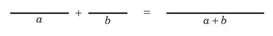

**图 3** 两个长度之和。

**Figure 3** The sum of two lengths.

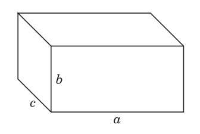

**图 4** 三个长度之积。

**Figure 4** The product of three lengths.

积的行为就没有这么简单了。长度 $a$ 与 $b$ 之积不是一个长度，而是以 $a$、$b$ 为两条互相垂直的边的矩形。长度 $a$、$b$、$c$ 之积则是以 $a$、$b$、$c$ 为三条互相垂直的棱的长方体（图 4）。

The behaviour of products is not so simple. The product of lengths $a$ and $b$ is not a length but the rectangle with perpendicular sides $a$ and $b$. And the product of lengths $a$, $b$, and $c$ is the rectangular box with perpendicular sides $a$, $b$, and $c$ (Figure 4).

由这些定义显然可得 $ab=ba$ 以及 $a(bc)=(ab)c$，并且还可以看出 $a(b+c)=ab+ac$（后者实际上是欧几里得《几何原本》第二卷命题 1 的一个特例）。因此，在和与积有定义的范围内，长度满足与正数相同的运算律。问题在于它们只在有限的范围内有定义，因此长度的代数是残缺的。三个以上长度的积不被允许，因为它们没有几何对应物。同样，只有当各个积具有相同的“维数”，即为相同个数的长度之积时，它们才能相加。

It is clear from these definitions that $ab=ba$ and $a(bc)=(ab)c$, and it can also be seen that $a(b+c)=ab+ac$ (the latter is actually a special case of Euclid’s Proposition 1 of Book II of the *Elements*). Thus, to the extent that sum and product are defined, lengths satisfy the same laws as positive numbers. The trouble is that they are defined only to a limited extent, so the algebra of lengths is crippled. Products of more than three lengths are not admitted, because they have no geometric counterpart. Likewise, products can be added only when each is of the same ‘dimension’, that is, a product of the same number of lengths.

最后，还有一个复杂但在几何上很自然的*相等*概念。例如，它规定：如果矩形 $R$ 可以切割成有限多个三角形，并且这些三角形可以重新拼成 $S$，那么两个矩形 $R$ 与 $S$ 相等。我们将在下一节进一步讨论欧几里得关于矩形及其他多边形相等的理论。值得注意的是，这一理论对多边形是完全充分的，因为任何两个（现代意义上）面积相等的多边形，在欧几里得的意义上确实相等。然而，正如德恩（1900）所证明的，这一理论对多面体是不充分的。德恩证明了体积相等的立方体与正四面体在欧几里得的意义上并不相等。

Finally, there is a complicated, though geometrically natural, notion of *equality*. It says, for example, that two rectangles $R$ and $S$ are equal if $R$ can be cut into a finite number of triangles which reassemble to form $S$. We say more about Euclid’s theory of equality for rectangles, and other polygons, in the next section. Remarkably, this theory is perfectly adequate for polygons, because any two polygons of equal area (in the modern sense) are actually equal in Euclid’s sense. However, the theory is not adequate for polyhedra, as was shown by Dehn (1900). Dehn showed that a cube and regular tetrahedron of equal volume are not equal in Euclid’s sense.

## 1.4 公理化方法

## 1.4 Axiomatics

约翰·奥布里在他的《名人小传》中谈到托马斯·霍布斯时，生动地描述了公理化方法的力量：

The power of the axiomatic method is charmingly described by John Aubrey in his *Brief Lives*, speaking of Thomas Hobbes:

> 他四十岁时才第一次看几何书；那纯属偶然。在一位绅士的书房里……欧几里得的《几何原本》正摊开着，翻在第一卷第 47 命题。他读了这个命题。“天哪，”他说，“这不可能！”于是他去读它的证明，证明让他回头参考某个命题；他又读了那个命题。那个命题又让他回头参考另一个命题，他也读了……最后，他通过证明确信了那条真理。这使他爱上了几何。

> He was 40 yeares old before he looked on geometry; which happened accidently. Being in a gentleman’s library … Euclid’s *Elements* lay open, and ’twas the 47 *Elements*, Book I. He read the proposition. ‘By G–’, sayd he, ‘this is impossible!’ So he reads the demonstration of it, which referred him back to such a proposition; which proposition he read. That referred him back to another, which he also read … that at last he was demonstratively convinced of that trueth. This made him in love with geometry.

顺便一提，第一卷第 47 命题就是勾股定理。《几何原本》是流传至今的第一部系统阐述定理与证明的著作，在此后两千年里，它成为西方世界（后来还有伊斯兰世界）表述数学的标准方式。

Proposition 47 of Book I, incidentally, is the Pythagorean theorem. The *Elements* is the first systematic account of theorems and proofs that has come down to us, and it became the standard way of presenting mathematics in the Western world (and later the Islamic world) for the next 2000 years.

欧几里得从少数几条基本假设（公理）出发，用逻辑从中推出全部定理。他的公理包括关于点、直线、长度和角的简单陈述。还有关于相等、加法和减法的陈述，例如“等于同一事物的事物彼此相等”和“等量加等量，其和相等”。逻辑原理则没有明确陈述。最重要的公理是平行公理，勾股定理和许多其他定理都需要它。按照希思（1956）的译文，欧几里得是这样陈述的：

Euclid begins with a small number of basic assumptions (axioms) and deduces all theorems from them by logic. His axioms include simple statements about points, lines, length, and angle. There are also statements about equality, addition, and subtraction, such as ‘things which are equal to the same thing are equal to each other’ and ‘if equals be added to equals then the wholes are equal’. The principles of logic are not explicitly stated. The most important axiom, needed for the Pythagorean theorem and many others, is the *parallel axiom*. Euclid states it as follows, in the translation by Heath (1956):

> 如果一条直线与两条直线相交，使同侧的两个内角之和小于两直角，那么这两条直线无限延长后，必在内角和小于两直角的那一侧相交。

> That, if a straight line falling on two straight lines make the interior angles on the same side less than two right angles, the two straight lines, if produced indefinitely, meet on that side on which are the angles less than two right angles.

这段相当冗长的陈述可由图 5 说明。直线 $n$ 与直线 $l$、$m$ 相交，在右侧形成角 $α$ 和 $β$，且 $α+β<π$。结论是 $l$ 与 $m$ 必在右侧某处相交。因此，平行公理实际上给出的是直线*不*平行的一个条件。

This rather long-winded statement is illustrated in Figure 5. The line $n$ falls on the lines $l$ and $m$, making angles $α$ and $β$ on the right with $α+β<π$. The conclusion is that $l$ and $m$ then meet somewhere on the right. Thus the parallel axiom actually gives a condition for lines *not* to be parallel.

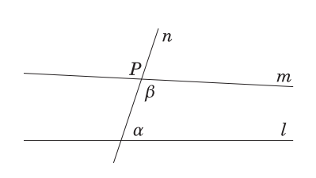

**图 5** 不平行的直线。

**Figure 5** Non-parallel lines.

由此可以推出（并不十分显然）：过给定直线 $l$ 外的一个给定点 $P$，恰好有一条直线与 $l$ 平行，即满足 $α+β=π$ 的直线 $m$。

It follows (not quite obviously) that there is exactly one parallel to a given line $l$ through a given point $P$ outside $l$, namely the line $m$ for which $α+β=π$.

平行公理的复杂性质激起了许多尝试，试图通过证明它可由欧几里得的其他公理推出而将其消除。但所有这类尝试都失败了。这在十九世纪导致了对公理化方法的彻底审视，以及随后对其范围与局限的分析。我们稍后再接着讲这个故事。

The complicated character of the parallel axiom provoked many attempts to eliminate it by showing that it follows from Euclid’s other axioms. But all such attempts failed. This led, in the nineteenth century, to a thorough examination of the axiomatic method and to subsequent analysis of its scope and limits. We pick up this story later.

## 1.5 哲学问题

## 1.5 Philosophical Issues

相传毕达哥拉斯学派最早提出了一种数学哲学，实际上是一种非常简单的“万有理论”：*万物皆数*。据说他们观察到整数在音乐和谐中的作用，并由此一跃得出结论：整个宇宙都由整数及其比所支配。这种哲学的回声至今仍可在“天体的和谐”之类的说法中听到。

According to legend, the Pythagoreans were the first to propose a philosophy of mathematics, in fact a very simple ‘theory of everything’: *all is number*. It is said that they observed the role of whole numbers in musical harmony and jumped from there to the conclusion that the whole universe is ruled by whole numbers and their ratios. The echoes of this philosophy are still heard in phrases like ‘the harmony of the spheres’.

无论其细节如何，毕达哥拉斯学派的哲学被 $2$ 这类无理量的发现所打破。无理量作为数是不可接受的，但在几何中却是不可避免的，因为没有人能否认：如果正方形存在，那么它的对角线也存在。这导致了《几何原本》中所见的数论与几何的分离，也导致了《几何原本》第五卷中的那套理论。第五卷中的“比例论”在（有理）数与几何量之间建立了一个接触点，尽管并没有完全调和二者。

Whatever its details may have been, the Pythagorean philosophy was disrupted by the discovery of irrational quantities such as $2$. Irrationals were unacceptable as numbers, but unavoidable in geometry, since no one could deny that if a square exists, then so does its diagonal. This led to the separation of number theory and geometry seen in Euclid’s *Elements* but also to the theory found in the *Elements* Book V. The ‘theory of proportions’ found in Book V establishes a point of contact between (rational) numbers and geometric quantities, though without fully reconciling the two.

此后数学及其哲学的大部分历史，都源于调和数与量、离散与连续、或理性（逻辑）与视觉（直觉）这些概念的努力。正如我们将在后面各节看到的，数学哲学的发展一直伴随着这一努力。

Much of the subsequent history of mathematics, and its philosophy, grows from the struggle to reconcile the concepts of number and quantity, or the discrete and the continuous, or the rational (logical) and the visual (intuitive). The development of mathematical philosophy accompanies this struggle, as we will see in the sections that follow.

在每一节的末尾，我都会以“直觉与逻辑”“意义与存在”“离散与连续”为标题，对哲学的发展作一个可以说是历史性的更新。作为数学家，我更喜欢用这些术语来思考，但我希望哲学家们能把我所说的哲学内容转译成他们自己偏爱的术语。

At the end of each section I will give a historical update, as it were, of philosophical developments, under the headings of logic and intuition, meaning and existence, and discrete and continuous. As a mathematician, I prefer to think in these terms, but I hope that philosophers will be able to translate the philosophical content of my remarks into their own preferred terms.

**直觉与逻辑。**欧几里得的《几何原本》大概是为了精确地处理几何量，成为已知最早的以公理化方法求真理的范例：定理由公理经逻辑推出。然而，他的公理并不完备，书中频频诉诸直觉，甚至第一个命题中就有一次。因此，《几何原本》无意中说明了在数学推理中避免不自觉的假设是多么困难。

**Intuition and logic.** Probably in an attempt to work precisely with geometric quantities, Euclid’s *Elements* is the first known example of the axiomatic approach to truth, whereby theorems are deduced from axioms by logic. However, his axioms are incomplete, and there are frequent appeals to intuition, one even in his first proposition. Thus the *Elements* unintentionally illustrates how hard it is to avoid unconscious assumptions in mathematical reasoning.

**意义与存在。**欧几里得还试图定义“点”和“线”之类的原始概念，从而削弱了我们今天所理解的公理化方法。他还基本上把“数”的概念限制在自然数及其比上。$2$ 的无理性被认为使它没有资格成为一个数，但欧几里得并没有规定数应当具有哪些性质。

**Meaning and existence.** Euclid also undercuts what we now consider to be the axiomatic method by attempting to define primitive concepts such as ‘point’ and ‘line’. He also restricts the concept of ‘number’ essentially to the natural numbers and their ratios. The irrationality of $2$ is thought to disqualify it from being a number, but Euclid did not prescribe what the properties of numbers should be.

**离散与连续。**由于对无理量的敏感，《几何原本》一般把数与量的概念、或离散与连续的概念清楚地分开。但正如我们稍后将看到的，第五卷开启了二者融合的一种可能。

**Discrete and continuous.** Because of its sensitivity to irrational quantities, the *Elements* generally makes a clear separation between the concepts of number and quantity, or between the discrete and the continuous. But Book V begins a possible merger between the two, as we will see later.

这说明了数学与哲学有时相反的倾向。数学家一般持有庞加莱在 1908 年所表达的看法：

This illustrates the sometimes opposing tendencies of mathematics and philosophy. Mathematicians generally have the outlook expressed by Poincaré in 1908:

> 我想我已经在某处说过，数学是给不同的事物以相同名称的艺术。只要这些事物质料不同而形式相似，就足以让它们可以说是用同一个模子浇铸出来。当语言选择得当时，人们会惊讶地发现，对一个已知对象所作的一切证明，都立即适用于许多新的对象：什么都不需要改变，甚至连术语也不用改，因为名称已经变得相同了。（见 Poincaré 1952，第 34 页）

> I think I have already said somewhere that mathematics is the art of giving the same name to different things. It is enough that these things, though differing in matter, should be similar in form, to permit of their being, so to speak, run in the same mould. When language has been well chosen, one is astonished to find that all demonstrations made for a known object apply immediately to many new objects: nothing requires to be changed, not even the terms, since the names have become the same. (see Poincaré 1952, 34)

换言之，如果事物具有相同的行为，数学家就认为它们是相同的。然而，哲学家喜欢作出区分：他们寻找事物*不应*被视为相同的理由。有时某种区分似乎是有道理的，例如希腊人对数与长度等几何量的区分。但数学总是在可能的地方力图抹去区分。实数概念的漫长演变，可以看作一项抹去数与量之间区分的工程，并随之抹去实数理论与几何之间的区分。

In other words, mathematicians consider things to be the same if they have the same behaviour. Philosophers, however, like to make distinctions: they look for reasons why things should *not* be considered the same. Sometimes a distinction seems to be justified, as was the Greek distinction between numbers and geometric quantities such as length. But mathematics seeks to erase distinctions where possible. The long evolution of the real number concept can be viewed as a project to erase the distinction between number and quantity and, with it, the distinction between real number theory and geometry.

# 2 希腊数学中的无穷

# 2 Infinity in Greek Mathematics

### 预览

### PREVIEW

尽管在《几何原本》中数与长度大多被分开处理，但有一个过程欧几里得同时用于二者——欧几里得算法，它对一对量进行“反复以大减小”的操作。当应用于一对正整数（或更一般地，单位长度的一对正整数倍）时，该算法会终止，因为正整数不可能无限递减。但当应用于一对比值为无理数的长度时，该算法不会终止。事实上，欧几里得正是把其算法的不终止用作无理性的判据，从而把无穷带入了对无理性的讨论。

Although number and length are mostly kept separate in the *Elements*, there is one process that Euclid applied to both – the Euclidean algorithm, which operates on a pair by ‘repeatedly subtracting the smaller from the larger’. When applied to a pair of positive integer numbers (or more generally, to a pair of positive integer multiples of a unit length) the algorithm terminates because positive integers cannot decrease forever. But when applied to a pair of lengths in irrational ratio, the algorithm does not terminate. Indeed, Euclid used non-termination of his algorithm as a criterion for irrationality, thus bringing infinity into the discussion of irrationality.

欧几里得用来证明勾股定理的那套不依赖数的面积理论，对多边形的面积相当顺利。但类似的方法用于体积时，即使对四面体这样简单的多面体也会失效。欧几里得通过把四面体分解为无穷多个棱柱，求出了它的体积，从而把无穷带入了体积理论。

The number-free theory of area, used by Euclid to prove the Pythagorean theorem, works quite smoothly for areas of polygons. But a similar approach to volume fails for even simple polyhedra, such as the tetrahedron. Euclid was able to find the volume of the tetrahedron by decomposing it into infinitely many prisms, thus bringing infinity into the theory of volume.

希腊的面积理论在处理曲边区域时也有困难，因为曲边区域显然不能分解为有限多个多边形。然而，阿基米德通过把抛物线弓形分解为无穷多个三角形，求出了它的面积。尽管如此，希腊人仍力图“回避无穷”，用任意的有限和来代替无穷和。

The Greek theory of area also had difficulty with curved regions, which obviously cannot be decomposed into finitely many polygons. However, Archimedes was able to find the area of a parabolic segment by decomposing it into infinitely many triangles. Nevertheless, the Greeks sought to ‘avoid infinity’ by considering arbitrary finite sums instead of infinite sums.

## 2.1 无理性与不终止

## 2.1 Irrationality and Non-termination

欧几里得算法在《几何原本》第七卷中被引入，作为求两个正整数最大公因数的方法。如欧几里得所说，人们“不断地以大减小”；更确切地说，若 $a>b$，就把数对 $a,b$ 替换为 $a−b,b$。由于正整数不可能无限递减，该算法总会终止。例如，对数对 13, 8，可得

The Euclidean algorithm is introduced in Book VII of the *Elements*, as a method for finding the greatest common divisor of two positive integers. As Euclid says, one ‘continually subtracts the less from the greater’; more precisely, if $a>b$, one replaces the pair $a,b$ by $a−b,b$. Since positive integers cannot decrease forever, the algorithm always terminates. For example, with the pair 13, 8, one gets

$$13,8→5,8→5,3→2,3→2,1→1,1.$$

当得到一对相同的数时，这个数就是 $gcd(a,b)$，因为该数对的所有公因数在减法中都得以保持。因此，我们的例子表明 $gcd(13,8)=1$。

When a pair of identical numbers is obtained, that number is $gcd(a,b)$, because all common divisors of the pair are preserved by subtraction. Thus our example shows that $gcd(13,8)=1$.

在《几何原本》第十卷中，欧几里得把这一算法推广到长度 $a$ 和 $b$，此时它可能不终止。例如，（用现代记号）若长度为 $a=2$ 和 $b=1$，则前两步为

In Book X of the *Elements* Euclid generalizes the algorithm to lengths $a$ and $b$, in which case it may not terminate. For example, if (using modern notation) the lengths are $a=2$ and $b=1$, then the first two steps are

$$2,1→1,2−1→2−2,2−1.$$

此时可以注意到，$2−2$ 与 $2−1$ 之比等于 $2$ 与 1 之比。不清楚希腊人是否注意到了这一点（尽管他们大概知道某种类似的事实），但由初等代数这是显然的，因为

At this point it may be noticed that $2−2$ and $2−1$ are in the same ratio as $2$ and 1. It is not clear whether the Greeks noticed this (though they were probably aware of something similar), but it is clear by basic algebra because

$$2−2=2(2−1).$$

既然 $2−2$ 与 $2−1$ 之比等于 $2$ 与 1 之比，对它们应用欧几里得算法，两步之后又会得到另一对同样比值的数——如此下去，永无止境。

Since $2−2$ and $2−1$ are in the same ratio as $2$ and 1, applying the Euclidean algorithm to them will produce, in two steps, yet another pair in that ratio – and so on, forever.

无论欧几里得是否知道这个特定的例子，他都认识到：对比值为无理数的一对长度，该算法不会终止（第十卷，命题 2）。因此，欧几里得算法通过区分终止与不终止——也就是区分有限与无穷——优雅地把有理与无理区分开来。

Whether or not Euclid knew this particular example, he realized that the algorithm does not terminate on a pair of lengths in irrational ratio (Book X, Proposition 2). Thus the Euclidean algorithm elegantly separates rational from irrational, by separating termination from non-termination; that is, finite from infinite.

## 2.2 面积与体积

## 2.2 Areas and Volumes

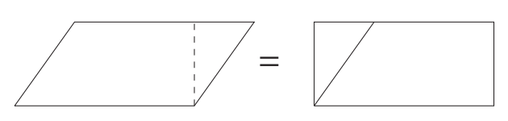

**图 6** 平行四边形与矩形相等。

**Figure 6** Equality of parallelogram and rectangle.

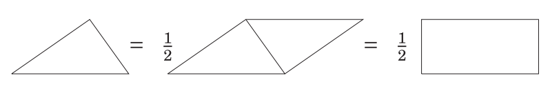

**图 7** 三角形与半个矩形相等。

**Figure 7** Equality of triangle and half rectangle.

在《几何原本》第一卷中，欧几里得通过加上或减去相等的三角形来证明各种区域相等。例如，图 6 表明平行四边形等于同底等高的矩形。图 7 则表明三角形等于同底等高的矩形的一半。

In Book I of the *Elements* Euclid shows equality of various regions by adding or subtracting equal triangles. For example, Figure 6 shows that a parallelogram equals a rectangle of the same base and height. And Figure 7 shows that a triangle equals half a rectangle with the same base and height.

还有一些分解表明：任何矩形都等于一个具有给定底边的矩形。利用这一事实，通过把多边形切割成有限多个三角形，就可以找到一个与任意多边形相等的矩形。现在，如果（像三角形的情形那样）一个区域 $R$ 等于某个可取作单位的标准区域的有理倍数 $r$，那么按照欧几里得的思路，可以让数 $r$ 来“度量”区域 $R$，正如我们度量 $R$ 的面积一样。在这些条件下，从现在起我们将谈论数值化的“面积”与“体积”。

There are also decompositions showing that any rectangle equals a rectangle with a given base. Using this fact, it is possible to find a rectangle equal to any polygon, by cutting the polygon into finitely many triangles. Now if (as in the case of the triangle) one region $R$ equals a rational multiple $r$ of some standard region we can take as a unit, then it is compatible with Euclid to let the number $r$ ‘measure’ the region $R$ in the same way that we measure the area of $R$. Under these conditions we will speak of numerical ‘areas’ and ‘volumes’ from now on.

而曲边区域显然不能切割成有限多个三角形。我们所能期望的最好结果，是把它分解为无穷多个三角形，而如果运气好的话，这种分解或许是可以理解的。阿基米德用这种方法取得了辉煌的成功，求出了抛物线弓形的面积。

Now a curved region obviously cannot be cut into finitely many triangles. The best we can hope for is a decomposition into infinitely many triangles which, if we are lucky, might be comprehensible. Archimedes had a brilliant success by this method, finding the area of a parabolic segment.

抛物线弓形按图 8 所示的方式用三角形填满：先是黑色三角形，然后是它下方的两个深灰色三角形，再是它们下方的四个浅灰色三角形，依此类推。

The parabolic segment is filled with triangles in the manner shown in Figure 8: first the black triangle, then two dark grey triangles below it, then four lighter grey triangles below them, and so on.

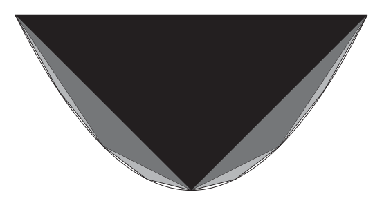

**图 8** 用三角形填满抛物线弓形。

**Figure 8** Filling the parabolic segment with triangles.

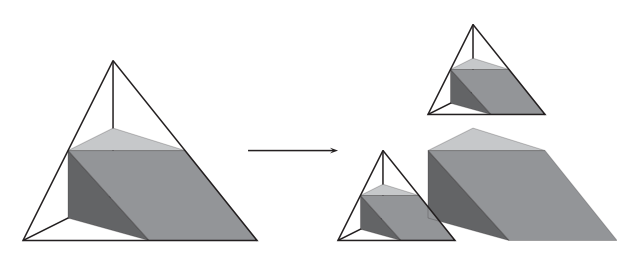

**图 9** 用棱柱填满四面体。

**Figure 9** Filling the tetrahedron with prisms.

每个三角形的宽度是其上方三角形的一半，计算表明，每一组（一个、两个、四个……三角形）的总面积是其上一组面积的四分之一。因此，如果黑色三角形的面积为 1，那么这些三角形的总面积就是无穷和

Each triangle is half the width of the triangle above it, and a calculation shows that each group (of one, two, four, … triangles) has total area one-fourth the area of the group above it. Thus, if the black triangle has area 1, then the total area of the triangles is the infinite sum

$$1+14+(14)2+(14)3+(14)4+⋯.$$

如果我们令

If we set

$$S=1+14+(14)2+(14)3+(14)4+⋯,$$

那么显然有

then clearly

$$4S=4+1+14+(14)2+(14)3+(14)4+⋯,$$

因此 $4S−S=4$，从而 $S=4/3$。（这种对无穷和的冒险计算提供了一种猜出答案的快捷方法。我们将在下一节看到阿基米德是如何更审慎地处理它的。）

so $4S−S=4$ and therefore $S=4/3$. (This risky calculation with infinite sums gives a quick way to guess the answer. We will see how Archimedes did it more carefully in the next section.)

四面体则用棱柱来填充，如图 9 所示。取出两个棱柱（一个浅灰色，另一个深灰色）之后，剩下两个较小的四面体，我们再从中取出棱柱，并继续下去。

The tetrahedron is filled with prisms, as indicated in Figure 9. After two prisms are removed (one light grey, the other darker grey), two smaller tetrahedra remain, from which we again remove prisms, and continue.

欧几里得用这种方法求得四面体的体积是一个类似的无穷和，

In this way Euclid found that the volume of the tetrahedron is a similar infinite sum,

$$14+(14)2+(14)3+(14)4+⋯,$$

它等于 1/3。

which equals 1/3.

## 2.3 穷竭法

## 2.3 The Method of Exhaustion

前两节展示了希腊数学中无穷过程的例子。上一节中的例子之所以引人注目，是因为它们求出了一个看来无法通过有限过程得到的有理面积或体积。尽管如此，希腊人对无穷心存疑虑，并尽可能地回避它。在许多情况下，他们能够借助所谓的*穷竭法*做到这一点。

The last two sections have shown examples of infinite processes in Greek mathematics. Those in the previous section are notable for finding a rational area or volume apparently not obtainable by finite processes. Nevertheless, the Greeks were suspicious of infinity and they tried to avoid it as far as possible. In many cases they were able to do so by what is called the *method of exhaustion*.

这种方法之所以得名，是因为人们通过穷尽所有其他可能性（小于 $x$ 或大于 $x$）来确认由无穷过程得到的结果 $x$。通常，其他可能性是通过假设该过程运行任意但有限的步数来穷尽的。我们可以用阿基米德求抛物线弓形面积的例子来说明穷竭法，把其中的无穷过程替换为任意的有限过程。这个例子所涉及的无穷过程如下：

The method is so called because one confirms a result $x$, obtained by an infinite process, by exhausting all other possibilities (less than $x$ or greater than $x$). Typically, the other possibilities are exhausted by supposing the process to run for an arbitrary, but finite, number of steps. We can illustrate the method of exhaustion in the case of Archimedes’ evaluation of the area of a parabolic segment, replacing the infinite processes by arbitrary finite ones. The infinite processes involved in this example are as follows:

1. 用无穷多个三角形填满抛物线弓形。我们可以通过证明抛物线内的任一给定点都落在某个三角形之内，来论证这些三角形确实填满了（或“穷竭”了）弓形。这是一个纯粹有限的论证，尽管有些繁琐。
2. 证明无穷级数 $1+14+(14)2+(14)3+(14)4+⋯$ 的和为 $4/3$。
1. Filling the parabolic segment with infinitely many triangles. We can argue that the triangles do fill the segment (or ‘exhaust’ it) by showing that any given point inside the parabola falls inside some triangle. This is a purely finite, if tedious, argument.
2. Showing that the infinite series $1+14+(14)2+(14)3+(14)4+⋯$ has sum $4/3$.

这可以通过求出如下有限和来完成：

This can be done by finding the finite sum

$$Sn=1+14+(14)2+⋯+(14)n=43−13(14)n.$$

我们看到，取任意大的 $n$ 值，$Sn$ 就“穷竭”了所有小于 $4/3$ 的数，因为此时 $(14)n$ 变得任意小。而 $Sn$ 显然不能大于 $4/3$，因此剩下的值 4/3 必然就是该无穷级数的和。

We see that $Sn$ ‘exhausts’ all numbers $<4/3$ by taking arbitrarily large values of $n$, because $(14)n$ then becomes arbitrarily small. And obviously $Sn$ cannot be $>4/3$, so the value that remains, 4/3, is necessarily the sum of the infinite series.

因此，抛物线弓形的面积（类似地，四面体的体积）可以用任意的有限和而非无穷和求出。这是希腊人回避实际使用无穷的典型方式。我们将在下一节看到类似的“对无穷的回避”。

Thus the area of the parabolic segment (and similarly the volume of the tetrahedron) can be found by using arbitrary finite sums instead of infinite sums. This is typical of the way the Greeks avoided actual use of infinity. We will see a similar ‘avoidance of infinity’ in the next section.

## 2.4 比例论

## 2.4 The Theory of Proportions

《几何原本》读者的一个常见绊脚石是第五卷，即所谓的比例论。这一理论被认为出自欧多克索斯，涉及长度概念及其与数的概念的关系。它的主要困难，基本上就是我们今天试图理解实数轴时所遇到的困难。还有一个较小的困难，源于希腊人习惯于处理（整数或长度的）比，这使他们无法使用有理数和单位长度。但为了集中讨论主要困难——当然就是无理量的存在——我将略过这一点，而直接承认有理数和单位长度。

A common stumbling block for readers of the *Elements* was Book V, on the so-called theory of proportions. This theory, thought to be due to Eudoxus, is about the concept of length and its relation to the concept of number. Its main difficulty is basically the difficulty we meet today in trying to understand the real number line. There is a lesser difficulty due to the Greek habit of working with ratios (of integers or lengths), which stopped them from working with rational numbers and a unit length. But I will gloss over this in order to concentrate on the main difficulty – which is of course the existence of irrationals – by admitting rational numbers and a unit of length.

一旦承认有理数，就会清楚地看出它们是比例论的关键要素。给定单位长度 1，对任意正整数 $m,n$，我们也就有了有理长度 $l=m/n$。它是这样一个长度：$l$ 的 $n$ 个副本等于 1 的 $m$ 个副本。对任意长度 $a$ 和 $b$，这些有理长度决定了 $a<b$、$a=b$ 还是 $a>b$。即：

When rational numbers are admitted it becomes clear that they are the key ingredient in the theory of proportions. Given a unit length 1, we also have a rational length $l=m/n$ for any positive integers $m,n$. It is the length such that $n$ copies of $l$ equal $m$ copies of 1. These rational lengths determine, for any lengths $a$ and $b$, whether $a<b$, $a=b$, or $a>b$. Namely

$$a<b⇔存在有理数 m/n 使得 / there is a rational m/n with a<m/n<ba>b⇔存在有理数 m/n 使得 / there is a rational m/n with a>m/n>ba=b⇔既非 a<b 亦非 a>b / neither a<b nor a>b.$$

因此，若 $a<b$ 或 $a>b$，就有一对 $m,n$ 可以“见证”这一事实：或者因为 $a<m/n<b$，或者因为 $a>m/n>b$。但若 $a=b$，就没有单独一个有理数 $m/n$ 能见证这一事实（除非 $a$ 和 $b$ 是有理的）：只有当所有小于 $a$ 的有理数都小于 $b$，并且反之亦然时，$a$ 才等于 $b$。因此，相等比不等更难以把握，无理长度也比有理长度更难以把握。

Thus if $a<b$ or $a>b$, there is a pair $m,n$ that ‘witnesses’ the fact: either because $a<m/n<b$ or $a>m/n>b$. But if $a=b$, there is no single rational number $m/n$ that witnesses this fact (unless $a$ and $b$ are rational): $a$ equals $b$ only if all rational numbers less than $a$ are less than $b$, and conversely. Thus equality is more elusive than inequality, and irrational lengths are more elusive than rational lengths.

由于对无穷的疑虑，希腊人没有迈出这样一步：宣称一个无理长度由它两侧的有理长度所确定，因为这种确定涉及无穷多个有理长度。在第 6 节中，我们将看到十九世纪迈出这一步时发生了什么。

Because of their suspicion of infinity, the Greeks did not take the step of saying that an irrational length is determined by the rational lengths on either side of it, since this determination involves infinitely many rational lengths. In Section 6 we will see what happened when this step was taken, in the nineteenth century.

即使是不等的检验，也引出了一个有趣的哲学要点。假设 $0<b$，从而对某些正整数 $m$ 和 $n$ 有 $0<m/n<b$。两边同乘以 $n$，得 $0<m<nb$。因此，比例论假定了后来所谓的*阿基米德公理*，即*无穷小不存在*：若 $b>0$，则某个整数倍 $nb>1$。这在十七世纪成了一个热门问题，当时数学家们发现假定无穷小存在很方便；也就是说，他们设想存在 $b>0$，使得没有任何整数倍 $nb>1$（见第 4.3 节）。

Even the test for inequality raises an interesting philosophical point. Suppose that $0<b$ and hence that $0<m/n<b$ for some positive integers $m$ and $n$. It follows, multiplying by $n$, that $0<m<nb$. Thus the theory of proportions assumes what would later be called the *Archimedean axiom* or *non-existence of infinitesimals*: if $b>0$ then some integer multiple $nb>1$. This became a hot issue in the seventeenth century, when mathematicians found it convenient to assume the existence of infinitesimals; that is, they supposed there were $b>0$ such that no integer multiple $nb>1$ (see Section 4.3).

## 2.5 阿基米德与实无穷

## 2.5 Archimedes and Actual Infinity

与穷竭法一样，比例论也通过转而处理“任意有限”的东西来回避无穷。特别地，它用任意的有限整数 $m,n$ 来见证 $a<b$，因为 $a<m/n<b$。事实上，当要证明 $a=b$ 时，用的就是穷竭法；即证明对任何可能的数对 $m,n$，$a<m/n<b$ 和 $a>m/n>b$ 都不成立。

Like the method of exhaustion, the theory of proportions avoids infinity by dealing instead with the ‘arbitrary finite’. In particular, it employs the arbitrary finite integers $m,n$ to witness that $a<b$ because $a<m/n<b$. Indeed, when $a=b$ is proved it is done by exhaustion; namely, by showing that $a<m/n<b$ and $a>m/n>b$ fail for any possible pair $m,n$.

能以这种方式被有限部分“穷竭”的无穷，希腊人称之为“潜无穷”，而在数学论证中只允许使用潜无穷。穷竭法的目的就是回避*实*无穷；也就是说，回避把一个无穷的集合或过程看作一个完成了的整体。

An infinity that can be ‘exhausted’ in this way by finite parts was called a ‘potential infinity’ by the Greeks, and only potential infinities were allowed in mathematical argument. The aim of the method of exhaustion was to avoid *actual* infinity; that is, viewing an infinite collection or process as a completed whole.

在欧几里得之后的两千多年里，数学家的官方做法是只接受潜无穷，并借助穷竭法来回避实无穷。这是理论上的做法，但在实践中，实无穷常被用作获得结果的捷径，（人们希望）这些结果以后可以用穷竭法严格证明。

For over 2000 years after Euclid the official practice of mathematicians was to accept only potential infinities, and to avoid actual infinities by appealing to the method of exhaustion. This was the theory, but in practice actual infinities were often used as a shortcut to results that (hopefully) could later be proved rigorously by the method of exhaustion.

就我们所知，最早使用实无穷的是阿基米德，见于他名为《方法》的著作。这部著作失传湮没了好几个世纪，直到 1906 年才被重新发现，因此它对数学及其哲学的发展没有产生影响。然而，它确实表明，希腊人关于无穷的思考比人们从欧几里得那里得到的印象要丰富。阿基米德远远超越了认为一系列离散步骤可以完成的想法；他甚至愿意把直线上点的连续统看作一个完成了的集合（尽管他大概没有意识到连续统是一种新的无穷）。

As far as we know, the first to use actual infinities was Archimedes, in a work called *The Method*. This work was lost and unknown for centuries before being rediscovered in 1906, so it did not influence the development of mathematics or its philosophy. However, it does show that there was more to Greek thinking about infinity than one would gather from Euclid. Archimedes went far beyond thinking that a sequence of discrete steps could be completed; he was even willing to view the continuum of points on the line as a completed collection (though probably without realizing that the continuum is a new kind of infinity).

## 2.6 哲学问题

## 2.6 Philosophical Issues

欧几里得洞悉了有理与无理之区分的核心：那就是有限与无穷之间的差别。因此，接受无理量的几何，也必须以某种形式接受无穷。于是，几何的逻辑必须找到一种对无穷进行推理的方式。

Euclid penetrated to the heart of the distinction between rational and irrational: it is the difference between finite and infinite. Thus geometry, which accepts irrational quantities, must also accept infinity in some form. So the logic of geometry had to find a way of reasoning about infinity.

**直觉与逻辑。**希腊人尽可能地避免对无穷进行推理。他们对无穷的恐惧从何而来并不完全清楚，不过芝诺悖论表明这种恐惧在欧几里得之前就已存在，而亚里士多德曾试图揭穿它。穷竭法是数学对这些哲学争论的回应：通过对无穷过程的有限（但任意）阶段进行推理来避免对无穷本身进行推理，并论证这些阶段“穷尽了所有可能性”，只剩下一种——因此这种可能性可以被视为该无穷过程的结果。

**Intuition and logic.** The Greeks tried as far as possible to avoid reasoning about infinity. The origin of their fear of infinity is not completely clear, though Zeno’s paradoxes show that the fear was present before Euclid’s time, and that Aristotle tried to debunk it. The method of exhaustion was the mathematical response to these philosophical debates: avoid reasoning about infinity by reasoning about finite (but arbitrary) stages of an infinite process, and argue that they ‘exhaust all possibilities’ except one – which possibility can therefore be deemed the result of the infinite process.

**意义与存在。**因此，穷竭法间接地赋予了无穷过程的结果以意义，而无须承诺实无穷的存在。

**Meaning and existence.** Thus the method of exhaustion indirectly gives meaning to the result of an infinite process, without commitment to the existence of actual infinity.

**连续与离散。**具有无穷多个离散步骤的过程可以作为“潜无穷”被接受。但由于拒斥实无穷，希腊人一般远离“连续的无穷”这一观念。阿基米德也许是个例外，因为他似乎愿意把直线上点的连续统看作一个完成了的整体。

**Continuous and discrete.** Processes with an infinite number of discrete steps could be accepted as ‘potential infinity’. But, in rejecting actual infinity, the Greeks generally stayed well away from the idea of a ‘continuous infinity’. Perhaps Archimedes was an exception, because he seemed willing to accept the continuum of points on the line as a completed whole.

如第 1.5 节所述，哲学的倾向是作出区分，而数学的倾向是在可能之处抹去区分。然而，数学有时会发现哲学（以及以往的数学）未曾预见的区分。无穷就是一个恰当的例子。几千年来，数学接受潜无穷与实无穷的区分，并追随哲学，认为实无穷不可接受。但自十九世纪末以来，实无穷不仅（对大多数数学家而言）变得可以接受，而且还出现了意想不到的、复杂的区分。这引发了关于可接受与不可接受的无穷之间界线应划在何处的新争论。我们将在第 7 节看到这是如何发生的。

As mentioned in Section 1.5, the tendency of philosophy is to make distinctions, while that of mathematics is to erase them where possible. However, mathematics sometimes discovers distinctions that philosophy (and previous mathematics) had not foreseen. Infinity is a case in point. For millennia, mathematics accepted the distinction between potential and actual infinity and, following philosophy, considered actual infinity unacceptable. But since the late nineteenth century, actual infinity has not only become acceptable (to most mathematicians) but also subject to unforeseen and complicated distinctions. This has led to new controversies about where to draw the line between acceptable and unacceptable infinity. We will see how this happened in Section 7.

# 3 虚数

# 3 Imaginary Numbers

### 预览

### PREVIEW

几个世纪以来，把 $2$ 这样的量当作数的阻力逐渐消退，这或许是因为代数在印度和伊斯兰世界的兴起。在印度，婆罗摩笈多约于公元 600 年给出了二次方程 $ax2+bx+c=0$ 的本质上现代的解

Resistance to treating quantities such as $2$ as numbers gradually eroded over the centuries, possibly because of the rise of algebra in India and the Islamic world. In India, Brahmagupta around 600 CE gave essentially the modern solution

$$x=−b±b2−4ac2a$$

人们逐渐接受：正数的平方根本身也是一个数。与此同时，人们不愿使用负数（尽管婆罗摩笈多接受负数），而负数的平方根似乎毫无意义。因此，当 $b2−4ac<0$ 时，说 $ax2+bx+c=0$ 无解似乎是很自然的。

of the quadratic equation $ax2+bx+c=0$, and it became accepted that the square root of a positive number was itself a number. At the same time, there was reluctance to use negative numbers (though Brahmagupta accepted them), and the square root of a negative number seemed nonsensical. Thus when $b2−4ac<0$ it seemed natural to say that $ax2+bx+c=0$ had no solution.

十六世纪，意大利数学家发现了三次方程 $x3=px+q$ 的解，其形式为

Things changed in the sixteenth century when Italian mathematicians discovered the solution of the cubic equation $x3=px+q$ in the form

$$x=q2+(q2)2−(p3)33+q2−(q2)2−(p3)33.$$

情况由此改变。这个公式不仅要求接受平方根和立方根，还要求接受负数的平方根——因为有些方程明明有一个显而易见的实数解，却有 $(q2)2−(p3)3<0$。在很长一段时间里，$−1$ 这样的数被称为“不可能的”，至今仍被称为“虚的”。然而它们在数学中被接受了，至少被用来证明关于实数的结果，因为它们有用，而且（通常）不会导致矛盾。最终，实数与虚数构成的体系在代数上和几何上都被视为自然的。

This formula called not only for acceptance of square roots and cube roots, but also for square roots of negative numbers – because there are equations for which there is an obvious real solution yet $(q2)2−(p3)3<0$. For a long time, numbers such as $−1$ were called impossible, and they are still called ‘imaginary’. Yet they were accepted in mathematics, at least to prove results about real numbers, because they were useful and they did not (usually) lead to contradiction. Eventually, the system of real and imaginary numbers came to be viewed as natural, both algebraically and geometrically.

## 3.1 二次方程与三次方程

## 3.1 Quadratic and Cubic Equations

正如我们在第 1 节所见，在希腊数学中，代数受到乘积的几何解释的束缚。在几何解释下，三项以上的乘积没有意义，不同维数的乘积不能相加。这些限制并不适用于数的乘积，因此在数的代数与长度的代数之间的较量中，数的代数显然胜出。代数的发展过程大致就是如此；代数最初是一套用于解决关于数的问题（尤其是方程）的符号体系。

As we have seen in Section 1, algebra was hamstrung in Greek mathematics by the geometric interpretation of product. Under the geometric interpretation, products of more than three terms have no meaning, and products of different dimensions cannot be added. These restrictions do not apply to the product of numbers, so in a contest between algebra for numbers and algebra for lengths, algebra for numbers clearly wins. This is roughly what happened in the development of algebra, which was initially a symbolism for solving problems (especially equations) about numbers.

直到约 1600 年，代数一直是一门求解数的方程的学科，但它要退回到几何中去为自己的步骤提供辩护——因为欧几里得的《几何原本》仍是数学证明的典范。

Until about 1600, algebra was a discipline that solved equations in numbers but it fell back on geometry to justify its moves – because Euclid’s *Elements* was still the model for mathematical proof.

从几何向数的代数的转变始于丢番图，约在公元 200 年，即古典希腊数学的最后阶段。丢番图使用的符号体系允许四个或更多元素的乘积。但由于他感兴趣的是寻找方程的有理解，他只使用有理运算 $+,−,×,÷$，而不使用平方根运算 。 运算出现在二次方程 $ax2+bx+c=0$ 的通解

The shift from geometry to an algebra of numbers began with Diophantus, around 200 CE, in the last phase of classical Greek mathematics. Diophantus used a symbolism that allowed products of four or more elements. But because he was interested in finding rational solutions of equations he used only the rational operations $+,−,×,÷$, not the square root operation . The operation occurs in the general solution

$$x=−b±b2−4ac2a(*)$$

之中。这个解本质上由婆罗摩笈多于约公元 600 年在印度给出，不过用的是文字而非符号。对方程的研究从印度传播到伊斯兰世界，约公元 800 年，花拉子米在那里给它起名为“代数”。由此它又传到意大利，下一个重大进展就发生在那里：三次方程的求解。

of the quadratic equation $ax2+bx+c=0$. Essentially, this solution was given by Brahmagupta in India around 600 CE, though in words rather than symbols. The study of equations spread from India to the Islamic world, where it was given the name ‘algebra’ by al-Khwarizmi around 800 CE. From there it passed to Italy, where the next major advance occurred: the solution of cubic equations.

$x3=px+q$ 的解约于 1500 年由希皮奥内·德尔·费罗发现，但被当作当时流行的数学竞赛中的“秘密武器”而秘而不宣。塔尔塔利亚在 1530 年代重新发现了它，它首次发表于卡尔达诺的《大术》（1545）。这个所谓的卡尔达诺求解公式是

The solution of $x3=px+q$ was discovered by Scipione del Ferro around 1500 but was kept as a ‘secret weapon’ for the mathematical contests that were then popular. It was rediscovered by Tartaglia in the 1530s and first published in the *Ars Magna* of Cardano (1545). The so-called Cardano formula for the solution is

$$x=q2+(q2)2−(p3)33+q2−(q2)2−(p3)33(**)$$

这时的数学家已经愿意接受正数的平方根和立方根，但对负数的平方根却裹足不前。当然，当 $b2<4ac$ 时，负数的平方根已经出现在二次公式 (*) 中。但在这种情况下，人们可以随意地说方程 $ax2+bx+c=0$ 无解。三次方程的解 (**) 则不然。

Mathematicians by this time were willing to accept square and cube roots of positive numbers, but they balked at square roots of negative numbers. Of course square roots of negative numbers already occur in the quadratic formula (*) when $b2<4ac$. But in this case one is free to say that the equation $ax2+bx+c=0$ has no solution. It was otherwise with the solution (**) of the cubic equation.

## 3.2 邦贝利的虚数代数

## 3.2 Bombelli’s Algebra of Imaginary Numbers

即使卡尔达诺公式中含有负数 $(q2)2−(p3)3$ 的平方根，方程 $x3=px+q$ 也可能有一个显而易见的解。例如 $x3=15x+4$ 就是如此，它有显而易见的解 $x=4$。对这个方程，卡尔达诺公式给出（经过一些化简后）

The equation $x3=px+q$ can have an obvious solution, even though the Cardano formula contains the square root of a negative number $(q2)2−(p3)3$. This is the case, for example, for $x3=15x+4$, which has the obvious solution $x=4$. For this equation the Cardano formula gives (after some simplification)

$$x=2+11−13+2−11−13.$$

为了让这个表达式与 $x=4$ 这个值相符，邦贝利（1572）假定 $−1$ 服从与普通数相同的代数规则。他对自己的计算秘而不宣，但它很容易重构。用现代记号 $i$ 表示 $−1$，于是 $i2=−1$，可以验证

To reconcile this expression with the value $x=4$, Bombelli (1572) assumed that $−1$ obeys the same algebraic rules as ordinary numbers. He kept his calculation a secret, but it is easy to reconstruct. Using the modern notation $i$ for $−1$, so $i2=−1$, one can check that

$$(2+i)3=2+11iand / 以及(2−i)3=2−11i;$$

因此

and therefore

$$2+11−13+2−11−13=2+11i3+2−11i3=(2+i)33+(2−i)33=(2+i)+(2−i)=4.$$

正如许多人后来所说的那样，代数似乎比我们更聪明！

As many people have since remarked, it seems as though algebra is smarter than we are!

无论如何，邦贝利的例子以及其他类似的例子，最终使数学家们相信，使用“虚”数或“不可能的”数是安全的。无论 $−1$ 意味着什么（如果它有意义的话），它的行为似乎都像一个普通的数，并且能给出关于普通数的正确结果。

At any rate, Bombelli’s example, and others like it, eventually convinced mathematicians that it was safe to use ‘imaginary’ or ‘impossible’ numbers. Whatever $−1$ means, if anything, it seems to behave like an ordinary number and to give correct results about ordinary numbers.

## 3.3 虚数的便利

## 3.3 The Convenience of Imaginary Numbers

在十八和十九世纪，数学家们发现，在许多情形下，借助虚数可以更容易地陈述或解释普通数的已知性质。下面是一些例子。

In the eighteenth and nineteenth centuries mathematicians discovered many situations in which known properties of ordinary numbers are more easily stated, or explained, with the help of imaginary numbers. Here are some examples.

1. 三角公式 $cos(θ+φ)=cosθcosφ−sinθsinφsin(θ+φ)=sinθcosφ+cosθsinφ$ 可以更简洁（也更好记）地用一个公式来表达：$cos(θ+φ)+isin(θ+φ)=(cosθ+isinθ)(cosφ+isinφ).$
2. 如果我们假定 $eix=cosx+isinx$（这样做的理由见第 4.5 节），那么后一个公式还可以更简洁地表达为 $ei(θ+φ)=eiθeiφ$。这为正弦和余弦函数赋予了新的意义——它们是虚指数函数的组成部分。
3. 如果 $a,b,c,d$ 是正整数，那么 $a2+b2$ 与 $c2+d2$ 之积本身也是两个整数平方之和。为了找出后者的两个平方，我们利用 $i2=−1$ 构造虚的因式分解（见下式），其中用到恒等式 $x2−y2=(x+y)(x−y)$。把两个因式分解结合起来，并再次利用该恒等式，就得到下面的结果。
1. The trigonometric formulas $cos(θ+φ)=cosθcosφ−sinθsinφsin(θ+φ)=sinθcosφ+cosθsinφ$ are more concisely (and memorably) expressed by the single formula $cos(θ+φ)+isin(θ+φ)=(cosθ+isinθ)(cosφ+isinφ).$
2. The latter formula can be even more concisely expressed by $ei(θ+φ)=eiθeiφ,$ if we assume $eix=cosx+isinx$ (see Section 4.5 for a reason to do this). This gives new meaning to the sine and cosine functions – as parts of the imaginary exponential function.
3. If $a,b,c,d$ are positive integers then the product of $a2+b2$ and $c2+d2$ is itself the sum of two integer squares. To find the latter squares we use $i2=−1$ to create the imaginary factorizations below, using the identity $x2−y2=(x+y)(x−y)$. Combining the factorizations, and again using the identity, we get the result below.

$$a2+b2=a2−(ib)2=(a+ib)(a−ib)c2+d2=c2−(id)2=(c+id)(c−id),$$

$$(a2+b2)(c2+d2)=[(a+ib)(c+id)][(a−ib)(c−id)]=[ac−bd+i(ad+bc)][ac−bd−i(ad+bc)]=(ac−bd)2+(ad+bc)2.$$

这些例子表明，虚数应当被接受，哪怕只是为了方便。然而，我们还可以做得更好。我们可以给虚数一个令人信服的解释，表明它们与普通数同样“实在”（并顺带解释它们在几何和三角学中的作用）。更保守地说，我们可以说明如何把虚数从任何用到它们的论证中消去，代之以普通数。

These examples suggest that imaginary numbers should be accepted, if only for the sake of convenience. However, it is possible to do better than this. We can give a convincing interpretation of imaginary numbers, which shows them to be just as ‘real’ as ordinary numbers (and incidentally explains their role in geometry and trigonometry). More conservatively, one can show how to eliminate imaginary numbers, from any argument that uses them, in favour of ordinary numbers.

## 3.4 实现虚数

## 3.4 Realizing the Imaginary

哈密顿（1835）引入了一种从数学中消去虚数的简单方法：把 $a+ib$ 替换为实数 $a,b$ 的有序对 $(a,b)$，并把数对的和与积定义为

A simple way to eliminate imaginary numbers from mathematics was introduced by Hamilton (1835): replace $a+ib$ by the ordered pair $(a,b)$ of real numbers $a,b$, and define the sum and product of pairs by

$$(a1,b1)+(a2,b2)=(a1+a2,b1+b2)(a1,b1)⋅(a2,b2)=(a1a2−b1b2,a1b2+a2b1).$$

于是，和 $(a1+ib1)+(a2+ib2)$ 所对应的数对，就是 $a1+ib1$ 与 $a2+ib2$ 所对应数对之和；积所对应的数对同样也是这两个数对之积。由此可知，关于 $a+ib$ 形式的数的和与积的任何陈述，都等价于一个关于实数的陈述，例如

Then the pair for the sum $(a1+ib1)+(a2+ib2)$ is the sum of the pairs for $a1+ib1$ and $a2+ib2$, and the pair for the product is likewise the product of the pairs. It follows that any statement about sum and product of numbers of the form $a+ib$ is equivalent to one about real numbers, for example

$$(a1+ib1)(a2+ib2)=c+id⇔a1a2−b1b2=c and / 且 a1b2+a2b1=d.$$

因此，任何涉及 $i$ 的论证都可以替换为只涉及实数的论证。正因如此，我们说复数（$a+ib$ 形式的数即称为复数）理论是实数理论的*保守扩张*。所谓“保守”，是指任何借助 $i$ 证明的关于实数的结果，不借助 $i$ 也能证明。

Hence any argument involving $i$ can be replaced by one involving real numbers alone. Because of this we say that the theory of *complex numbers* (as the numbers $a+ib$ are called) is a *conservative extension* of the theory of real numbers. It is ‘conservative’ in the sense that any result about real numbers proved with use of $i$ can be proved without it.

哈密顿的构造表明，假定虚数存在是无害的，但同时也表明，没有*必要*假定它们存在。凡是我们借助它们能做的事，不借助它们也能做，只是也许没那么容易。

Hamilton’s construction shows that it is harmless to assume that imaginary numbers exist, but at the same time it shows that there is no *need* to assume they exist. Anything we can do with them we can do without them, though perhaps not as easily.

对大多数数学家来说，使人不得不相信复数的，是它们给出的比我们所要求的更多。仿佛它们一直就是数学结构的一部分，只是起初我们只注意到了其中细小的一缕——三次方程的求解。事实上，$i$ 不仅给出三次方程的解，而且给出*所有*多项式方程的解。这就是代数基本定理，我们将在第 5 节进一步讨论。

For most mathematicians, what compels belief in the complex numbers is that they give more than we asked for. It is as though they were always part of the fabric of mathematics, but at first we noticed only one small thread in the solution of cubic equations. In fact, $i$ not only gives solutions to cubic equations but to *all* polynomial equations. This is the *fundamental theorem of algebra* that we will say more about in Section 5.

此外，虽然 $i$ 不可能位于实数直线上，但让它位于一条与之垂直的虚数直线上却是完全合理的。我们只需想象一个复数平面，其中 $a+ib$ 由点 $(a,b)$ 表示，它到原点 $O$ 的水平距离为 $a$，垂直距离为 $b$。在这种解释下，乘以 $a+ib$ 具有一种几何意义，它是 $i2=−1$ 的一个广泛推广。即：乘以 $a+ib$ 把平面放大 $a2+b2$ 倍（$a+ib$ 到 $O$ 的距离），并绕 $O$ 旋转角 $θ=tan−1ba$。图 10 展示了 $a+ib$ 的几何背景。

Moreover, while $i$ cannot lie on the line of real numbers, it makes perfect sense for it to lie on a perpendicular line of imaginary numbers. All we have to do is imagine a plane of complex numbers, with $a+ib$ represented by the point $(a,b)$ at horizontal distance $a$ from the origin $O$, and at vertical distance $b$. Under this interpretation, multiplication by $a+ib$ has a geometric meaning that is a sweeping generalization of $i2=−1$. Namely multiplication by $a+ib$ magnifies the plane by $a2+b2$ (the distance of $a+ib$ from $O$) and rotates it about $O$ through angle $θ=tan−1ba$. Figure 10 shows $a+ib$ in its geometric context.

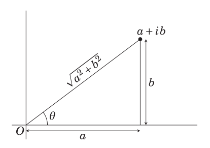

**图 10** 复数的几何。

**Figure 10** The geometry of a complex number.

特别地，乘以 $i$ 使平面绕 $O$ 旋转一个直角，乘以 $cosθ+isinθ$ 使平面旋转角 $θ$。因此，复数的乘法囊括了全部基础几何与三角学。

In particular, multiplication by $i$ rotates the plane about $O$ through a right angle, and multiplication by $cosθ+isinθ$ rotates it through angle $θ$. Thus multiplication of complex numbers encapsulates all of basic geometry and trigonometry.

而这仅仅是开始。如上一节所述，$eiθ=cosθ+isinθ$，因此复数把三角学与指数函数统一了起来。简而言之，复数大概是高等数学中最强大的统一与简化力量。这就是数学家相信它们的原因。

And this is just the beginning. As mentioned in the previous section, $eiθ=cosθ+isinθ;$ so the complex numbers unite trigonometry with the exponential function. In short, the complex numbers are probably the most powerful unifying and simplifying force in higher mathematics. That is why mathematicians believe in them.

## 3.5 哲学问题

## 3.5 Philosophical Issues

代数在印度和伊斯兰世界的兴起，起初并没有影响数学哲学。事实上，直到十六世纪，欧几里得的权威一直统治着代数。伊斯兰代数学家通过诉诸几何图形来为他们的证明辩护，直到卡尔达诺（1545）仍可见到这样的证明。只是到了约十六世纪末，随着现代代数符号的发展，代数计算才成为数学中的一股新力量。

The emergence of algebra in India and the Islamic world did not at first affect the philosophy of mathematics. In fact, Euclid’s authority ruled algebra until the sixteenth century. The Islamic algebraists justified their proofs by appeal to geometric diagrams, and such proofs occur as late as Cardano (1545). It was only around the end of the sixteenth century, when modern algebraic symbolism developed, that algebraic calculation became a new force in mathematics.

符号代数为微积分等其他符号数学分支铺平了道路，数学哲学最终不得不将它们考虑在内。尽管如此，在很长一段时间里，人们仍希望欧几里得可以继续作为数学的基础。

Symbolic algebra paved the way for other branches of symbolic mathematics, such as calculus, which the philosophy of mathematics eventually had to take into account. Nevertheless, for a long time it was hoped that Euclid could remain as the foundation of mathematics.

**直觉与逻辑。**意大利代数学家起初（与他们的伊斯兰前辈一样）通过诉诸几何逻辑来为代数规则辩护。但邦贝利用 $−1$ 进行的计算表明，代数有它自己独立的逻辑。

**Intuition and logic.** The Italian algebraists at first justified the rules of algebra (as did their Islamic predecessors) by appeal to geometric logic. But Bombelli’s calculations with $−1$ suggested that algebra had an independent logic of its own.

**意义与存在。**虚数起初只被赋予“符号上的存在”，允许它们用于得出实际结果的计算。在成为一套操作符号的规则体系的过程中，代数开始摆脱它的几何基础。然而令人惊讶的是，虚数却为几何提供了新的洞见。

**Meaning and existence.** Imaginary numbers at first were accorded merely ‘symbolic existence’, allowing them to be used in calculations that had real results. In becoming a system of rules for manipulating symbols, algebra began to break free from its geometric foundation. Yet, surprisingly, imaginary numbers provide new insights into geometry.

**离散与连续。**希腊人认为只有有理数才真正是数，这一信念在代数（它敦促人们接受平方根和立方根）和三角学（它敦促人们接受正弦和余弦函数）的影响下逐渐瓦解。然而，当时还没有一个融贯的实数理论——只有一种信念，即实数可以用直线上的点来建模。

**Discrete and continuous.** The Greek belief that only rational numbers were really numbers gradually eroded under the influence of algebra, which urged acceptance of square and cube roots, and of trigonometry, which urged acceptance of the sine and cosine functions. However, there was not yet a coherent theory of real numbers – only the belief that they could be modelled by the points of a line.

# 4 微积分与无穷小

# 4 Calculus and Infinitesimals

### 预览

### PREVIEW

代数的影响在十七世纪不断扩大，先是在费马与笛卡尔的代数几何中，然后是在牛顿与莱布尼茨的无穷小微积分中。在几何中，代数迅速解决了有关直线和圆锥曲线的古代问题，并使人们轻松进入了一大类希腊人几乎未曾触及的曲线。

The influence of algebra grew in the seventeenth century, first in the algebraic geometry of Fermat and Descartes, then in the infinitesimal calculus of Newton and Leibniz. In geometry, algebra made quick work of ancient problems about lines and conic sections and gave easy access to a vast class of curves barely touched by the Greeks.

几何的代数方法之所以成为可能，是由于直线和平面的*算术化*：把直线上的点等同于实数，把平面上的点等同于实数对。在这种等同之下，许多曲线可以用多项式方程 $p(x,y)=0$ 来描述，从而可以通过代数运算来提取几何性质。

The algebraic approach to geometry was made possible by *arithmetization* of the line and plane: identifying points of the line with real numbers and points of the plane with pairs of real numbers. Under this identification, many curves could be described by polynomial equations, $p(x,y)=0$, allowing geometric properties to be extracted by algebraic manipulation.

微积分推广了这一思想，允许对*无穷小*进行代数运算——无穷小是这样一些量：它们在计算中表现得像非零的数，但在其他方面又可以忽略不计。例如，曲线 $p(x,y)=0$ 的斜率可以计算为无穷小 $dx$ 与 $dy$ 之商 $dy/dx$，其中 $dx$ 被视为 $x$ 的一个无穷小增量，$dy$ 是 $y$ 的相应增量。

Calculus extended this idea by allowing algebraic operations on *infinitesimals* – quantities that behaved like non-zero numbers in calculations but were otherwise negligible. For example, the slope of a curve $p(x,y)=0$ could be calculated as a quotient $dy/dx$ of infinitesimals $dx$ and $dy$, where $dx$ was taken to be an infinitesimal increase in $x$ and $dy$ the corresponding increase in $y$.

人们赋予无穷小的那些性质，即使不是真的不一致，也已接近不一致。然而，与虚数一样，无穷小似乎用起来既容易又安全。数学家们相信，如果受到质疑，他们可以用更严格的穷竭法重新得到无穷小微积分的结果。无穷小微积分的魔力在于，它能用例行的计算代替复杂的穷竭论证，于是，便利性再一次压倒了对所用数学对象之存在性的一切怀疑。

The properties ascribed to infinitesimals were close to, if not actually, inconsistent. Yet, like imaginary numbers, infinitesimals seemed easy and safe to use. Mathematicians believed that, if challenged, they could reproduce the results of infinitesimal calculus by the more rigorous method of exhaustion. The magic of infinitesimal calculus was its ability to replace complicated exhaustion arguments by routine calculations, so once again convenience overcame any doubts about the existence of the mathematical objects being used.

## 4.1 无穷级数

## 4.1 Infinite Series

我们已经看到，欧几里得和阿基米德利用无穷级数之和来求某些面积和体积。这些级数都是无穷等比级数

We have now seen that Euclid and Archimedes used sums of infinite series to find certain areas and volumes. The series in question were instances of the infinite geometric series

$$a+ar+ar2+ar3+⋯,$$

的特例；当 $|r|<1$ 时，它的和为 $a1−r$。这个值可以用穷竭法严格确认。我们求得有限级数

which has sum $a1−r$ when $|r|<1$. This value can be rigorously confirmed by the method of exhaustion. We find that the finite series

$$a+ar+ar2+ar3+⋯+arn=a−arn+11−r,$$

而这个有限和（当 $a>0$ 且 $|r|<1$ 时）显然小于 $a1−r$，但又能超过任何小于 $a1−r$ 的数，因为选取足够大的 $n$，就可以使 $rn+1$ 任意小。因此，这些有限和“穷竭”了所有小于 $a1−r$ 的数，所以无穷和必定等于 $a1−r$。

and this finite sum (for $a>0$ and $|r|<1$) is clearly less than $a1−r$ but able to exceed any number less than $a1−r$, since $rn+1$ can be made arbitrarily small by choosing $n$ sufficiently large. Therefore, the finite sums ‘exhaust’ all numbers less than $a1−r$ and so the infinite sum must equal $a1−r$.

当微积分在 1665 年前后被发明时，等比级数是许多其他无穷级数结果的出发点。然而，在微积分发明之前，十五世纪的印度就已发现了三角学中有关无穷级数的惊人结果。这些发现的主要贡献者是马德哈瓦（约 1340—约 1425），他的方法主要是代数的。出发点同样是等比级数，但也巧妙地用到了新的级数，特别是级数

When calculus was invented, around 1665, the geometric series was the starting point for many other results on infinite series. However, before calculus was invented, remarkable results about infinite series in trigonometry were discovered in fifteenth-century India. The main contributor to these discoveries was Madhava (c. 1340–c. 1425) and his methods were largely algebraic. The starting point was again the geometric series, but new series were also used ingeniously, notably the series

$$1k+2k+3k+⋯+nkfor / 其中 k=1,2,3,….$$

后一类级数在证明下式时所起的作用，后来由微积分接替：

The latter series played a role later taken over by calculus in proving that

$$tan−1x=x−x33+x55−x77+⋯for / 当 −1<x≤1.$$

马德哈瓦还发现了正弦和余弦函数的级数：

Madhava also discovered the series for the sine and cosine functions:

$$sinx=x−x33!+x55!−x77!+⋯cosx=1−x22!+x44!−x66!+⋯.$$

后面这些级数以及与之相关的 $ex$ 的级数，在十七世纪的欧洲被重新发现，并在微积分的发展中发挥了重要作用。这些结果在印度和欧洲的独立发现，或许是自勾股定理以来数学文化普遍性最引人注目的例证。

The latter series, and the related series for $ex$, were rediscovered in Europe in the seventeenth century, and they played an important role in the development of calculus. The independent discovery of these results in India and Europe was perhaps the most remarkable example of the cultural universality of mathematics since the Pythagorean theorem.

## 4.2 代数几何

## 4.2 Algebraic Geometry

对数的无穷过程是微积分的一个前提。另一个前提是代数在几何中的应用，简称*代数几何*。后者在十六世纪代数符号成熟之后才成为可能，那时用多项式进行计算已和用数进行计算一样容易。到 1630 年代，费马和笛卡尔已能为一个今天通常用微积分解决的问题给出代数解法：求代数曲线的切线。

Infinite processes on numbers were one prerequisite for calculus. Another was the application of algebra to geometry, or *algebraic geometry* for short. The latter became possible after algebraic symbolism came to maturity in the sixteenth century, allowing calculations with polynomials to be made just as easily as with numbers. By the 1630s, Fermat and Descartes were able to give an algebraic solution of a problem that is usually solved by calculus today: finding the tangents to an algebraic curve.

这个问题的设定如今已为中学生所熟悉。平面上每一点 $P$ 由一个有序数对 $(x,y)$ 给出，其中

The setup for this problem is one that is now familiar to high school students. Each point $P$ in the plane is given by an ordered pair $(x,y)$ of numbers, where

$$x=从原点 O 到 P 的水平距离 / horizontal distance to P from the origin O,y=从原点 O 到 P 的垂直距离 / vertical distance to P from the origin O.$$

*代数曲线*是这样一种曲线：它的点满足方程 $p(x,y)=0$，其中 $p$ 是多项式。例如，到 $O$ 的距离为 1 的点满足 $x2+y2=1$，所以单位圆的方程是 $x2+y2−1=0$。另一个例子是抛物线 $y=x2$，即 $y−x2=0$。

An *algebraic curve* is one whose points satisfy an equation $p(x,y)=0$, where $p$ is a polynomial. For example, the points at distance 1 from $O$ satisfy $x2+y2=1$ so the equation for the unit circle is $x2+y2−1=0$. Another example is the parabola $y=x2$, or $y−x2=0$.

这导致了按多项式次数对曲线进行分类。若 $p$ 是 1 次的——即 $p(x,y)=ax+by+c$——则 $p(x,y)=0$ 是一条直线的方程。若 $p(x,y)$ 是 2 次的，那么费马和笛卡尔（各自独立地）发现，$p(x,y)=0$ 是希腊人研究过的圆锥曲线之一。除去退化情形（即切割圆锥的平面与圆锥交于一点或直线），这些曲线就是椭圆、抛物线和双曲线。这三类曲线的典型例子见图 11。

This leads to a classification of curves by the *degree* of the polynomial. If $p$ is of degree 1 – that is $p(x,y)=ax+by+c$ – then $p(x,y)=0$ is the equation of a line. If $p(x,y)$ is of degree 2, then Fermat and Descartes discovered (independently) that $p(x,y)=0$ is one of the conic sections studied by the Greeks. Apart from degenerate cases, where the plane cutting the cone meets it in a point or lines, these are the ellipses, parabolas, and hyperbolas. Typical examples of these three types are shown in Figure 11.

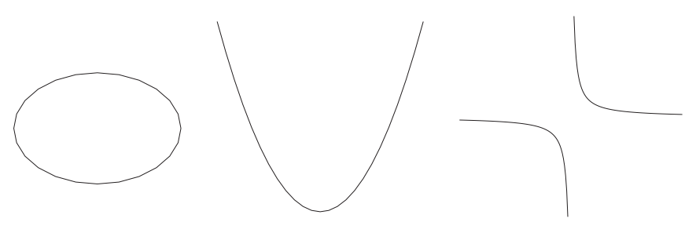

**图 11** 椭圆、抛物线与双曲线。

**Figure 11** Ellipse, parabola, and hyperbola.

曲线 $k$ 的切线，是在某一点与 $k$ “重”相交的直线 $l$；这里“重”的意思是：把 $l$ 中 $y$ 的表达式代入方程 $p(x,y)=0$，所得关于 $x$ 的方程有重解。这一精确的代数条件刻画了如下模糊的想法：$l$ 与 $k$ 只交于一个孤立点 $P$，但任何经过 $P$ 且靠近 $l$ 的直线 $l′$ 都与 $k$ 交于 $P$ 以及 $P$ 附近至少另一点 $P′$。图 12 显示了这种情形。当直线 $l′$ 趋近于 $l$ 时，$l$ 的“二重接触点” $P$ 就是 $l′$ 的两个接触点 $P,P′$ 的极限。

Now a tangent to a curve $k$ is a line $l$ that meets $k$ at a point ‘multiply’, in the sense that there is a multiple solution to the equation for $x$ that results from substituting the expression for $y$ in $l$ in the equation $p(x,y)=0$. This precise algebraic condition captures the vague idea that $l$ meets $k$ at a single isolated point $P$, but that any line $l′$ through $P$ and close to $l$ meets $k$ in $P$ and at least one other point $P′$ near $P$. Figure 12 shows the situation. The ‘double contact point’ $P$ of $l$ is the limit of the two contact points $P,P′$ of $l′$, as the line $l′$ approaches $l$.

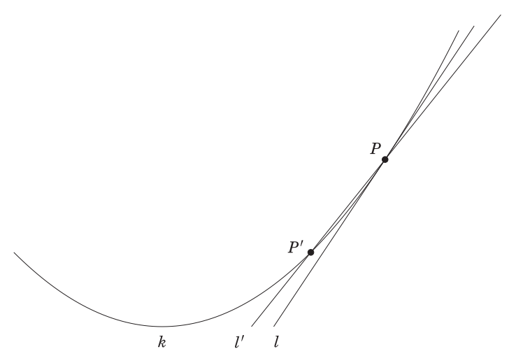

**图 12** 切线与一条邻近的直线。

**Figure 12** A tangent and a nearby line.

例如，直线 $y=2x−1$ 在 $x=1$ 处与抛物线 $y=x2$ 相切，因为把 $y=2x−1$ 代入 $y=x2$，得到方程 $2x−1=x2$，即 $x2−2x+1=0$。这个方程可以改写为 $(x−1)2=0$，这表明它有二重解 $x=1$。

For example, the line $y=2x−1$ is tangent to the parabola $y=x2$ at $x=1$, because when we substitute $y=2x−1$ in $y=x2$ we get the equation $2x−1=x2$, or $x2−2x+1=0$. This equation can be rewritten $(x−1)2=0$, which shows that it has the double solution $x=1$.

类似的计算（如果曲线的次数更高，自然会更复杂）使我们能求出任何代数曲线的切线。然而，求代数曲线与 $x$ 轴之间的面积则是一个难得多的问题，即使对曲线 $y=1/x$ 也是如此。正是在这里，对微积分的需求变得迫切起来。

Similar calculations (though naturally more complicated if the curve has higher degree) allow us to find the tangents to any algebraic curve. However, finding the area between an algebraic curve and the $x$-axis is a more formidable problem, even for the curve $y=1/x$. This is where the need for calculus becomes acute.

## 4.3 无穷小微积分

## 4.3 Infinitesimal Calculus

相切的代数判据陈述起来很简单，尽管用起来可能很困难。一个更严重的异议是，它只适用于代数曲线，而有些在物理上很自然的曲线并不是代数曲线。一个著名的例子是悬链线，即悬挂的链条所呈现的形状。悬链线看起来很像抛物线，但并不是，因此需要另一种方法来求它的切线。

The algebraic criterion for tangency is simple to state, though it can be hard to use. A more serious objection is that it applies only to algebraic curves, and some physically natural curves are not algebraic. One famous example is the catenary, the shape of a hanging chain. The catenary looks rather like a parabola, but it is not, so another method is needed to find its tangents.

事实上，即使对代数曲线，也需要一种更简单的方法——一种能求出任一点处斜率的方法。更好的方法是*微分学*，这一体系产生于对被称为*无穷小*的假想实体的代数与几何研究。

In fact, even for algebraic curves a simpler method is desirable – one that finds the slope at any point. A better method is that of *differential calculus*, a system that arose from the algebra and geometry of hypothetical entities called *infinitesimals*.

许多早期的微积分倡导者都使用过无穷小，始于 1630 年代，并在 1680 年代莱布尼茨的无穷小微积分中臻于成熟。莱布尼茨为无穷小引入了 $dx,dy,dz$ 之类的记号，他似乎把无穷小看作比普通数更小、但又不为零的量。例如，曲线在点 $(x,y)$ 处的斜率，被看作 $(x,y)$ 与曲线上“无穷接近” $(x,y)$ 的点 $(x+dx,y+dy)$ 之间的斜率 $dy/dx$。

Infinitesimals were used by many of the early exponents of calculus, starting in the 1630s and coming to maturity with the infinitesimal calculus of Leibniz in the 1680s. Leibniz introduced the notations $dx,dy,dz$ and the like for infinitesimals, which he seemed to view as quantities smaller than ordinary numbers, yet non-zero. For example, the slope of a curve at a point $(x,y)$ was viewed as the slope $dy/dx$ between $(x,y)$ and a point $(x+dx,y+dy)$ on the curve ‘infinitesimally close’ to $(x,y)$.

给定曲线的方程 $y=f(x)$，一般很容易算出斜率 $dy/dx$。以抛物线 $y=x2$ 为例。此时

Given an equation $y=f(x)$ for the curve, it was generally easy to calculate the slope $dy/dx$. Take the parabola $y=x2$ for example. In this case,

$$dy=(x+dx)2−x2=2xdx+(dx)2,$$

所以

so

$$dydx=2xdx+(dx)2dx=2x+dx.$$

到了这一步，人们便放心地忽略 $dx$，并得出结论：对 $x$ 的任何值，$y=x2$ 的斜率都是 $2x$。（特别地，当 $x=1$ 时斜率为 2，因此该点处切线的方程是 $y=2x−1$，这与上一节用常规代数求得的结果一致。）

At this stage one feels free to neglect $dx$ and conclude that the slope of $y=x2$ for any value of $x$ is $2x$. (In particular, when $x=1$ the slope is 2, so the equation of the tangent at this point is $y=2x−1$, as found by conventional algebra in the previous section.)

用 $dx$ 和 $dy$ 进行的类似计算，可以轻松求出任何代数曲线在曲线上任一点处的斜率，从而求出切线。特别地，$y=xn$ 的斜率是 $nxn−1$。

Similar calculations with $dx$ and $dy$ easily yield the slope of any algebraic curve, and hence the tangent, at any point on the curve. In particular, the slope of $y=xn$ is $nxn−1$.

但这只是无穷小魔力的小小一瞥。它们还使曲边面积的计算成为可能，例如曲线 $y=f(x)$ 下方的面积。为此，我们把面积看作 $x$ 的函数 $A(x)$，取的是固定值 $a$ 与变量值 $x$ 之间的区域，如图 13 所示。$x$ 的无穷小增量 $dx$ 产生面积的无穷小增量 $dA$，我们可以写作

But this is just a small taste of the magic of infinitesimals. They also allow the calculation of curved areas, such as the area under a curve $y=f(x)$. To do this one views the area as a function $A(x)$ of $x$, taking the region between a fixed value $a$ and a variable value $x$, as in Figure 13. An infinitesimal increase $dx$ in $x$ produces an infinitesimal increase $dA$ in area, which we can write

$$dA=f(x)dx,$$

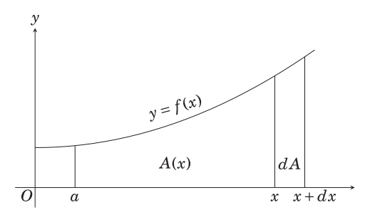

**图 13** 面积的无穷小几何。

**Figure 13** Infinitesimal geometry of area.

因为额外的面积窄条 $dA$ 的宽度为 $dx$，高度与 $f(x)$ 只相差一个无穷小量。（我们再一次选了一个方便的时机来忽略无穷小。）两边同除以 $dx$，我们得出

since the extra strip $dA$ of area has width $dx$ and height that differs only infinitesimally from $f(x)$. (We are again choosing a convenient moment to neglect infinitesimals.) We conclude, dividing both sides by $dx$, that

$$dA(x)dx=f(x).$$

换言之，$A(x)$ 是这样一个函数：它的图像的斜率为 $f(x)$。因此，求曲线下的面积是求斜率的*逆*问题。如果 $f(x)$ 是我们已经作为斜率 $dy/dx$ 求出过的函数，那么我们可以断定面积函数 $A(x)$ 与 $y$ 相同，至少相差一个常数。

In other words, $A(x)$ is a function whose graph has slope is $f(x)$. Thus finding areas under curves is the *inverse* problem to finding slopes. If $f(x)$ is a function we have already found as a slope $dy/dx$, then we can conclude that the area function $A(x)$ is the same as $y$, at least within a constant.

例如，若 $A(x)$ 是抛物线 $y=x2$ 下方 0 与 $x$ 之间的面积，则

For example, if $A(x)$ is the area under the parabola $y=x2$ between 0 and $x$, then

$$dAdx=x2,$$

于是我们可以断定 $A(x)=13x3$，因为当 $y=13x3$ 时 $dydx=x2$，而且函数 $A(x)$ 与 $y$ 在 $x=0$ 时取值相同。

and we may conclude $A(x)=13x3$, because $dydx=x2$ when $y=13x3$, and the functions $A(x)$ and $y$ agree when $x=0$.

简言之，这就是莱布尼茨的无穷小微积分。面积问题与切线问题之间的互逆关系被称为它的*基本定理*。牛顿发现了类似的微积分，只是没有方便而富有启发性的 $dx$ 记号。无穷小微积分的技艺，基本上就是无穷小的代数与几何，再加上对何时“忽略”无穷小的良好判断。（例如，在忽略 $dx$ 之前，先除以 $dx$！）

This, in a nutshell, is the infinitesimal calculus of Leibniz. The inverse relation between the area and tangent problems is called its *fundamental theorem*. Newton discovered a similar calculus, though without the convenient and suggestive $dx$ notation. The art of infinitesimal calculus was basically the algebra and geometry of infinitesimals, allied with some good judgement about when to ‘neglect’ infinitesimals. (For example, divide by $dx$ before neglecting it!)

## 4.4 无穷小：批评与回避

## 4.4 Infinitesimals: Criticism and Avoidance

无穷小有点像虚数。它们似乎与公认的原理相矛盾——正如虚数与平方为正的原理相矛盾，无穷小与第 2.4 节所述的几何量的阿基米德公理相矛盾——然而它们却使原本困难或不可能的计算成为可能。对十七、十八世纪的数学家来说，这一般就是接受它们的充分理由。

Infinitesimals were a bit like imaginary numbers. They seemed to contradict accepted principles – just as imaginaries contradicted the principle that squares are positive, infinitesimals contradicted the Archimedean axiom for geometric quantities, stated in Section 2.4 – yet they enabled calculations that were otherwise difficult or impossible. For mathematicians of the seventeenth and eighteenth centuries this was generally good enough reason to accept them.

但在另一方面，无穷小并不像虚数。虽然虚数确实不属于普通的数系，但很容易扩大这个数系以容纳它们——例如像哈密顿在 1835 年所做的那样，把虚数定义为普通数的有序对。要扩大数系以包含无穷小，就远没有那么容易或方便了。直到二十世纪，人们甚至还不知道这是可能的，而那时数学家们早已决定，最好像欧几里得和阿基米德回避无穷那样回避无穷小。

But in another way infinitesimals were not like imaginaries. While it is true that imaginaries are not part of the ordinary number system, that system can easily be enlarged to accommodate them – for example, by defining imaginaries as ordered pairs of ordinary numbers, as Hamilton did in 1835. It is not nearly as easy, or convenient, to enlarge the number system to include infinitesimals. It was not even known to be possible until the twentieth century, long after mathematicians had decided that it was better to avoid infinitesimals the way Euclid and Archimedes avoided infinity.

在无穷小微积分的初创时期，用穷竭法替换无穷小论证还相当容易，尽管很繁琐。但随着无穷小代数与几何的威力日增，人们对其正确性的信心也越来越强，以古人严格的方式重写论证就成了一件吃力不讨好的事。早在 1659 年，惠更斯就写道：

When infinitesimal calculus was in its infancy it was fairly easy, though tedious, to replace infinitesimal arguments by the method of exhaustion. But as infinitesimal algebra and geometry grew in power, and faith in its correctness grew stronger, it became a thankless task to rewrite arguments in the rigorous ancient manner. As early as 1659, Huygens wrote,

> 如果几何学中的发现（其数量与日俱增，在这个科学的时代看来很可能发展到巨大的规模）继续按照古人的方式以严格的形式呈现，数学家们将永远没有足够的时间去阅读所有这些发现。（见 Huygens 1659，第 337 页）

> Mathematicians will never have enough time to read all the discoveries in Geometry (a quantity which is increasing from day to day and seems likely in this scientific age to develop to enormous proportions) if they continue to be presented in a rigorous form according to the manner of the ancients. (see Huygens 1659, 337)

哲学家们正确地嘲笑了无穷小的概念——贝克莱称之为“逝去量的幽灵”——因为数学家们使用它们的方式松散，有时甚至不一致。但数学家们并没有完全摒弃无穷小，直到出于*数学的*原因被迫如此。而当他们这样做时，那是一场全面的数学革命的一部分，这场革命在数学基础中用算术取代了几何。我们将在接下来的两节中看到这是如何发生的。

Philosophers rightly mocked the concept of infinitesimals – Berkeley called them ‘ghosts of departed quantities’ – because of the loose and sometimes inconsistent way they were used by mathematicians. But mathematicians did not completely dispense with infinitesimals until forced to do so for *mathematical* reasons. And when they did it was part of a general revolution in mathematics that replaced geometry by arithmetic in the foundations of mathematics. We will see how this came about in the next two sections.

## 4.5 复分析

## 4.5 Complex Analysis

微积分与虚数虽然都出身可疑，却在十八、十九世纪结成了强大的联盟。最引人注目的盟友是圆函数与指数函数，它们在十七世纪被分别研究，并被发现可以用无穷级数来表示。约在 1670 年，牛顿发现了指数函数的级数

Calculus and imaginary numbers, though both had dubious origins, formed a powerful alliance in the eighteenth and nineteenth centuries. The most remarkable allies were the circular and exponential functions, which were studied separately in the seventeenth century and found to be expressible by infinite series. Around 1670 Newton discovered the series for the exponential function,

$$ex=1+x1!+x22!+x33!+⋯,$$

他和其他人还重新发现了早已在印度被发现的正弦与余弦级数：

and he and others rediscovered the sine and cosine series that had already been discovered in India:

$$cosx=1−x22!+x44!−x66!+⋯,sinx=x1!−x33!+x55!−x77!+⋯.$$

在 $ex$ 的级数中把 $x$ 换成 $ix$，就得到了奇妙的公式

Replacing $x$ by $ix$ in the series for $ex$ yields the miraculous formula

$$eix=cosx+isinx,$$

这是欧拉（1748）发现的。这个公式不仅使正弦和余弦可以用指数来表示，即

discovered by Euler (1748). This formula not only allows sine and cosine to be expressed in terms of exponentials, namely

$$cosx=12(eix+e−ix),sinx=12i(eix−e−ix),$$

而且还引起人们注意它们的“双曲”类似物：

but also draws attention to their ‘hyperbolic’ analogues:

$$coshx=12(ex+e−x),sinhx=12(ex−e−x).$$

这种类比或许有助于解释兰伯特（1766，§82）的一个大胆猜想。兰伯特引入了双曲函数，并且无疑了解涉及正弦和余弦的球面三角公式。于是他可能猜想，涉及双曲正弦和双曲余弦的类似公式描述的是“虚半径球面”上的三角学。如果是这样，就可以解释他 1766 年的猜想：非欧几何或许在一个虚球面上成立。（关于非欧几何和兰伯特的虚球面，另见第 6.2 节和第 6.5 节。）

This analogy may help to explain a wild conjecture of Lambert (1766, §82). Lambert introduced the hyperbolic functions and was no doubt aware of the formulas of spherical trigonometry, which involve sine and cosine. He may then have guessed that the analogous formulas involving hyperbolic sine and cosine describe trigonometry on a ‘sphere of imaginary radius’. If so, this could explain his 1766 conjecture that non-Euclidean geometry may hold on an imaginary sphere. (See also Sections 6.2 and 6.5 for more about non-Euclidean geometry and Lambert’s imaginary sphere.)

## 4.6 哲学问题

## 4.6 Philosophical Issues

在讨论微积分之前，应当提一下笛卡尔（1637）那本代数几何著作的一个重要副产品——长度的乘法。正如我们在第 1.3 节提到的，长度有一种自然的和，它本身仍是一个长度；但欧几里得及其后继者把两个长度之积看作一个矩形，这严重限制了任何长度的代数。

但还有另一种定义长度之积的方法，它基于相似三角形的比例关系（图 14）。为此，我们选取一个单位长度，即图 14 中标为 1 的长度，并按图示位置构造包含长度 $a$ 和 $b$ 的相似三角形。于是由比例关系可知，正如长度 1 的延续是长度 $b$，长度 $a$ 的延续就是长度 $ab$。

But there is another way to define product of lengths, based on the proportionality of similar triangles (Figure 14). To do so we choose a unit length, marked 1 in Figure 14, and construct the similar triangles containing the lengths $a$ and $b$ in the positions shown. Then it follows by proportionality that, just as the continuation of length 1 is length $b$, the continuation of length $a$ is length $ab$.

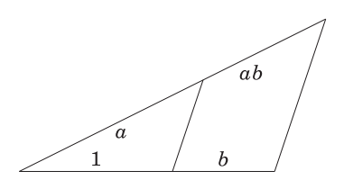

**图 14** 通过相似性定义长度之积。

**Figure 14** Product of lengths via similarity.

笛卡尔利用这一事实来定义长度之积，从而赋予长度一种与数相似的代数结构。他还指出了求任意长度的平方根的一种简单几何作图（同样涉及相似三角形）。因此，笛卡尔（1637）扫除了由无理长度的存在所引起的一些古老问题：长度毕竟确实像数一样运作，而任何数的平方根也是一个数，这是合理的。

Descartes used this fact to define the product of lengths, thus giving lengths an algebraic structure like that of numbers. He also pointed out a simple geometric construction (also involving similar triangles) for the square root of any length. Thus Descartes (1637) swept away some of the ancient problems posed by the existence of irrational lengths: lengths did behave like numbers after all, and it was reasonable for the square root of any number to be a number.

然而，一个哲学困难刚被消除，微积分又制造了另一个。事实上，微积分的发明对数学哲学的扰动，或许超过了自无理量的发现以来的任何事件。哲学家们正确地质疑了无穷小的概念，但数学家们起初对他们的批评置之不理，仍然相信自己可以用欧几里得的方法得到微积分的结果（尽管他们很少真的这样做）。这一僵局直到 1800 年以后才被打破，那时数学家们不得不承认，欧几里得毕竟不足以作为数学的基础。

But, as soon as one philosophical difficulty was removed, calculus created another. In fact, the invention of calculus disrupted the philosophy of mathematics perhaps more than any event since the discovery of irrational quantities. Philosophers rightly questioned the concept of infinitesimal, but mathematicians at first ignored their criticisms and continued to believe they could obtain calculus results by Euclid’s methods (though they seldom actually did so). There was a stalemate which would not be broken until after 1800, when mathematicians had to concede that Euclid was, after all, not an adequate foundation for mathematics.

**直觉与逻辑。**直觉在微积分中起着主导作用（至今依然如此）：人们用“曲线上无穷接近的点”和“无穷细的窄条”来建立计算切线和面积的方程。但一旦方程被找到，（无穷小代数中）代数符号的力量便占了上风。数学家们相信微积分，是因为它在解决几何和力学问题上取得了惊人的成功。他们还认为自己立足于坚实的基础之上，相信所有结果都能用穷竭法严格地得到。

**Intuition and logic.** Intuition played a leading role in calculus (and still does), where ‘infinitesimally close points on a curve’ and ‘infinitesimally thin strips’ were used to set up equations for calculating tangents and areas. But, once the equations were found, the force of algebraic symbolism (in the algebra of infinitesimals) prevailed. Mathematicians believed in calculus because of its amazing success in solving problems in geometry and mechanics. They also thought they were on solid ground, believing that all their results could be obtained rigorously by the method of exhaustion.

**意义与存在。**然而，正如贝克莱所指出的，无穷小的存在是非常可疑的，那么，是什么解释了它们的成功呢？（在贝克莱之前，霍布斯曾严厉批评微积分以及在几何中使用代数。但他提出了一种站不住脚的关于圆的说法——声称圆只包含有限多个点——并声称借此解决了古老的“化圆为方”问题，从而在数学家面前丧失了信誉。）

**Meaning and existence.** Yet, as Berkeley pointed out, the existence of infinitesimals was highly dubious, so what explained their success? (Before Berkeley, Hobbes had made harsh criticisms of calculus and of the use of algebra in geometry. But he destroyed his credibility with mathematicians by proposing an untenable account of the circle – claiming that it contains only finitely many points – and claiming thereby to solve the ancient problem of ‘squaring the circle’.)

**离散与连续。**另一方面，无穷小在离散与连续之间提供了一座新的桥梁（尽管摇摇欲坠）。连续统的图景并不清晰，或许还自相矛盾，但人们却能正确地计算长度和面积。那么，无穷小或许有助于解释连续统的本性？

**Discrete and continuous.** Then again, infinitesimals provided a new bridge (albeit rickety) between the discrete and continuous. The picture of the continuum was unclear, and perhaps contradictory, yet one could correctly calculate lengths and areas. So perhaps infinitesimals could help explain the nature of the continuum?

从长远来看，人们发现由无穷小引起的问题是关于连续统本性的问题，特别是关于它作为一种特殊无穷集合的本性的问题。在接下来的两节中，我们将看到这个问题及其哲学含义是如何展开的。

In the long run, the problems raised by infinitesimals were found to be problems about the nature of the continuum, and particularly its nature as a particular kind of infinite set. In the next two sections we will see how this problem, and its philosophical implications, unfolded.

# 5 连续函数与实数

# 5 Continuous Functions and Real Numbers

### 预览

### PREVIEW

微积分能够处理许多具体函数，但一般的函数概念仍然模糊。约在 1800 年，有必要证明连续函数的一些一般性质——令人惊讶的是，这是为了证明代数基本定理。在十八世纪对这一定理作过一些可疑的证明尝试之后，高斯提出了几个证明。其中最令人信服的是高斯（1816）中的证明，它把定理化归为奇数次多项式的特殊情形。这样的多项式 $p(x)$ 的取值会“连续地”从正值（当 $x$ 为很大的正数时）变到负值（当 $x$ 为很大的负数时）。于是看起来显然，这个多项式会在某处取值 0，正如基本定理所要求的那样。

Calculus could deal with many specific functions, but the general function concept remained vague. Around 1800, it became necessary to prove some general properties of continuous functions – surprisingly, in order to prove the fundamental theorem of algebra. After some dubious attempts to prove this theorem in the eighteenth century, Gauss proposed several proofs. The most convincing was one in Gauss (1816), which reduced the theorem to the special case of odd-degree polynomials. Such a polynomial $p(x)$ takes values that change ‘continuously’ from positive (for large positive $x$) to negative (for large negative $x$). It then seems obvious that the polynomial takes the value 0 somewhere, as required for the fundamental theorem.

波尔查诺（1817）指出了高斯证明中的关键假设，即连续函数的*介值定理*：如果当 $x$ 变化时 $f(x)$ 是一个从负值连续变化到正值的函数，那么对某个 $x$ 值有 $f(x)=0$。波尔查诺能够给出连续性的令人满意的定义，但为了证明介值定理，他不得不假定实数的一条性质，即*最小上界性质*：如果 $S$ 是一个有界的实数集，那么 $S$ 有最小上界。

Bolzano (1817) put his finger on the key assumption of Gauss’s proof, the *intermediate value theorem* for continuous functions: if $f(x)$ is function that varies continuously from negative to positive as $x$ varies, then $f(x)=0$ for some value of $x$. Bolzano was able to give a satisfactory definition of continuity, but to prove the intermediate value theorem he had to assume a property of the real numbers, the *least upper bound property*: if $S$ is a bounded set of real numbers, then $S$ has a least upper bound.

从欧几里得的几何实数概念出发，不可能证明最小上界性质，而在此之前人们一直认为这一概念是充分的。人们终于不得不着手处理调和离散与连续这一未竟之事。

It was not possible to prove the least upper bound property from Euclid’s geometric concept of real number, which had been thought adequate until then. It was finally necessary to grapple with the unfinished business of reconciling the discrete with the continuous.

## 5.1 代数基本定理

## 5.1 The Fundamental Theorem of Algebra

我们在第 3.1 节看到，存在一个求解三次方程的公式，它于 1545 年由卡尔达诺首次发表。在同一本书中，卡尔达诺还发表了求解四次方程的公式。两个公式都用方程的系数、有理运算 $+,−,×,÷$ 以及平方根和立方根来表示解。这激起了人们对高次方程也有类似解法的希望——即当时所称的*根式解*（$n$ 次根）。这一希望最终在 1820 年代被阿贝尔和伽罗瓦打破，他们证明了五次及更高次的方程不存在这样的公式。

We saw in Section 3.1 that there is a formula for solving cubic equations, first published by Cardano in 1545. In the same book Cardano also published a formula for solving quartic (fourth-degree) equations. Both formulas express the solution in terms of the coefficients of the equation, the rational operations $+,−,×,÷$ and square and cube roots. This raised the hope of similar solutions for higher-degree equations – *solutions by radicals* ($n$ th roots), as they were called. This hope was eventually dashed in the 1820s by Abel and Galois, who showed that no such formulas exist for equations of fifth degree and higher.

但在根式解被排除之前，高斯就已经提出了处理多项式方程的另一种途径：满足于证明解的*存在性*，而不是用公式求出它。约在 1800 年，高斯以这种风格给出了几个证明，其关键要素是诉诸连续函数的性质。

But before solution by radicals was ruled out, Gauss had already suggested a different approach to polynomial equations: be content to prove *existence* of a solution rather finding it in a formula. Around 1800, Gauss gave several proofs in this style, the key ingredient of which was appeal to properties of continuous functions.

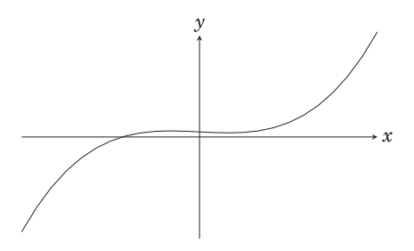

**图 15** $y=x3−x+2$ 的图像。

**Figure 15** The graph of $y=x3−x+2$.

存在性证明所带来的简化，可以用一个三次方程的情形来说明，例如 $x3−x+2=0$。只要看一下 $y=x3−x+2$ 的图像（图 15），就立即清楚为什么对某个 $x$ 值有 $x3−x+2=0$。图像连续地从负值（当 $x$ 为很大的负值时）过渡到正值（当 $x$ 为很大的正值时），因此它必在某处取值 0。

The simplification made possible by an existence proof can be illustrated in the case of a cubic equation, say $x3−x+2=0$. If one inspects the graph of $y=x3−x+2$ (Figure 15) then it is immediately clear why $x3−x+2=0$ for some value of $x$. The graph passes continuously from negative values (for large negative values of $x$) to positive values (for large positive values of $x$), and hence it somewhere takes the value 0.

同样的论证适用于任何奇数次多项式。1816 年，高斯借助一些巧妙的代数把它推广到任意次数的多项式：这种代数把 $2n$ 次方程的求解化归为一个二次方程（其解可能是复数）和一个 $n$ 次方程的求解。通过反复把次数减半，最终会得到一个奇数次方程，因此解存在。这样，高斯（1816）的论证就把任何多项式方程的解的存在性——即如今所称的*代数基本定理*——化归为一些代数，再加上关于连续函数的一个看似显然的事实。

The same argument applies to any polynomial of odd degree. In 1816 Gauss extended it to polynomials of any degree by some ingenious algebra that reduces the solution of an equation of degree $2n$ to the solution of a quadratic (where the solution may be complex) and an equation of degree $n$. By repeatedly halving the degree one reaches an equation of odd degree, and hence a solution exists. Thus Gauss’s (1816) argument reduces the existence of solutions of any polynomial equation – the *fundamental theorem of algebra* as it is now called – to some algebra plus a seemingly obvious fact about continuous functions.

高斯乐于假定有关连续性的事实，但事实上，他正站在一个新的实分析世界的边缘；在这个世界里，连续函数的本性与性质成为关注的焦点。

Gauss was happy to assume facts about continuity, but in fact he stood on the brink of a new world of real analysis, in which the nature and properties of continuous functions were the focus of attention.

## 5.2 介值定理

## 5.2 The Intermediate Value Theorem

值得注意的是，高斯（1816）的证明立即受到了关注，其中关于连续函数的关键思想被波尔查诺（1817）表述为一条定理。这就是我们今天所说的介值定理。

Remarkably, Gauss’s (1816) proof was immediately noticed, and its crucial idea about continuous functions formulated as a theorem by Bolzano (1817). This is what we now call the intermediate value theorem.

**介值定理。**如果 $f$ 是一个对满足 $a≤x≤b$ 的 $x$ 有定义的连续函数，并且 $f(a)<0$、$f(b)>0$，那么对 $a$ 与 $b$ 之间的某个 $c$，有 $f(c)=0$。

**Intermediate Value Theorem.** If $f$ is a continuous function, defined for $x$ with $a≤x≤b$, and if $f(a)<0$ and $f(b)>0$, then $f(c)=0$ for some $c$ between $a$ and $b$.

为了陈述这条定理，波尔查诺必须定义“连续”是什么意思，而他得出的本质上就是现代的定义：$f$ 在 $x$ 处连续，是指对每个 $ε>0$，都存在 $δ>0$，使得 $|x−x′|<δ⇒|f(x)−f(x′)|<ε$。（不那么正式地说：只要选取足够接近 $x$ 的 $x′$，就能使 $f(x′)$ 任意接近 $f(x)$。）于是，若对每个满足 $a≤x≤b$ 的 $x$，$f$ 都在 $x$ 处连续，那么 $f$ 就简单地称为在 $x$ 从 $a$ 到 $b$ 上连续。

To state the theorem, Bolzano had to define what ‘continuous’ means, and he came up with essentially the modern definition: $f$ is continuous at $x$ if, for each $ε>0$ there is a $δ>0$ such that $|x−x′|<δ⇒|f(x)−f(x′)|<ε$. (Speaking less formally: we can make $f(x′)$ as close as we please to $f(x)$ by choosing $x′$ sufficiently close to $x$.) Then $f$ is simply continuous for $x$ from $a$ to $b$ if $f$ is continuous at $x$ whenever $a≤x≤b$.

即使以非正式的方式陈述，也并不清楚这个定义是否表达了人们希望“连续”所具有的含义。人们更愿意说“$y=f(x)$ 的图像是不间断的”，或诸如此类的话——事实上，就是某种类似介值定理的说法。波尔查诺非凡的洞察力使他得出了这样一个定义：它使得“不间断”这一模糊的整体性质，可以从“在一点处连续”这一精确的局部性质推出。

Even when stated informally, it is not clear that this definition states what one wants ‘continuous’ to mean. One would prefer to say ‘the graph of $y=f(x)$ is unbroken’, or something like that – in fact, something like the intermediate value theorem. Bolzano’s extraordinary insight led him to a definition that allows the vague global property of unbrokenness to follow from the precise local property of continuity at a point.

波尔查诺无疑拥有证明介值定理所需的正确的连续性定义，但他的证明依赖于数的一条未经证明的性质。这就是最小上界原理，它断言任何有界的数集都有最小上界。波尔查诺只能为这一原理给出模糊的论证，因为他对数轴只有一个模糊的、几何的概念。在数的概念以纯算术的方式得到定义之前，不可能再前进一步。

Bolzano certainly had the right definition of continuity to prove the intermediate value theorem, but his proof depended on an unproved property of numbers. This was the least upper bound principle, stating that any bounded set of numbers has a least upper bound. Bolzano could give only vague justification for this principle, because he had only a vague, geometric, conception of the number line. It was not possible to go further until the number concept had been defined in purely arithmetic fashion.

## 5.3 实数的定义

## 5.3 Definition of Real Numbers

波尔查诺的工作很少受到关注；在他之后几十年，戴德金也对微积分中的直觉论证感到类似的不满。他在 1872 年的小册子《连续性与无理数》中写道：

Some decades after Bolzano, whose work received little attention, Dedekind experienced a similar dissatisfaction with intuitive arguments in calculus. In his 1872 booklet *Continuity and Irrational Numbers*, he wrote,

> 作为苏黎世理工学院的教授，我第一次不得不讲授微分学的基础，并且比以往任何时候都更强烈地感到算术缺乏一个真正科学的基础。在讨论一个变量趋近于一个固定极限值的概念时，特别是在证明“一个不断增长但不超过一切界限的量必定趋近于一个极限值”这一定理时，我求助于几何论证……更仔细的研究使我确信，这条定理或任何与之等价的定理，在某种意义上都可以被看作无穷小分析的充分基础。剩下的只是要在算术的基本要素中发现它的真正起源，从而同时获得连续性本质的一个真正的定义。我在 1858 年 11 月 24 日成功了。

> As professor in the Polytechnic School in Zürich I found myself for the first time obliged to lecture on the elements of the differential calculus and felt more keenly than ever before the lack of a really scientific foundation for arithmetic. In discussing the notion of the approach of a variable magnitude to a fixed limiting value, and especially in proving the theorem that a magnitude which grows continually, but not beyond all limits, must certainly approach a limiting value, I had recourse to geometric arguments … a more careful investigation convinced me that this theorem, or any one equivalent to it, can be regarded in some way as a sufficient basis for infinitesimal analysis. It then only remained to discover its true origin in the elements of arithmetic and thus at the same time to secure a real definition of the essence of continuity. I succeeded Nov. 24, 1858.

戴德金所说的“连续性”，就是我们今天所称的实数的*连通性*；非正式地说，就是实数“没有空隙”。在这方面，它们与有理数形成对比，后者在 $2$ 的位置以及许多其他位置都有空隙。

By ‘continuity’, Dedekind means what we now call the *connectedness* of the real numbers; informally, that they have ‘no gaps’. In this respect they contrast with the rational numbers, which have a gap at the position of $2$ and many other places.

这一思想显然类似于欧几里得《几何原本》第五卷对无理量的处理（第 2.4 节），只不过无穷集合不再被回避。戴德金大胆而简单的思想，是把无穷集合用作数学对象。于是，“有理数中的空隙”就是一个有意义的数学对象——一对具有上述性质的集合 $L,U$——我们可以用它来*定义*一个无理数。这样，有理数与无理数合在一起就构成了一个没有空隙的数系，我们今天称之为*实数系* $ℝ$。

This idea is clearly similar to the treatment of irrational quantities in Book V of Euclid’s *Elements* (Section 2.4) except that infinite sets are no longer avoided. Dedekind’s bold but simple idea was to use infinite sets as mathematical objects. A ‘gap in the rationals’ is then a meaningful mathematical object – a pair of sets $L,U$ with the above properties – which we can take to *define* an irrational number. Thus the rationals and irrationals together form a number system without gaps, which we now call the *real number system* $ℝ$.

通过以这种方式把实数建立在有理数之上，戴德金发现，实数的连通性在“算术的基本要素中”有其“真正的起源”。此外，很容易证明有理数的代数性质（例如 $a+b=b+a$ 和 $ab=ba$）以自然的方式延续到实数上。而借助集合概念，戴德金发现同样容易证明波尔查诺的最小上界原理，从而为实分析提供了算术基础。

By basing the real numbers on rational numbers in this way, Dedekind had found their connectedness had its ‘true origin in the elements of arithmetic’. Moreover, it is easy to show that the algebraic properties of the rational numbers (such as $a+b=b+a$ and $ab=ba$) carry over to the real numbers in a natural way. And by using the set concept, Dedekind found it equally easy to prove Bolzano’s least upper bound principle, and hence provide an arithmetic foundation for real analysis.

为了证明最小上界原理，我们首先用一个有上界且“向下封闭”的有理数集 $Lx$ 来表示每个实数 $x$；所谓向下封闭，是指具有如下性质：若 $r∈Lx$ 且 $s<r$，则 $s∈Lx$。对于无理数 $x$，$Lx$ 就是定义 $x$ 的那对 $L,U$ 中的 $L$；对于有理数 $x$，我们取 $Lx$ 为所有 $≤x$ 的有理数之集。这种表示具有一个便利的性质：实数的序对应于集合的包含关系，即 $x≤y$ 当且仅当 $Lx⊆Ly$。

To prove the least upper bound principle, we first represent each real number $x$ by a set $Lx$ of rational numbers which is bounded above and ‘closed downward’: that is, with the property that if $r∈Lx$ and $s<r$ then $s<Lx$. For an irrational number $x$, $Lx$ is the $L$ in the pair $L,U$ that defines $x$; for a rational number $x$ we take $Lx$ to be the set of rationals $≤x$. This representation has the convenient property that the ordering of real numbers corresponds to set containment: namely, $x≤y$ if and only if $Lx⊆Ly$.

于是，如果我们有一个有界的实数集 $x$，那么集合 $Lx$ 也都有界，从而它们的并 $L$ 也有界。由此可知，由集合 $L$ 所确定的实数 $l$ 就是这些数 $x$ 的最小上界。

Then if we have a bounded set of real numbers $x$, the sets $Lx$ are also bounded, and hence so is their union $L$. It follows that the real number $l$ determined by the set $L$ is the least upper bound of the numbers $x$.

（注：PDF 原文此处印作“then s < L<sub>x</sub>”，应为排版错误；按上下文中文译为 s ∈ L<sub>x</sub>；英文保留原文。）

(Note: the PDF prints “then s < L<sub>x</sub>” here, evidently a typesetting error; it is the sense required is s ∈ L<sub>x</sub>. The English is kept as printed.)

## 5.4 反直觉的曲线

## 5.4 Counter-intuitive Curves

通过把几何直觉从分析的基础中驱逐出去，波尔查诺和戴德金使反直觉的对象得以被研究和精确分析。对一些数学家来说，这是令人震惊的发展，他们“怀着恐惧与厌恶，背离了这场可怕的瘟疫”（转述埃尔米特 1893 年致斯蒂尔吉斯的一封信）。但对另一些人来说，这是受欢迎的，它不仅提供了严格性，还提供了一种真正磨砺直觉、看到朴素直觉所看不到的东西的途径。

By banishing geometric intuition from the foundations of analysis, Bolzano and Dedekind made it possible for counter-intuitive objects to be studied and accurately analysed. For some mathematicians, this was shocking development, and they ‘turned away in horror and disgust from this awful plague’ (to paraphrase a letter from Hermite to Stieltjes in 1893). But for others it was welcome, offering not only rigor but a way to actually sharpen one’s intuition and see things that naive intuition could not.

旧的无穷小形式体系不够锐利，因为它暗示：连续函数 $y=f(x)$ 就是 $x$ 的无穷小变化 $dx$ 导致 $y$ 的无穷小变化 $dy$ 的函数。于是这种记号使我们相信 $dy/dx$ 存在；也就是说，连续函数 $y=f(x)$ 的图像在每一点都有斜率。事实上，牛顿和其他微积分的奠基者就是这样相信的。但他们错了：波尔查诺和其他十九世纪数学家发现，存在在任何一点都没有切线的连续曲线，以及具有其他反直觉性质的曲线。

The old formalism of infinitesimals was not sharp enough, because it suggests that a continuous function $y=f(x)$ is one for which an infinitesimal change $dx$ in $x$ produces an infinitesimal change $dy$ in $y$. The notation then leads us to believe that $dy/dx$ exists; that is, the graph of a continuous $y=f(x)$ has a slope at each point. Indeed, Newton and other founders of calculus believed as much. But they were wrong: Bolzano and other nineteenth-century mathematicians discovered that there are continuous curves with no tangent at any point, and other counter-intuitive properties.

冯·科赫（1904）给出了一个没有切线的曲线的可爱例子，它作为一列折线的极限而得到。该序列的前五条折线如图 16 所示。

A lovely example of a curve without tangents, obtained as the limit of the sequence of polygonal curves, was given by von Koch (1904). The first five polygons of the sequence are shown in Figure 16.

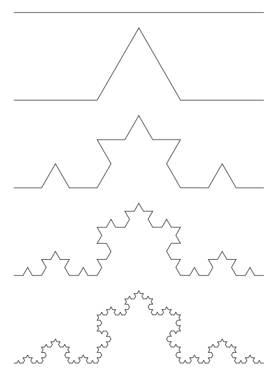

**图 16** 科赫折线序列。

**Figure 16** The Koch polygon sequence.

我认为，这个序列有一条连续的极限曲线，这是“直观的”。但同样可以“看出”它没有切线。从它的构造可以清楚地看到，极限曲线可以分成四段（对应于第二幅图中的四条线段），每一段放大 3 倍后都与整条曲线一模一样。但如果曲线在任一点有切线，那么该点的邻域在放大之下应当变得更直。

It is, I think, ‘intuitive’ that this sequence has a continuous limit curve. But it can also be ‘seen’ that it has no tangents. It is clear from its construction that the limit curve can be divided into four pieces (corresponding to the four line segments in the second picture), each of which looks exactly the same as the whole curve when magnified by 3. But if the curve had a tangent at any point, the neighbourhood of that point would become straighter under magnification.

在维连金（1995）的《寻找无穷》一书中，可以找到许多其他可以说服直觉去把握的奇异对象的例子。它们表明，我们的几何直觉所能做的，远比十九世纪以前的数学家所认为的多。尽管如此，十九世纪还出现了对直觉的其他挑战，我们将在下一节看到。

Many other examples of bizarre objects that intuition can be persuaded to grasp may be found in the book *In Search of Infinity* by Vilenkin (1995). They show that our geometric intuition is capable of much more than mathematicians thought, before the nineteenth century. Nevertheless, other challenges to intuition arose in the nineteenth century, as we will see in the next section.

## 5.5 哲学问题

## 5.5 Philosophical Issues

介值定理的证明是一个无穷构造，它通过反复把 $c$ 应在其中的区间减半，来捕捉使 $f(c)=0$ 的点 $c$。它与经典的穷竭法证明（假定最小上界存在）并没有太大不同，只不过它依赖于“给定”函数 $f$。在波尔查诺的时代，这意味着什么并不清楚，这就引起了一种怀疑：介值定理纯粹是一个*存在性*定理，其中声称对象 $c$ 存在，却没有构造出它。

The proof of the intermediate value theorem is an infinite construction that captures the point $c$ where $f(c)=0$ by repeatedly halving the interval in which $c$ ought to lie. It is not so different from a classical proof by exhaustion (assuming the existence of least upper bounds), except that it depends on being ‘given’ the function $f$. In Bolzano’s time, it was not clear what this meant, which created the suspicion that the intermediate value theorem is purely an *existence* theorem, where the object $c$ is claimed to exist but not constructed.

实际上，当 $f$ 是多项式时（如在代数基本定理中），构造 $c$ 不成问题。但关于连续函数的更多存在性定理接踵而至，它们在十九世纪后期成为与“构造主义者”争论的焦点。无论如何，波尔查诺证明中更成问题的部分，是如何定义实数，以保证最小上界性质以及它们的代数结构：简言之，就是直线的算术化。正如我们将在接下来的两节中看到的，这引发了一连串始料未及的哲学问题。

Actually, construction of $c$ is not a problem when $f$ is a polynomial, as in the fundamental theorem of algebra. But more existence theorems about continuous functions were to follow, and they became a bone of contention with ‘constructivists’ later in the nineteenth century. In any case, the more problematic part of Bolzano’s proof is defining the real numbers so as to guarantee the least upper bound property and also their algebraic structure: in short, the arithmetization of the line. This led to an eruption of unforeseen philosophical problems, as we will see in the next two sections.

但紧随波尔查诺和戴德金之后，就已经出现了若干问题。

But, in the immediate wake of Bolzano and Dedekind, there were already several issues.

**直觉与逻辑。**与“代数是离散的”这一直觉相反，代数基本定理似乎涉及连续性。而关于连续曲线（以及一般而言关于微积分）的直觉，需要一个更深的基础，即实数的算术理论。

**Intuition and logic.** Contrary to the intuition that algebra is discrete, the fundamental theorem of algebra seems to involve continuity. And the intuition about continuous curves (and calculus in general) demands a deeper foundation, in an arithmetic theory of real numbers.

**意义与存在。**在不给出所声称存在的对象的公式的情况下证明其存在，这意味着什么？实数究竟是什么？是什么解释了它们的*完备性*，即它们在各种无穷运算下的封闭性？（戴德金的定义给出了一个答案；还有其他选择吗？）

**Meaning and existence.** What does it mean to prove existence, without giving a formula for the object claimed to exist? What precisely are the real numbers, and what explains their *completeness*; that is, their closure under various infinite operations? (Dedekind’s definition gives one answer; are there alternatives?)

**离散与连续。**特别是，我们如何能够——在避开无穷小这种可疑手段的前提下——最好地用离散（自然数）来定义连续（实数）？

**Discrete and continuous.** In particular, how best can we – avoiding the dubious means of infinitesimals – define the continuous (real numbers) in terms of the discrete (natural numbers)?

# 6 从非欧几何到算术

# 6 From Non-Euclidean Geometry to Arithmetic

### 预览

### PREVIEW

与此同时，欧几里得在另一方面也被发现有所欠缺。几百年甚至几千年来，平行公理一直被视为欧几里得体系上一个不必要的瑕疵。许多数学家曾试图从欧几里得的其他公理证明它，但到 1800 年，希望已日渐渺茫。一些人开始考虑此前不可想象的东西：一种平行公理不成立的*非欧几何*。

Meanwhile, Euclid had been found wanting in another respect. For hundreds, if not thousands, of years the parallel axiom had been considered an unnecessary blemish on Euclid’s system. Many mathematicians had tried to prove it from Euclid’s other axioms, but by 1800 hopes were fading. Some began to consider the previously unthinkable: a *non-Euclidean geometry* in which the parallel axiom was false.

这种奇异而美妙的几何起初只是在假设性地被探索。但贝尔特拉米（1868）找到了它的*模型*，表明非欧几何与欧氏几何同样一致。随着这一发现，欧氏几何失去了它在数学基础中（以及作为物理空间的假定几何）的特权地位。

This strange but wonderful geometry was at first explored only hypothetically. But Beltrami (1868) found *models* of it, showing that non-Euclidean geometry is just as consistent as Euclidean. With this discovery, Euclidean geometry lost its privileged position at the foundation of mathematics (and as the presumed geometry of physical space).

是时候建立数学的新基础了，而算术已准备好取代几何的位置。戴德金找到了实数直线 $ℝ$ 的算术定义，在此之上可以建立几何与分析的新基础：格拉斯曼的实向量空间。

It was time to build a new foundation of mathematics, and arithmetic was ready to take the place of geometry. Dedekind had found an arithmetic definition of the real number line $ℝ$, on which it was possible to build a new foundation of geometry and analysis: the real vector spaces of Grassmann.

## 6.1 平行公理

## 6.1 The Parallel Axiom

正如我们在上一节所见，十九世纪上半叶的数学家在*微观*层面上对几何直觉失去了信心，因为在那里它未能把握直线的局部性质。大约在同一时期，人们在*宏观*层面上也对几何直觉失去了信心，因为在那里它未能把握直线的整体性质——特别是平行线的行为。

As we saw in the previous section, mathematicians in the first half of the nineteenth century lost faith in geometric intuition at the *micro* level, where it failed to grasp the local nature of the line. During roughly the same time period there was also a loss of faith in geometric intuition at the *macro* level, where it failed to grasp the global nature of lines – in particular, the behaviour of parallels.

第 1.4 节已经指出问题所在：在于欧几里得的平行公理，它隐含地断言了平行线的存在性与唯一性。平行公理是一条非常有用的公理，被用于证明欧几里得几何的许多标志性定理，例如勾股定理。事实上，就连正方形的存在也依赖于平行公理，因为需要唯一的平行线来证明三角形的内角和为 $π$，进而证明四边形的内角和为 $2π$。平行公理的另一个重要推论（与我们的经验非常吻合）是：任何大小的图形都可以具有相同的形状。

Section 1.4 showed where the problem lies: in Euclid’s parallel axiom, which implicitly claims the existence and uniqueness of parallels. The parallel axiom was a very useful axiom, used in the proof of many signature theorems of Euclid’s geometry, such as the Pythagorean theorem. In fact, even the existence of squares depends on the parallel axiom, because unique parallels are needed to prove that the angle sum of a triangle is $π$, and hence that the angle sum of a quadrilateral is $2π$. Another important consequence of the parallel axiom, which chimes well with our experience, is that figures of any size can have the same shape.

对许多人来说，这类定理比平行公理本身更容易接受，人们也找到了它们蕴涵平行公理的证明。最终的希望是：欧几里得的其他公理——它们无疑比平行公理更可信——或许能被发现蕴涵平行公理，这样欧几里得体系上的这个“瑕疵”就可以被去除。欧几里得的其他公理所说的都是无可争议的事情，例如：过任意两点有唯一一条直线；直线是无限的；如果两个三角形有两边及其夹角对应相等，那么它们的所有边和所有角都对应相等。

To many, theorems like these were more acceptable than the parallel axiom itself, and proofs that they imply the parallel axiom were found. The ultimate hope was that Euclid’s other axioms – which are certainly more plausible than the parallel axiom – might be found to imply the parallel axiom, so that this ‘blemish’ on Euclid could be removed. Euclid’s other axioms say uncontroversial things like: there is a unique line through any two points, lines are infinite, and if two triangles agree in two sides and the included angle then they agree in all sides and all angles.

人们希望，如果采用其他公理，再加上“平行线不唯一”这条公理，就会发现矛盾。第一个追寻这个难以捉摸的矛盾的人是萨凯里（1733），见于他的著作《欧几里得无懈可击》。他发现（并不意外）这些公理蕴涵三角形的内角和小于 $π$，四边形的内角和小于 $2π$。他还发现（更令人意外）两条直线可以是*渐近的*；也就是说，它们可以任意地相互接近而不相交。萨凯里认为这“与直线的本性相悖”，但这仍然不是矛盾。事实上，这是对非欧世界的一次准确的惊鸿一瞥。

If one takes the other axioms, and adds the axiom that parallels are not unique, the hope was that a contradiction would be discovered. The first to pursue the elusive contradiction was Saccheri (1733), in his book *Euclid Vindicated from Every Blemish*. He found, not surprisingly, that these axioms imply that the angle sum of a triangle is less than $π$ and the angle sum of a quadrilateral is less than $2π$. He also found, more surprisingly, that two lines could be *asymptotic*; that is, they could approach each other arbitrarily closely without meeting. Saccheri found this ‘abhorrent to the nature of straight lines’, but still it was not a contradiction. In fact, it was an accurate glimpse of the non-Euclidean world.

## 6.2 非欧几何

## 6.2 Non-Euclidean Geometry

在十九世纪最初的几十年里，数学家们开始以不那么怀疑的态度探索这个假设的非欧世界。高斯本人了解平行线不唯一的种种推论，但不敢发表。直到 1820 年代，才由鲍耶和罗巴切夫斯基各自独立地发展并发表了基本定理。1830 年代，明金的工作中也有一个暗示：非欧三角学的公式在某些马鞍形曲面上是有意义的。这些公式与球面三角学的公式相似，只是把正弦和余弦换成了它们的双曲类似物；如果把“直线”取为曲面上的*测地线*——即长度最短的曲线——它们就成立。但明金的发现还不足以完全实现非欧几何，因为他的曲面是不完备的——它们不允许在每个方向上都有无限的“直线”。

In the first decades of the nineteenth century, mathematicians began to explore the hypothetical non-Euclidean world less sceptically. Gauss himself was aware of the implications of non-unique parallels, but was afraid to publish them. It was left to Bolyai and Lobachevsky, in the 1820s, to independently develop and publish the basic theorems. There was also a hint, in the work of Minding in the 1830s, that the formulas of non-Euclidean trigonometry made sense on certain saddle-shaped surfaces. These formulas, which are like those of spherical trigonometry except that sine and cosine are replaced by their hyperbolic analogues, hold if ‘lines’ were taken to be *geodesics* – curves of shortest length – on the surface. But Minding’s discovery fell short of being a full realization of non-Euclidean geometry, because his surfaces were incomplete – they did not admit infinite ‘lines’ in every direction.

模拟非欧几何的困难最终由贝尔特拉米（1868）通过放宽“距离”的定义而克服。事实上，贝尔特拉米找到了非欧几何的若干实现，即*模型*，其中的“直线”相当优美而自然。也许最容易理解的是图 17 所示的*共形圆盘模型*。

The difficulties of modelling non-Euclidean geometry were finally overcome by Beltrami (1868) by relaxing the definition of ‘distance’. In fact, Beltrami found several realizations, or *models*, of non-Euclidean geometry in which ‘lines’ were quite elegant and natural. Perhaps the easiest to grasp is the *conformal disc model* shown in Figure 17.

[figure not shown]

**图 17** 非欧平面的共形圆盘模型。

**Figure 17** The conformal disc model of the non-Euclidean plane.

在这幅图中，“平面”是圆盘的内部，因此它的“点”就是圆盘边界内部的点。它的“直线”是与圆盘边界垂直的圆弧，“角”就是“直线”之间的实际夹角。（这就是该模型被称为*共形*的原因，共形的意思是它如实地表示角。）距离的概念是通过某个我不在此陈述的公式给出的，但可以通过以下方式对“距离”获得一个大致的印象。

In this figure, the ‘plane’ is the interior of the disc, so its ‘points’ are points inside the disc boundary. Its ‘lines’ are circular arcs perpendicular to the disc boundary and ‘angles’ are the actual angles between ‘lines’. (This is why the model is called *conformal*, which means that it faithfully represents angles.) The concept of distance is via a certain formula I will not state, but one can get a general impression of ‘distance’ as follows.

图中有许多“三角形”，它们的形状都相同，因为它们的角都是 $π/2,π/3,π/7$（因此，与所有非欧三角形一样，它们的内角和 $<π$）。由于在非欧几何中形状相同的图形大小也相同，这些三角形都具有相同的非欧大小。特别地，可以看出非欧平面及其“直线”是无限的，因为每条直线在通往圆盘边界的途中都穿过无穷多个三角形。还可以猜到，“直线”是“长度”最短的曲线，因为如果用所穿过的三角形个数来度量，“直线”似乎给出了任意两点之间的最短路径。

The figure shows many ‘triangles’, each of which has the same shape because it has angles $π/2,π/3,π/7$ (thus, like all non-Euclidean triangles, they have angle sum $<π$). Since figures of the same shape have the same size in non-Euclidean geometry, these triangles all have the same non-Euclidean size. In particular, one sees that the non-Euclidean plane and its ‘lines’ are infinite, because each line passes through infinitely many triangles on its way to the disc boundary. One can also guess that the ‘lines’ are curves of shortest ‘length’, because it appears that a ‘line’ gives the shortest path between any two points, if measured by the number of triangles it passes through.

## 6.3 非欧几何的影响

## 6.3 The Impact of Non-Euclidean Geometry

非欧几何最终断绝了从欧几里得其他公理推出平行公理的任何可能，因为其他公理在贝尔特拉米的模型中成立，而平行公理不成立。在图 18 中可以直接看到平行公理的失效：其中 $l$ 是一条“直线”，$P$ 是 $l$ 外的一点，两条“直线” $m$ 和 $n$ 都经过 $P$ 且不与 $l$ 相交。

Non-Euclidean geometry finally killed any chance of deducing the parallel axiom from Euclid’s other axioms, because the other axioms hold in Beltrami’s model but the parallel axiom does not. One can see the failure of the parallel axiom directly in Figure 18, where $l$ is a ‘line’, $P$ is a point outside $l$, and two ‘lines’ $m$ and $n$ pass through $P$ without meeting $l$.

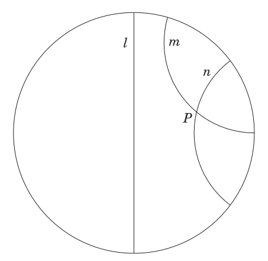

**图 18** 平行公理的失效。

**Figure 18** Failure of the parallel axiom.

当然，也存在平行公理*确实*成立的模型，因此我们看到，该公理*独立于*其他公理，并且可以替换为断言存在多条平行线的非欧平行公理，而不必担心矛盾。这一发现——数学中的第一个独立性证明——的直接影响，是人们更加不信任以欧几里得几何作为数学的基础，而更加支持算术。事实上，正如我们将在下一节看到的，一种基于实向量空间的几何的算术方法已经准备就绪，尽管很少有数学家准备好去理解它。

Of course, there are models in which the parallel axiom *does* hold, so we see that the axiom is *independent* of the other axioms, and it can be replaced by the non-Euclidean parallel axiom, stating the existence of multiple parallels, without fear of contradiction. The immediate effect of this discovery – the first independence proof in mathematics – was increased distrust of Euclid’s geometry as a foundation of mathematics, and increased support for arithmetic. In fact, as we will see in the next section, an arithmetic approach to geometry based on real vector spaces was ready to be rolled out, though few mathematicians were ready to understand it.

当然，分析的算术化正在赢得支持。由于魏尔斯特拉斯的影响——他于 1864 年独立于戴德金提出了实数的算术定义——关于连续函数的基本定理（从而代数基本定理）的算术证明在 1870 年代开始流传。

Certainly, arithmetization of analysis was gaining support. Thanks to the influence of Weierstrass, who had proposed an arithmetic definition of real numbers independently of Dedekind in 1864, arithmetical proofs of the basic theorems on continuous functions (and hence of the fundamental theorem of algebra) began to circulate in the 1870s.

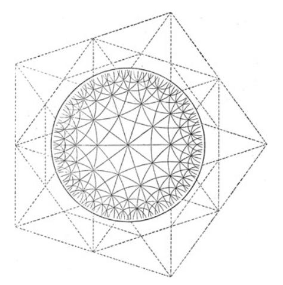

**图 19** 施瓦茨镶嵌。

**Figure 19** The Schwarz tessellation.

另一个引人注目的发现，是庞加莱和克莱因在 1880 年代发现：非欧几何*早已*存在于数学之中。他们注意到，复数单位圆盘上函数的行为具有非欧的周期性，而这一现象早先已被高斯、黎曼和施瓦茨观察到，只是他们没有意识到它的几何意义。施瓦茨（1872）甚至画出了一幅圆盘图（图 19），它正是共形圆盘模型被全等的非欧三角形所作的镶嵌！

Another remarkable discovery, by Poincaré and Klein in the 1880s, was that non-Euclidean geometry was *already present* in mathematics. They noticed that there was non-Euclidean periodicity in the behaviour of functions on the unit disc of complex numbers, and that the phenomenon had been observed earlier, by Gauss, Riemann, and Schwarz, without realizing its geometric significance. Schwarz (1872) even produced a diagram (Figure 19) of the disc that is none other than a tessellation of the conformal disc model by congruent non-Euclidean triangles!

这些发现巩固了非欧几何在数学中的地位，事实上也巩固了它在复数算术中的地位。

These discoveries cemented the position of non-Euclidean geometry in mathematics, and indeed in the arithmetic of complex numbers.

在几何之外，平行公理的独立性预示了数学中的其他独立性证明。在一个句子 $σ$ 不知道是否为公理集 $Σ$ 的推论的情况下，人们可能希望通过找到 $Σ$ 的两个模型来证明 $σ$ *独立于* $Σ$：一个满足 $σ$，另一个满足 $σ$ 的否定。我们稍后会提到一些例子。

Outside geometry, the independence of the parallel axiom foreshadowed other independence proofs in mathematics. In cases where a sentence $σ$ is not known to be a consequence of axioms $Σ$, one might hope to prove $σ$ *independent* of $Σ$ by finding two models of $Σ$: one satisfying $σ$ and the other satisfying the negation of $σ$. We will mention examples later.

平行公理的独立性也是*逆数学*的先声；逆数学是这样一个分支，人们在其中寻找证明某个给定定理的“正确公理”。平行公理是证明（比如说）勾股定理的正确公理，因为二者是等价的——在给定欧几里得其他公理的前提下——但仅凭这些公理，二者都无法证明。事实上，平行公理正是证明那一大批定理的正确公理，这些定理在平行公理的独立性被认识之前，就已被证明与平行公理等价。

The independence of the parallel axiom was also a harbinger of *reverse mathematics*, a branch in which one seeks the ‘right axiom’ to prove a given theorem. The parallel axiom is the right axiom to prove, say, the Pythagorean theorem because the two are equivalent – given Euclid’s other axioms – but neither can be proved from these axioms alone. Indeed, the parallel axiom is the right axiom to prove the host of theorems shown to be equivalent to the parallel axiom before its independence was known.

正如我们将在第 9 节看到的，独立性现象成为二十世纪数学中的一个重大课题，改变了我们思考真理与证明的方式。

As we will see in Section 9, the phenomenon of independence became a big story in twentieth-century mathematics, changing the way we think about truth and proof.

## 6.4 几何的算术化

## 6.4 Arithmetization of Geometry

在一本名为《扩张论》（*Die Ausdehnungslehre*）的不为人知的出版物中，格拉斯曼（1844）引入了一种革命性的几何方法，其基础就是我们今天所说的*实向量空间*。遗憾的是，格拉斯曼的写作风格对他的同时代人来说艰涩难懂，即使他在 1847 年发表了一个强调内积作用的简化版本也是如此。第一个欣赏他工作的人是皮亚诺（1888），他给出了实向量空间的一个公理系统，这是最早的现代公理系统之一。有趣的是，格拉斯曼把这一思想的萌芽归功于莱布尼茨 1679 年的一份名为《几何特征》（*Characteristica Geometrica*）的简略手稿。如果格拉斯曼真的在《几何特征》中看到了向量空间，那他是唯一这样做的人（其他人认为《几何特征》预示的是组合拓扑这一截然不同的学科）。至少，格拉斯曼应得的主要功劳在于认识到向量空间的概念，并看出必须添加什么才能使它真正具有几何性。

In an obscure publication called *Die Ausdehnungslehre* (extension theory), Grassmann (1844) introduced a revolutionary approach to geometry, based on what we now call *real vector spaces*. Unfortunately, Grassmann’s style was impenetrable to his contemporaries, even when he published a simplified version in 1847, emphasizing the role of the inner product. The first to appreciate his work was Peano (1888), who gave an axiom system for real vector spaces, one of the first modern axiom systems. Interestingly, Grassmann credited the germ of the idea to a sketchy manuscript of Leibniz from 1679 called *Characteristica Geometrica*. If Grassmann really saw vector spaces in the *Characteristica* he was the only one to do so (others have thought that the *Characteristica* foreshadows the very different subject of combinatorial topology). At the very least, Grassmann deserves most of the credit for recognizing the vector space concept, and for seeing what must be added to make it truly geometric.

今天，我们在数学中处处都能看到向量空间，因此大多数数学家都熟悉其基本思想。有一个集合 $V$，其中的对象称为*向量*，它们可以乘以实数，也可以相加。其中包括一个零向量 $0$，并且对每个向量 $a$，有一个向量 $−a$，称为 $a$ 的*负向量*。向量受以下公理支配。第一组公理说，向量和 $+$ 的行为与普通的和一样；即对 $V$ 中任意的 $u,v,w$：

Today we see vector spaces all over mathematics, so most mathematicians are familiar with the basic ideas. There is a set $V$ of objects called *vectors*, which can be multiplied by real numbers and added. They include a zero vector $0$ and, for each vector $a$ a vector $−a$ called the *negative* of $a$. Vectors are governed by the following axioms. The first group say that the vector sum $+$ behaves like ordinary sum; that is, for any $u,v,w$ in $V$:

$$u+v=v+u,u+(v+w)=(u+v)+w,u+0=u,u+(−u)=0.$$

第二组公理说，向量的倍数的行为与数的倍数一样；即对 $ℝ$ 中任意的 $a,b$ 和 $V$ 中任意的 $u,v$：

And the second group say that multiples of vectors behave like multiples of numbers; that is, for any $a,b$ in $ℝ$ and $u,v$ in $V$,

$$a(bu)=(ab)u,1u=u,a(u+v)=au+av,(a+b)u=au+bu.$$

由这些公理显然可知 $ℝ$ 本身就是一个实向量空间，但一个更有趣的例子是 $V=ℝ2$，其中向量 $(x,y)$ 的和与倍数，对每个 $x,y,a∈ℝ$，定义为

It is clear from these axioms that $ℝ$ itself is a real vector space, but a more interesting example is $V=ℝ2$, with sums and multiples of the vectors $(x,y)$ defined, for each $x,y,a∈ℝ$, by

$$(x1,y1)+(x2,y2)=(x1+x2,y1+y2)a(x,y)=(ax,ay).$$

$ℝ2$ 具有相当多的几何内容。人们可以定义直线、平行线，以及沿给定直线的相对长度概念。例如，可以说非零向量 $v$ 的倍数 $tv$ 构成一条经过 $0$ 的直线，并且 $2v$ 到 $0$ 的距离是 $v$ 的两倍。然而，任意两点之间并没有距离的概念。为了得到自然的距离概念，格拉斯曼引入了*内积*：

$ℝ2$ has considerable geometric content. One can define lines, parallel lines, and a relative concept of length along a given line. For example, one can say that the multiples $tv$ of a non-zero vector $v$ form a line through $0$, and that $2v$ is twice as far from $0$ as $v$. However, there is no concept of distance between arbitrary points. To obtain the natural concept of distance, Grassmann introduced the *inner product*:

$$(x1,y1)⋅(x2,y2)=x1x2+y1y2.$$

由这个定义可知，若 $v=(x,y)$，则

From this definition it follows that if $v=(x,y)$, then

$$v⋅v=x2+y2=|v|2,$$

其中 $|v|$ 是由勾股定理给出的 $v$ 到原点 $0$ 的距离。正如格拉斯曼（1847）所指出的，他的内积本质上等价于勾股定理。角的概念也内含于内积之中，因为

where $|v|$ is the distance of $|v|$ from the origin $0$ given by the Pythagorean theorem. As Grassmann (1847) pointed out, his inner product is essentially equivalent to the Pythagorean theorem. The concept of angle is also inherent in the inner product, because

$$u⋅v=|u||v|cosθ,$$

其中 $θ$ 是从 $0$ 到 $u$ 和到 $v$ 的两条直线之间的夹角。

where $θ$ is the angle between the lines from $0$ to $u$ and $v$.

（注：PDF 原文作“the distance of |**v**| from the origin”，按文意应指 **v** 到原点的距离；英文保留原文。）

(Note: the PDF reads “the distance of |**v**| from the origin”; the sense is the distance of **v** from the origin. The English is kept as printed.)

## 6.5 向量几何

## 6.5 Vector Geometry

上一节表明，笛卡尔的平面（第 4.2 节）——其中的点是实数 $x,y$ 的有序对 $(x,y)$，距离由勾股定理给出——与带有格拉斯曼内积的向量空间 $ℝ2$ 具有相同的要素。不同之处在于，笛卡尔的代数涉及 $x$ 和 $y$ 的任意多项式，远远超出了欧几里得。格拉斯曼的向量空间 $ℝ2$ 的代数只涉及向量的和与实数倍以及内积，恰好处在刻画欧几里得几何的正确层次上。因此，带有格拉斯曼内积的向量空间 $ℝ2$ 被称为*欧几里得平面*。

The previous section shows that the plane of Descartes (Section 4.2), in which points are ordered pairs $(x,y)$ of reals $x,y$ and distance is given by the Pythagorean theorem, has the same ingredients as the vector space $ℝ2$ with Grassmann’s inner product. The difference is that the algebra of Descartes, which involves arbitrary polynomials in $x$ and $y$, goes much further than Euclid. Grassmann’s algebra of the vector space $ℝ2$, involving only sums and real multiples of vectors, and the inner product, is at just the right level to capture Euclid’s geometry. For this reason, the vector space $ℝ2$ with Grassmann’s inner product is called the *Euclidean plane*.

格拉斯曼的向量几何还可以毫不费力地推广到任意维数。通过处理实数的 $n$ 元组 $(x1,x2,…,xn)$，人们可以在任意维数中研究几何，而无须借助可视化，从而突破了曾经束缚希腊人的维数障碍。

Grassmann’s vector geometry also generalizes to any number of dimensions with no extra effort. By working with $n$-tuples $(x1,x2,…,xn)$ of real numbers, one can do geometry in any number of dimensions without the need for visualization, thus breaking the dimension barrier that held back the Greeks.

在另一个方向上，通过推广内积的概念来推广“距离”的定义是很有用的。一个著名的例子是*闵可夫斯基空间*，它由闵可夫斯基（1908）定义，作为爱因斯坦狭义相对论的框架。这是由 4 元组 $(t,x,y,z)$ 构成的空间 $ℝ4$，其距离由如下内积导出：

In another direction, it is useful to generalize the definition of ‘distance’ by generalizing the concept of inner product. A famous example is *Minkowski space* defined by Minkowski (1908) as a setting for Einstein’s special theory of relativity. This is the space $ℝ4$ of 4-tuples $(t,x,y,z)$ with distance derived from the inner product

$$(t1,x1,y1,z1)⋅(t2,x2,y2,z2)=−t1t2+x1x2+y1y2+z1z2.$$

因此，$(t,x,y,z)$ 到原点的闵可夫斯基距离的平方等于 $−t2+x2+y2+z2$，它有时是负的。闵可夫斯基空间是物理学的自然空间，其中 $t$ 代表时间，$x,y,z$ 是空间三个维度的变量。但在数学上，考察去掉 $z$ 坐标所得的三维空间同样有趣。

Thus the Minkowski distance of $(t,x,y,z)$ from the origin has square equal to $−t2+x2+y2+z2$, which is sometimes negative. Minkowski space is the natural space for physics, where $t$ stands for time and $x,y,z$ are variables for the three dimensions of space. But mathematically it is equally interesting to look at the 3-dimensional space obtained by dropping the $z$ coordinate.

在这个空间中有一个“半径为 $−1$ 的球面”，它由满足 $|v|2=−1$ 的点 $v=(t,x,y)$ 组成，即

In this space there is a ‘sphere of radius $−1$’, consisting of the points $v=(t,x,y)$ with $|v|2=−1$, that is

$$−t2+x2+y2=−1;or / 即t2−x2−y2=1.$$

这正是图 20 所示的双曲面。就闵可夫斯基距离而言，这个双曲面上的几何正是贝尔特拉米的非欧几何！在图 20 中（依据柏林自由大学康拉德·波尔蒂尔的一幅图），我们标示了共形圆盘模型（图 17）中的三角形如何对应于双曲面上在闵可夫斯基距离意义下相等的三角形。

This is none other than the hyperboloid, shown in Figure 20. In terms of Minkowski distance, the geometry on this hyperboloid is none other the non-Euclidean geometry of Beltrami! In Figure 20 (based on one due to Konrad Polthier of the Free University of Berlin) we have indicated how triangles in conformal disc model (Figure 17) correspond to triangles on the hyperboloid that are equal in the sense of Minkowski distance.

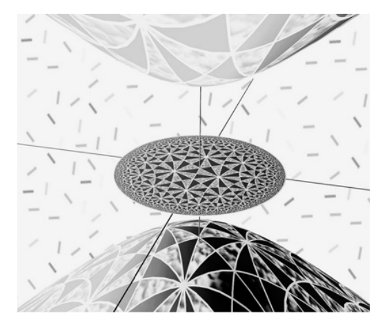

**图 20** 非欧几何的双曲面模型。

**Figure 20** The hyperboloid model of non-Euclidean geometry.

闵可夫斯基空间为兰伯特早在 1766 年提出的大胆想法（见第 4.5 节）提供了实质内容：非欧几何也许在一个虚半径的球面上成立。

Minkowski space gives substance to the wild idea of Lambert from back in 1766 (mentioned in Section 4.5), that non-Euclidean geometry might hold on a sphere of imaginary radius.

欧几里得空间与闵可夫斯基空间表明，$ℝ$ 是几何（无论欧氏的还是非欧的）的自然而便利的基础。下一个问题是：$ℝ$ 的基础是什么？在第 8 节中，我们将看到对这个问题的两种回答。但首先，我们需要在第 7 节中更仔细地审视 $ℝ$ 本身，以体会它的基础可能是多么微妙。

Euclidean and Minkowski spaces show that $ℝ$ is a natural and convenient foundation for geometry, both Euclidean and non-Euclidean. The next question is: what is a foundation for $ℝ$? In Section 8 we will see two answers to this question. But first we need to take a closer look at $ℝ$ itself, in Section 7, to appreciate how subtle its foundation may be.

## 6.6 哲学问题

## 6.6 Philosophical Issues

贝尔特拉米对非欧几何建模的关键一步，是他决定推广长度的概念。他之所以敢于这样做，是受到了他对黎曼（1854）的阅读的鼓舞；那是一部关于几何基础的开创性著作，首次发表于 1868 年。在一种全新的、影响深远的几何方法（今称*黎曼几何*）中，黎曼把笛卡尔的算术化几何从平面推广到任意维数 $n$ 的弯曲空间。空间的点不再用有序数对表示，而是用有序 $n$ 元组 $(x1,x2,…,xn)$ 表示。距离不再由“勾股”公式给出，而是由“无穷小勾股”公式借助微积分得到。“无穷小勾股”性质意味着：空间的几何（例如由三角形内角和所显示的）在小区域内趋近于欧氏几何，但在大区域内可能偏离它。一个例子是球面上的几何，其中小三角形的内角和接近 $π$，而大三角形的内角和则远大于 $π$。

A key step in Beltrami’s modelling of non-Euclidean geometry was his decision to generalize the concept of length. He was emboldened to do this by his reading of Riemann (1854), a ground-breaking work in the foundations of geometry that was first published in 1868. In a sweeping new approach to geometry (now known as *Riemannian geometry*), Riemann generalized the arithmetized geometry of Descartes from the plane to curved spaces of any dimension $n$. The points of the space, instead of being represented by ordered pairs of numbers, were represented by ordered $n$-tuples $(x1,x2,…,xn)$. And distance, instead of being given by the ‘Pythagorean’ formula, was obtained by calculus from an ‘infinitesimal Pythagorean’ formula. The ‘infinitesimal Pythagorean’ property means that the geometry of the space (as manifested by the angle sum of a triangle, for example) approaches Euclidean geometry in small regions, but may diverge from it in large regions. An example is the geometry of the sphere, where small triangles have angle sum close to $π$, but large triangles have angle sum much greater than $π$.

球面是常正曲率空间的一个例子。黎曼曾简略地考察过常负曲率空间，但发现这类空间呈现非欧几何、并且其“直线”（长度最短的曲线）可以简单地用圆弧来建模（如图 17 所示）的，是贝尔特拉米。因此，黎曼几何是对几何的彻底算术化，为欧氏几何、非欧几何以及各种弯曲几何指明了算术基础的方向。

The sphere is an example of a space with constant positive curvature. Riemann looked briefly at spaces of constant negative curvature, but it was Beltrami who noticed that such spaces exhibit non-Euclidean geometry, and that their ‘lines’ (curves of shortest length) can be modelled simply by circular arcs, as in Figure 17. Thus Riemannian geometry is a thoroughgoing arithmetization of geometry, pointing the way to an arithmetic basis for Euclidean, non-Euclidean, and all kinds of curved geometries.

黎曼和贝尔特拉米所带来的革命，引发了关于几何的本性及其在数学中的地位的若干问题。

The revolution wrought by Riemann and Beltrami raised several issues about the nature of geometry and its place in mathematics.

**直觉与逻辑。**模型表明，欧氏几何与非欧几何同样可靠，而实数为二者提供了基础（也为微积分和数学物理提供了基础）。剩下的就是为实数找到一个好的基础；但愿它能建立在自然数的算术之上。正如我们所知，戴德金找到了一种做到这一点的方法（第 5.3 节）。

**Intuition and logic.** Models show that Euclidean and non-Euclidean geometries are equally sound, and the real numbers provide a foundation for both (and also for calculus and mathematical physics). It remains to find a good foundation for the real numbers; hopefully based on the arithmetic of natural numbers. As we know, Dedekind found one way to do this (Section 5.3).

**意义与存在。**但实数所涉及的不只是算术；它还涉及某种关于无穷的假设。有多少假设是必要的、又有多少是正当的？

**Meaning and existence.** But the real numbers involve more than arithmetic; namely, some assumption about infinity. How much is it necessary, and legitimate, to assume?

**离散与连续。**弥合离散与连续之间的鸿沟，本质上就是用自然数来定义实数的问题。因此，弥合这道鸿沟（以及把几何算术化）的可能性，取决于对无穷作出何种假设才是正当的。

**Discrete and continuous.** Bridging the gap between discrete and continuous is essentially the problem of defining real numbers in terms of natural numbers. Hence the possibility of bridging the gap (and arithmetizing geometry) depends on what it is legitimate to assume about infinity.

# 7 集合论及其悖论

# 7 Set Theory and Its Paradoxes

### 预览

### PREVIEW

戴德金对实数的定义开启了数学思想的一个新时代，在这个时代里，无穷集合被视为数学对象。这不受许多数学家欢迎，他们秉持实无穷不可接受的古老观点。事实上，在某些圈子里，对实无穷的抵制一直持续到今天。

Dedekind’s definition of real numbers opened a new era in mathematical thought, in which infinite sets were viewed as mathematical objects. This was unwelcome to many mathematicians, who took the ancient view that actual infinity was unacceptable. Indeed, in some quarters, resistance to actual infinity continues to this day.

更不受欢迎的是康托尔（1874）的发现：实数构成一个*不可数*集合——它无法被巧妙地当作仅仅是潜无穷而非实无穷来处理。

Even more unwelcome was the discovery of Cantor (1874) that the real numbers form an *uncountable* set – one that cannot be finessed as a merely potential infinity rather than actual.

但不可数性还不是最后一根稻草。康托尔（1891）找到了他的论证的一个简单推广，表明不存在最大的集合。事实上，对任何集合 $S$，$S$ 的子集都比 $S$ 的元素多。由此可知，不存在“所有集合的集合”，因而并非每个性质都由某个集合来实现。特别地，不存在实现“$X$ 是一个集合”这一性质的集合。就连戴德金也为这一发展感到不安。

But uncountability was not the last straw. Cantor (1891) found a simple generalization of his argument that shows there is no largest set. Indeed, for any set $S$, the subsets of $S$ are more numerous than members of $S$. It follows that there is no ‘set of all sets’ and therefore not every property is realized by a set. In particular, there is no set that realizes the property ‘$X$ is a set’. Even Dedekind was worried by this development.

## 7.1 康托尔之前

## 7.1 Before Cantor

我们在第 2.3 节提到过希腊人对无穷心存疑虑，并解释了他们如何尽可能地回避它。尽管如此，希腊人确实使用了无穷过程，而且用得非常巧妙。他们在实践中的回避，意味着只考虑一个无穷整体或无穷过程的任意有限部分——即“潜”无穷而非“实”无穷。

In Section 2.3 we mentioned that the Greeks were suspicious of infinity, and explained how they avoided it as far as possible. Nevertheless, the Greeks certainly used infinite processes, and very ingeniously at that. Their avoidance in practice meant considering arbitrary finite parts of an infinite totality or process – the ‘potential’ rather than the ‘actual’ infinite.

实无穷之所以被回避，是因为它具有看似悖论的性质，例如它似乎违反了“整体大于部分”这一原则。随着希腊学术在中世纪和文艺复兴时期的复兴，这一悖论重新浮现。例如，伽利略指出了如下对应：

The actual infinite was avoided because of its seemingly paradoxical properties, such as apparent violation of the principle that ‘the whole is greater than the part’. This paradox resurfaced with the revival of Greek learning in Medieval and Renaissance times. For example, Galileo pointed out the correspondence

$$1234…↕↕↕↕↕12223242…$$

它似乎表明，正整数的整体并不比由平方数构成的那一部分更大。

which seemingly shows the whole collection of positive integers to be no greater than its part consisting of squares.

直到十九世纪末，这种关系——某个集合的一部分与其整体之间的一一对应——一直被认为是悖论性的。但最终，一一对应被视为比较无穷集合的正确方式。事实上，戴德金（1888）把“其整体能与其一部分建立一一对应”作为无穷集合的*定义性*性质，从而把一个悖论变成了一个定义。能够彼此建立一一对应的两个集合称为*等势的*，或具有*相同的基数*。

Until the late nineteenth century this kind of relationship – a one-to-one correspondence between a part and the whole of some collection – was considered paradoxical. But eventually one-to-one correspondence came to be seen as the right way to compare infinite sets. Indeed, Dedekind (1888) took the *defining* property of an infinite set to be that its whole can be put in one-to-one correspondence with a part, thus turning a paradox into a definition. Two sets that can be put in one-to-one correspondence with one another are called *equinumerous* or of the *same cardinality*.

许多集合与正整数集 $ℕ$ 等势。例如：

Many sets are equinumerous with the set $ℕ$ of positive integers. For example:

1. 全体整数之集 $ℤ$，通过如下对应与 $ℕ$ 等势：$1234567…↕↕↕↕↕↕↕↕01−12−23−3…$
2. 正有理数之集 $ℚ+$，通过如下对应：$123456789…↕↕↕↕↕↕↕↕↕↕1/12/11/23/11/34/13/22/31/4…$其中下面一行按组列出互不相同的分数 $m/n$：先是 $m+n=2$ 的，然后是 $m+n=3$ 的，再是 $m+n=4$ 的，依此类推。
3. 于是，用列出 $ℤ$ 的同一技巧，可以证明全体有理数之集 $ℚ$ 与 $ℕ$ 等势：先列出 0，然后对每个正有理数交替列出它的正形式和负形式。
1. The set $ℤ$ of all integers, equinumerous with $ℕ$ via the correspondence$1234567…↕↕↕↕↕↕↕↕01−12−23−3…$
2. The $ℚ+$ of positive rationals, via the correspondence$123456789…↕↕↕↕↕↕↕↕↕↕1/12/11/23/11/34/13/22/31/4…$where the bottom line lists the distinct fractions $m/n$ in groups: first those with $m+n=2$, then those with $m+n=3$, those with $m+n=4$, and so on.
3. The set $ℚ$ of all rationals can then be shown equinumerous with $ℕ$ by the same trick used to list $ℤ$: list 0 first, then alternately list the positive and negative form of each positive rational.

这些结果表明，$ℤ$、$ℚ+$ 和 $ℚ$ 都可以像 $ℕ$ 一样被看作“潜”无穷。戴德金在 1874 年沿着同一思路得到了一个更强的结果：全体*代数数*（整系数多项式方程的解）之集与 $ℕ$ 等势。因此它也可以被看作“潜”无穷。有了这些结果，关于实无穷的大多数古老恐惧都可以打消了——因为似乎每一种无穷都只是“潜”无穷——但一个巨大的意外就在眼前。

These results show that $ℤ$, $ℚ+$, and $ℚ$ can all be viewed as ‘potential’ infinities like $ℕ$. An even stronger result along the same lines was found by Dedekind in 1874: the set of all *algebraic numbers* (solutions of polynomial equations with integer coefficients) is equinumerous with $ℕ$. So it too can be viewed as a ‘potential’ infinity. With these results most of the ancient fears about actual infinity could be dismissed – because every infinity seemed to be merely ‘potential’ – but there was a big surprise just around the corner.

## 7.2 康托尔的对角线论证

## 7.2 Cantor’s Diagonal Argument

康托尔（1874）证明了实数与正整数*不*等势。也就是说，正整数与实数的任何配对

Cantor (1874) proved that the real numbers are *not* equinumerous with the positive integers. That is, any pairing of positive integers with real numbers,

$$1234567…↕↕↕↕↕↕↕↕x1x2x3x4x5x6x7,$$

都不能包含所有实数。事实上，给定任何实数列 $x1,x2,x3,x4,…$，我们都可以明确地描述一个不在该列中的实数 $x$。1874 年的证明不易理解——尤其是对一个对此毫无准备的数学界来说——但康托尔（1891）给出了另一个证明，以最大的清晰度得到了“见证” $x$。这就是著名的（或者在某些人看来，臭名昭著的）*对角线论证*。

fails to include all the real numbers. In fact, given any list $x1,x2,x3,x4,…$ of real numbers we can explicitly describe a real number $x$ not on the list. The 1874 proof was not easy to follow – especially for a mathematical community completely unprepared for it – but Cantor (1891) gave another proof which obtains the ‘witness’ $x$ with maximum clarity. This is the famous (or, to some, notorious) *diagonal argument*.

实数 $x1,x2,x3,x4,…$ 可以有许多种给出方式，但为具体起见，我们假定它们以无限小数的形式给出。我们还忽略小数点前的数字，因此可以想象这些数如图 21 那样排列，只显示小数点后的数字：

There are many ways in which the real numbers $x1,x2,x3,x4,…$ can be given, but to be specific we will suppose they are given as infinite decimals. We will also ignore digits before the decimal point, so we can imagine the numbers displayed as in Figure 21, showing just the digits after the decimal point:

$$x11111…x20201…x37777…x40000…⋮x2111…$$

**图 21** 对角线构造。

**Figure 21** The diagonal construction.

图 21 还显示了 $x$ 的前几位数字。我们通过使 $x$ 在第 $n$ 位小数上与 $xn$ 不同，来保证对每个 $xn$ 都有 $x≠xn$（并且在 $x$ 中不使用数字 0 和 9，因为含有这些数字的数即使数字不同也可能相等——例如 $0.4999…=0.5000…$）。具体地，我们定义 $x$ 为

Figure 21 also shows the first few digits of $x$. We ensure that $x≠each xn$ by being different in the $n$th decimal place (and not using the digits 0 and 9 in $x$, because numbers with these digits can be the same even though their digits are different – for example $0.4999…=0.5000…$). Specifically, we define $x$ by

$$第 n 位 / nth digit of x={2若 xn 的第 n 位为 1 / if nth digit of xn is 11若 xn 的第 n 位不为 1 / if nth digit of xn is not 1.$$

因此 $x$ 与所有数 $x1,x2,x3,x4,…$ 都不同，从而给定的数列不包含所有实数。正因如此，我们说全体实数之集是*不可数的*——*可数*集合是指其元素能与正整数配对的集合。

Thus $x$ is different from all the numbers $x1,x2,x3,x4,…$, hence the given list does not include all real numbers. Because of this, we say that the set of all real numbers is *uncountable* – a *countable* set being one whose members can be paired with the positive integers.

由于只有可数集合才能被看作“潜”无穷，实数集 $ℝ$ 不可避免地是一个*实*无穷。

Since only countable sets can be considered ‘potentially’ infinite, the set $ℝ$ of real numbers is unavoidably an *actual* infinity.

康托尔的论证之所以称为“对角线”论证，是因为它只涉及表格对角线上的数字，即图中以粗体显示的数字。因此，为了计算 $x$ 的第 $n$ 位数字，我们只需检查每个小数展开式的有限部分——即 $xn$ 的前 $n$ 位数字。我提到这一点，是为了消除一种常见的误解，即认为对角线论证仅仅证明了存在一个不在给定数列 $x1,x2,x3,x4,…$ 中的数 $x$。事实上，它表明 $x$ 与数 $x1,x2,x3,x4,…$ 本身同样是可构造的。

Cantor’s argument is called ‘diagonal’ because it involves just the digits on the diagonal of the table, shown in bold in the figure. Thus we need only inspect a finite amount of each decimal expansion – namely, the first $n$ digits of $xn$ – to calculate the $n$th digit of $x$. I mention this to dispel the common misconception that the diagonal argument merely proves the *existence* of a number $x$ not on the given list $x1,x2,x3,x4,…$. In fact it shows that $x$ is just as constructible as the numbers $x1,x2,x3,x4,…$ themselves.

## 7.3 更高的无穷

## 7.3 Higher Infinities

对角线论证的本质在于：给定与每个自然数 $n$ 配对的实数 $xn$，我们可以按如下规则定义一个实数 $x$，使得对每个 $xn$ 都有 $x≠xn$：

The essence of the diagonal argument is to say: given a real number $xn$ paired with each natural number $n$, we can define a real number $x≠each xn$ by the rule

$$第 n 位 / nth digit of x={2若 xn 的第 n 位为 1 / if nth digit of xn is 11若 xn 的第 n 位不为 1 / if nth digit of xn is not 1,$$

因为这使得 $x$ 在第 $n$ 位小数上与 $xn$ 不同。类似的论证表明，不可能存在 $ℕ$ 的所有子集的列表 $S1,S2,S3,S4,…$。因为对任何这样的列表，我们都可以按如下规则定义一个集合 $S$，使得对每个 $Sn$ 都有 $S≠Sn$：

because this makes $x≠xn$ in the $n$th decimal place. A similar argument shows that there can be no list $S1,S2,S3,S4,…$ of all subsets of $ℕ$. Because for any such list we can define a set $S≠each Sn$ by the rule

$$n∈S⇔n∉Sn,$$

因为这一规则使 $S$ 在数 $n$ 处与 $Sn$ 不同。

since this rule makes $S$ different from $Sn$ with respect to the number $n$.

在他 1891 年的论文中，康托尔把这一思路推进到了尽头，证明了*每个集合 $X$ 的子集都比元素多*。为了看出原因，假设 $X$ 的每个元素 $x$ 都与 $S$ 的一个子集 $Sx$ 配对。那么我们可以定义 $X$ 的一个子集 $S$，它在元素 $x$ 处与每个 $Sx$ 都不同。即令

In his 1891 paper Cantor took this train of thought to the end of the line, showing that *every set $X$ has more subsets than members*. To see why, suppose that each member $x$ of $X$ is paired with a subset $Sx$ of $S$. But then we can define a subset $S$ of $X$ different from each $Sx$ with respect to the member $x$. Namely, let

$$x∈S⇔x∉Sx.$$

因此，与 $X$ 的元素 $x$ 配对的子集 $Sx$ 的全体，并不包含 $X$ 的所有子集。

Thus a collection of subsets $Sx$ paired with members $x$ of $X$ does not include all subsets of $X$.

（注：PDF 原文作“paired with a subset S<sub>x</sub> of S”，按文意应为 $X$ 的子集；英文保留原文。）

(Note: the PDF reads “paired with a subset S<sub>x</sub> of S”; the sense is a subset of $X$. The English is kept as printed.)

这一结果有些令人不安之处在于，它表明不存在*所有集合的集合*。如果存在这样一个集合，比如说 $X$，那么它的子集的全体就会是一个比所有集合的集合还大的集合，这显然是矛盾的。康托尔很快注意到对角线论证的这一推论，但他保持了冷静。（然而，戴德金对这一发展感到意外，并因此推迟了他的著作戴德金［1888］第二版的出版。）历史将会表明，所有集合的全体不是一个集合是很自然的，正如所有正整数的全体不是一个正整数是很自然的一样。然而在当时，由于先前人们相信每个性质都应由某个集合来实现，因而引起了恐慌。在康托尔的发现之后，很清楚这一信念有例外，例如“是一个集合”这一性质。

What is slightly alarming about this result is that it shows that there is *no set of all sets*. If there were such a set, $X$ say, then the collection of its subsets would be a set bigger than the set of all sets, which is clearly contradictory. Cantor soon noticed this consequence of the diagonal argument, but he remained calm. (Dedekind, however, was surprised by this development, and he delayed publication of a second edition of his book Dedekind [1888] as a result.) History would show that it is natural for the collection of all sets not to be a set, much as it is natural for the collection of all positive integers not to be a positive integer. However, at the time there was alarm because of a previous belief that every property should be realized by a set. After Cantor’s discovery, it was clear that there are exceptions to this belief, such as the property of being a set.

## 7.4 对角线论证的余波

## 7.4 Aftermath of the Diagonal Argument

对角线论证是数学基础中的一个关键性发现。在一个方向上，它似乎不可阻挡地通向更高的无穷领域——也通向新的悖论。在另一个方向上，它导致了形式数学局限性的发现：不完全性与算法不可解性，我们将在接下来的两节中看到。它还激起了一类新的怀疑论者的反应，他们的怀疑不仅针对无穷，而且针对逻辑本身。

The diagonal argument was a pivotal discovery in the foundations of mathematics. In one direction it led, seemingly inexorably, to higher realms of infinity – and towards new kinds of paradox. In another direction it led to the discovery of limitations in formal mathematics: incompleteness and algorithmic unsolvability, as we will see in the next two sections. And it also provoked reaction from a new breed of sceptics, whose scepticism was directed not just at infinity but at logic itself.

康托尔发现不存在最大的集合、并非每个性质都由集合来实现，这导致了*集合论*的发展，即对一般无穷集合、特别是对 $ℝ$ 的系统研究。$ℝ$ 的不可数性仅仅是关于 $ℝ$ 的许多令人困惑的发现中的第一个，它们表明我们自以为了解的数轴比任何人想象的都要复杂。事实上，为了回答关于 $ℝ$ 的许多问题，我们不得不对整个集合宇宙作出假设。

Cantor’s discovery that there is no largest set, and that not every property is realized by a set, led to the development of *set theory*, a systematic study of infinite sets in general and $ℝ$ in particular. The uncountability of $ℝ$ was merely the first of many confounding discoveries about $ℝ$, showing that the number line we thought we knew is more complicated than anyone imagined. In fact, to answer many questions about $ℝ$ we have to make assumptions about the whole universe of sets.

另一方面，对角线论证简单且具有计算性的特点，使它可以应用于最朴实的“潜”无穷。例如，它表明不存在所有可计算数的可计算列表。因为如果 $x1,x2,x3,…$ 是可计算数的一个可计算列表，那么对角线数 $x$ 也是可计算的——而它不在列表中。这一结果对于在数学所有领域中什么是可计算的，具有深远的意义。

On the other hand, the simple and computational nature of the diagonal argument makes it applicable to the most down-to-earth ‘potential’ kinds of infinity. For example, it shows that there is no computable list of all computable numbers. Because if $x1,x2,x3,…$ is a computable list of computable numbers then the diagonal number $x$ is also computable – and it is not on the list. This result has profound implications for what can be computed, in all areas of mathematics.

毫不奇怪，对角线论证及其推论并不受所有数学家欢迎。那些本已对无穷心存疑虑的人，例如康托尔在柏林的同事克罗内克，更加激烈地反对 $ℝ$ 这样的集合。魏尔斯特拉斯较为同情，但他劝说康托尔淡化证明中的不可数性一面，转而强调一个正面的成果：对非代数数——即所谓的*超越数*——的存在性给出一个新的、初等的证明。（这由 $ℝ$ 的不可数性与戴德金关于代数数集可数的结果立即推出。）

Not surprisingly, the diagonal argument and its implications were not welcome to all mathematicians. Those already suspicious of infinity, such as Cantor’s Berlin colleague Kronecker, became even more vehement in their opposition to sets such as $ℝ$. Weierstrass was more sympathetic, but he persuaded Cantor to tone down the uncountability aspect of the proof and to emphasize instead a positive outcome: a new and elementary proof of the existence of non-algebraic numbers – the so-called *transcendental* numbers. (This follows immediately from the uncountability of $ℝ$ and Dedekind’s result that the set of algebraic numbers is countable.)

在随后的岁月里，由于希尔伯特等杰出数学家的支持，康托尔的思想逐渐赢得了大多数人的支持。一些反对仍然存在，但随着人们逐渐认识到，如果拒斥各种无穷，就不得不牺牲多少数学，这种反对变得更加微妙。在极端拒斥者中，最突出的是*构造主义者*，他们只在存在性证明提供了所声称存在的对象的构造时才接受它。这种态度甚至对不持这种态度的数学家也产生了积极影响。例如，我们现在知道如何构造许多对象，例如多项式方程的解，而这些对象最初是用非构造性论证证明其存在的。

In the years that followed, Cantor’s ideas gradually gained the support of the majority, thanks to the support of eminent mathematicians such as Hilbert. Some opposition remained, but it became more nuanced as it was gradually understood how much mathematics has to be sacrificed if various kinds of infinity are rejected. Among the extreme rejectionists, the most prominent are the *constructivists*, who accept existence proofs only when they provide a construction of the object claimed to exist. This attitude has had a positive influence even on mathematicians who do not share it. For example, we now know how to construct many objects, such as solutions of polynomial equations, first shown to exist by non-constructive arguments.

## 7.5 哲学问题

## 7.5 Philosophical Issues

也许值得一提的是，康托尔对 $ℝ$ 的不可数性的第一个证明也是一个对角线论证，只是形式不那么透明。它有相同的本质：逐步构造一个实数 $x$，并在第 $n$ 步使 $x$ 与实数 $xn$ 不同。然而，那个构造是专门针对实数的，因此康托尔（1891）所发现的向任意集合的惊人推广是新的。还有另一个专门针对 $ℝ$ 的不可数性证明，在我看来更有启发性。它是这样的。

It may be worth mentioning that Cantor’s first proof of the uncountability of $ℝ$ was also a diagonal argument, but in a less transparent form. It had the same essence: constructing a real number $x$ step by step and making $x$ different from the real number $xn$ at step $n$. However, the construction was specific to real numbers, so the spectacular generalization to arbitrary sets found by Cantor (1891) was new. There is another uncountability proof, specific to $ℝ$, which is more revealing in my opinion. It goes like this.

给定实数 $x1,x2,x3,…$，我们用一个长度为 $2−n$ 的区间覆盖每个 $xn$。那么被覆盖的数轴的总长度至多为

Given real numbers $x1,x2,x3,…$, we cover each $xn$ by an interval of length $2−n$. Then the total length of the number line covered is at most

$$12+14+18+…=1,$$

这显然不是整条直线。因此点 $x1,x2,x3,…$ 不可能包含所有实数。这个证明可以加以细化，给出一个未被覆盖的具体的数 $x$。我们选取 $x$ 的第一位（二进制）数字以避开第一个区间，再选取第二位数字以避开第二个区间，依此类推——到了这一步就很清楚，这个构造是另一个对角线论证。

which is surely not the whole line. So the points $x1,x2,x3,…$ cannot include all real numbers. This proof can be refined to give a specific number $x$ not covered. We choose the first (binary) digit of $x$ to avoid the first interval, then the second digit to avoid the second interval, and so on – at which stage it becomes clear that this construction is another diagonal argument.

事实上，还有另一条通向不可数性的道路，即通过康托尔的序数理论。这虽然很有趣，却引出了另一组问题，我们在此没有篇幅讨论。不可数集合的存在本身就已引出足够多的问题。

There is in fact another route to uncountability, through Cantor’s theory of ordinal numbers. Interesting though this is, it raises another set of issues that we do not have space to discuss here. The existence of uncountable sets raises enough issues on its own.

**直觉与逻辑。**人类可能在多大程度上理解无穷？戴德金（1888，§66）作了一次大胆的尝试，试图证明无穷集合存在（继波尔查诺 1851，§13 的类似尝试之后）。它基于这样一个事实：只有无穷集合才能与它自身的一个真子集等势：

**Intuition and logic.** How much understanding of infinity is humanly possible? Dedekind (1888, §66) made an audacious attempt to prove that infinite sets exist (following a similar attempt by Bolzano 1851, §13). It is based on the fact that only an infinite set can be equinumerous with a proper subset of itself:

> **定理。**存在无穷系统。

> **Theorem.** There exist infinite systems.

> **证明。**我自己的思想领域，即一切能够成为我的思想对象的事物的总体 $S$，是无穷的。因为如果 $s$ 表示 $S$ 的一个元素，那么“$s$ 能够成为我的思想对象”这一思想 $s′$ 本身也是 $S$ 的一个元素。如果我们把它看作元素 $s$ 的一个变换 $ϕ(s)$，那么由此确定的 $S$ 的变换 $ϕ$ 具有这样的性质：变换 $S′$ 是 $S$ 的一部分；并且 $S′$ 肯定是 $S$ 的真部分，因为 $S$ 中有一些元素……不包含在 $S′$ 中。

> **Proof.** My own realm of thoughts, i.e. the totality $S$ of all things which can be objects of my thought, is infinite. For if $s$ signifies an element of $S$, then is the thought $s′$, that $s$ can be an object of my thought, itself an element of $S$. If we regard this as a transform $ϕ(s)$ of the element $s$ then has the transformation $ϕ$ of $S$, thus determined, the property that the transform $S′$ is part of $S$; and $S′$ is certainly a proper part of $S$, because there are elements in $S$ … which are not contained in $S′$.

扫兴的人无疑会反驳说，戴德金一生中只有有限多个思想，所以这个“证明”一定有问题。但谁知道戴德金的思想领域究竟是什么呢？戴德金的论证有一些杰出的支持者，例如罗素（1903，357）。

Spoilsports will no doubt object that in his lifetime Dedekind had only a finite number of thoughts, so there must be something wrong with this ‘proof’. But who knows what the realm of Dedekind’s thoughts really is? Dedekind’s argument had some eminent supporters, such as Russell (1903, 357).

波尔查诺和戴德金只考虑了可数集合，但我们也可以争取不可数集合。我们对连续性的表面直觉，是不是对不可数性和／或实无穷的直觉？

Bolzano and Dedekind considered only countable sets, but we might also shoot for uncountable sets. Is our apparent intuition of continuity an intuition of uncountability and/or actual infinity?

**意义与存在。**在康托尔之前，无穷问题很简单：我们是否接受实无穷？在康托尔之后，问题变得更加复杂：我们接受*多少*无穷？当发现无穷有无穷多个可能的层次时，就可能有许多不同层次的接受。一些数学家只接受可数无穷集合（潜无穷），另一些接受 $ℝ$ 但不接受 $ℝ$ 的所有子集，如此等等。法国数学家博雷尔、贝尔、勒贝格和阿达马在 1905 年就此展开了一场热烈的辩论，可见于 Ewald（1996，II：1077–86）。博雷尔认为某些程序，例如作出不可数多次选择，是“在数学之外”的；对此，阿达马反驳道：

**Meaning and existence.** Before Cantor, the question of infinity was simple: do we accept actual infinity or not? After Cantor, the question became more complex: *how much* infinity do we accept? When infinity is found to have infinitely many possible levels, many different levels of acceptance are possible. Some mathematicians accepted only countably infinite sets (the potential infinite), others accepted $ℝ$ but not all subsets of $ℝ$, and so on. The French mathematicians Borel, Baire, Lebesgue, and Hadamard had a lively debate about this in 1905, which may be read in Ewald (1996, II: 1077–86). In response to Borel’s view that certain procedures, such as making uncountably many choices, were ‘outside mathematics’, Hadamard retorted:

> 在我看来，从无穷小微积分的发明到现在，数学的本质性进步都来自于相继吸纳那些对希腊人、文艺复兴时期的几何学家或黎曼的前辈们来说“在数学之外”的概念，因为当时无法描述它们。（见 Ewald 1996，1084）

> From the invention of the infinitesimal calculus to the present, it seems to me, the essential progress in mathematics has resulted from successively annexing notions which, for the Greeks or the Renaissance geometers or the predecessors of Riemann, were ‘outside mathematics’ because it was impossible to describe them. (see Ewald 1996, 1084)

**离散与连续。**$ℝ$ 的不可数性决定性地表明，涉及 $ℝ$ 的数学——例如分析——触及集合论。至少，几何与分析的算术化工程必须在纯算术之外走出相当一段距离：它必须包含一些关于无穷集合的假设。

**Discrete and continuous.** The uncountability of $ℝ$ conclusively shows that mathematics involving $ℝ$ – such as analysis – touches on set theory. At the very least, the project of arithmetizing geometry and analysis must go some distance beyond pure arithmetic: it must include some assumptions about infinite sets.

在下一节中，我们将考察算术的标准公理系统，并一瞥更远处的关于集合的公理。

In the next section we will look at the standard axiom system of arithmetic, and catch a glimpse of the axioms about sets that lie beyond.

# 8 形式系统

# 8 Formal Systems

### 预览

### PREVIEW

集合论及其悖论的突然出现，并不是十九世纪末数学中唯一具有哲学意义的发展。另一个是形式逻辑的出现，更一般地说，是数学形式系统的出现。从 1847 年布尔的《逻辑的数学分析》问世开始，逻辑和数学被翻译成符号体系，在其中演绎本质上就是计算。

The sudden appearance of set theory and its paradoxes was not the only philosophically significant development in late nineteenth-century mathematics. Another was the emergence of formal logic and, more generally, formal systems for mathematics. Beginning with appearance of Boole’s *Mathematical Analysis of Logic* in 1847, logic and mathematics were translated into symbolism in which deductions were essentially calculations.

一百年前，已知的可供形式化的系统有：算术的（皮亚诺 1889）、几何的（希尔伯特 1899）和集合论的（策梅洛 1908）。还有一个逻辑的形式系统，出自弗雷格（1879）。

A century ago, systems ready for formalization were known for arithmetic (Peano 1889), geometry (Hilbert 1899), and set theory (Zermelo 1908). There was also a formal system for logic, due to Frege (1879).

形式系统复活了莱布尼茨的一个古老梦想：一种*推理演算*（calculus ratiocinator），借助它，任何命题的真假都可以通过计算来判定。诚然，形式系统的定理可以通过计算得到，所以如果 $τ$ 是 $Σ$ 的一个定理，我们最终会通过系统地生成定理而观察到这一事实。然而，以下问题并不清楚：

Formal systems revived an old dream of Leibniz: a *calculus ratiocinator* by which the truth of any proposition could be decided by calculation. It is true that the theorems of a formal system $Σ$ are obtainable by calculation, so if $τ$ is a theorem of $Σ$ we will eventually observe this fact by systematically generating theorems. However, it is not clear whether

1. 所有可在 $Σ$ 中表达的真理是否都是定理；（完全性）
2. 是否有某条规则，能对每个 $τ$ 判定 $τ$ 是不是定理；（可判定性）
3. 如果 $Σ$ 证明了 $τ$，那么 $Σ$ 是否不会证明 $τ$ 的否定。（一致性）
1. all truths expressible in $Σ$ are theorems, (Completeness)
2. some rule decides, for each $τ$, whether $τ$ is a theorem, (Decidability)
3. if $Σ$ proves $τ$ then $Σ$ does not prove the negation of $τ$. (Consistency)

尽管如此，这些都是关于有限计算之结果的问题，就像数论中的问题一样。因此人们或许希望用初等手段（希尔伯特称之为“有穷的”）来解决它们。特别地，希尔伯特希望通过一个解决形式集合论一致性问题的纲领，消除对数学中使用无穷的一切疑虑。

Nevertheless, these are all questions about the outcomes of finite computations, like questions of number theory. So one might hope to settle them by elementary means (which Hilbert called ‘finitary’). In particular, by a programme for settling the consistency question for formal set theory, Hilbert hoped to remove all doubt about the use of infinity in mathematics.

## 8.1 希尔伯特

## 8.1 Hilbert

在 1890 年代，希尔伯特通过对几何公理及其与代数和实数之关系的透彻研究，使欧几里得几何重新焕发生机。在冯·施陶特和帕施等前辈工作的基础上，他

In the 1890s Hilbert reinvigorated Euclid’s geometry in a thorough study of geometric axioms and their relation to algebra and the real numbers. Building on work of some of his predecessors, such as von Staudt and Pasch, he

1. 通过明确陈述欧几里得不自觉地使用过的公理，填补了欧几里得体系中的空缺，
2. 把公理分成概念上不同的类型：关联、顺序、合同、圆的相交，
3. 从关联公理推出和与积的代数性质，从顺序公理推出它们的顺序性质，
4. 增加了两条几何本身不需要、但推出实数直线性质所需要的公理：阿基米德公理（断言不存在无穷小）和完备性公理（断言在戴德金的意义上没有空隙）。
1. filled the gaps in Euclid’s system, by explicitly stating axioms that Euclid had used unconsciously,
2. grouped the axioms into conceptually different types: incidence, order, congruence, circle intersection,
3. derived the algebraic properties of sum and product from incidence axioms, and their order properties from the order axioms,
4. added two axioms not needed for geometry but needed to derive the properties of the real number line: the Archimedean axiom (stating that there are no infinitesimals), and a completeness axiom (stating that there are no gaps, in the sense of Dedekind).

从纳入阿基米德公理和完备性公理可以明显看出，希尔伯特对实数的兴趣不亚于对几何的兴趣。事实上，在他 1899 年的著作《几何基础》（*Grundlagen der Geometrie*）中，他还给出了一个从非欧几何公理（通过替换平行公理而得到）出发构造 $ℝ$ 的巧妙新方法。

It is evident from the inclusion of Archimedean and completeness axioms that Hilbert was interested in the real numbers as much as he was interested in geometry. In fact, in his 1899 book *Grundlagen der Geometrie* (*Foundations of geometry*) he also included an ingenious new construction of $ℝ$ from the axioms of non-Euclidean geometry (obtained by replacing the parallel axiom).

从几何公理推导出 $ℝ$ 在数学中用得不多，但它对哲学作出了一个奇特的贡献。哈特里·菲尔德（1980）在他的《没有数的科学》中改造了希尔伯特的结果，从关于物理空间的公理推出实数的*结构*。他用这一推导主张 $ℝ$ 在科学中是可以免除的，因此任何人都无须假定它的存在。但对大多数数学家来说，假定 $ℝ$ 的结构存在（无论在物理空间中还是在任何抽象领域中）就等同于假定 $ℝ$ 本身存在。而仅仅为了避免假定 $ℝ$ 的存在，就假定物理空间是阿基米德的、完备的和欧几里得的，这似乎既违背物理学，也违背数学。

The derivation of $ℝ$ from geometric axioms has not been used much in mathematics, but it has made a curious contribution to philosophy. Hartry Field (1980), in his *Science without Numbers*, adapted Hilbert’s result to derive the *structure* of the real numbers from axioms about physical space. He used this derivation to claim that $ℝ$ is dispensable in science, and hence that no one need assume its existence. But, to most mathematicians, assuming that the structure of $ℝ$ exists (in physical space or in any abstract realm) is the same as assuming the existence of $ℝ$ itself. And assuming that physical space is archimedean, complete, and Euclidean – merely to avoid assuming the existence of $ℝ$ – seems to defy physics as much as it defies mathematics.

## 8.2 皮亚诺与策梅洛的系统

## 8.2 The Systems of Peano and Zermelo

在数学中，得到 $ℝ$ 的更常见方式是通过关于自然数和集合的公理。自然数的公理由戴德金（1888）和皮亚诺（1889）给出，这个系统今称*皮亚诺算术*，即 $PA$。皮亚诺承认格拉斯曼（1861）的一个思想：算术的关键概念是*归纳*。这里的“归纳”不是从特殊情形得出一般结论的粗略想法，而是对一般结论之正确性的铁的保证。这种归纳常被称为*完全归纳*，因为对于自然数，它涵盖了所有情形。

The more usual way to arrive at $ℝ$ in mathematics is through axioms for the natural numbers and sets. Axioms for the natural numbers were given by Dedekind (1888) and Peano (1889), in a system now called *Peano arithmetic*, or $PA$. Peano acknowledged an idea of Grassmann (1861) that the crucial concept of arithmetic is *induction*. ‘Induction’ here is not the rough idea of drawing a general conclusion from particular cases, but an ironclad guarantee that the general conclusion is correct. This kind of induction is often called *complete induction* because, for natural numbers, it covers all cases.

之所以能够证明关于任意自然数 $n$ 的一般断言 $σ(n)$，是因为 $n$ 可以从 0 出发通过反复加 1 而到达。因此，如果我们能证明 $σ(0)$ 成立，并且只要 $σ(m)$ 成立 $σ(m+1)$ 就成立，那么我们就可以确信 $σ(n)$ 对每个自然数 $n$ 都成立。皮亚诺以两种方式把这一思想纳入他的公理系统。

What makes it possible to prove a general claim $σ(n)$ about an arbitrary natural number $n$ is that $n$ can be reached from 0 by repeatedly adding 1. Therefore, if we can prove that $σ(0)$ holds, and that $σ(m+1)$ holds whenever $σ(m)$ holds, then we can be sure that $σ(n)$ holds for each natural number $n$. Peano built this idea into his axiom system in two ways.

- 在引入初始数的名称 0 和后继函数 $S(m)=m+1$ 的名称 $S$（具有适当的性质）之后，他给出了和与积的归纳定义：$l+0=l,l+S(m)=S(l+m),l⋅0=0,l⋅S(m)=l⋅m+l.$由这些定义可知，函数 $+$ 和 $⋅$ 对所有自然数都有定义。例如，$+$ 的定义中的第一个方程对 $m=0$ 定义了 $l+m$；第二个方程在 $l+m$ 有定义后定义 $l+S(m)$，因此由完全归纳，对所有自然数 $n$ 定义了 $l+n$。同样，在 $+$ 已有定义的前提下，第二对方程对所有 $n$ 定义了 $l⋅n$。
- $+$ 和 $⋅$ 的定义使得关于数码 $0,S(0),SS(0),…$ 的和与积的所有特殊事实都可以通过代入定义方程而推出。但为了证明一般事实，例如 $l+m=m+l$，皮亚诺对每个性质 $σ$ 给出了*归纳公理*：如果 $σ(0)$，并且对所有 $m$ 有 $σ(m)⇒σ(S(m))$，那么 $σ(n)$ 对每个 $n$ 都成立。
- After including names 0 and $S$ for the initial number and the successor function $S(m)=m+1$, with appropriate properties, he gave inductive definitions of sum and product:$l+0=l,l+S(m)=S(l+m),l⋅0=0,l⋅S(m)=l⋅m+l.$It follows from these definitions that the functions $+$ and $⋅$ are defined for all natural numbers. For example, the first equation in the definition of $+$ defines $l+m$ for $m=0$; the second defines $l+S(m)$ once $l+m$ is defined, and hence defines $l+n$ for all natural numbers $n$, by complete induction. Likewise, the second pair of equations defines $l⋅n$ for all $n$, given that $+$ is already defined.
- The definitions of $+$ and $⋅$ enable all particular facts about sum and product for the numerals $0,S(0),SS(0),…$ to be derived, by substituting in the defining equations. But to prove general facts, such as $l+m=m+l$, Peano provides the *induction axiom* for each property $σ$: If $σ(0)$ and if $σ(m)⇒σ(S(m))$ for all $m$, then $σ(n)$ holds for each $n$.

（一个等价的归纳公理是：每个自然数集都有最小元素；或者：自然数的递降序列是有限的。以后一种形式，归纳可以追溯到欧几里得。）

(An equivalent induction axiom is that every set of natural numbers has a least member, or that a descending sequence of natural numbers is finite. In the latter form induction goes back to Euclid.)

策梅洛于 1908 年给出了集合论的公理。我们略去细节，但正如策梅洛所承认的，它们在精神上与戴德金或皮亚诺的公理相似。它们断言存在一个起始集合 $∅$（空集，可视为 0），存在构造更多集合的运算（除其他外，这些运算允许构造 0 的后继），以及一条*无穷公理*，断言存在一个包含 0 及其所有后继的集合。还有一条与归纳相似的*基础公理*。事实上，如果略去无穷公理，策梅洛的集合论与皮亚诺公理本质上具有相同的内容。所以在某种意义上，集合论就是“数论 + 无穷”。

Zermelo gave axioms for set theory in 1908. We omit the details, but they are similar to the Dedekind or Peano axioms in spirit, as Zermelo acknowledged. They assert the existence of a starting set $∅$ (the empty set, which can be viewed as 0), operations for building further sets (which, among other things, allow successors of 0 to be built), and an *axiom of infinity* stating the existence of a set including 0 and all its successors. There is also an *axiom of foundation* that is similar to induction. Indeed, if the axiom of infinity is omitted, Zermelo’s set theory has essentially the same content as the Peano axioms. So set theory in a sense is ‘number theory + infinity’.

集合论是一个极其强大的系统，能够涵盖几乎所有主流数学。这是因为它具有集合构造原理——例如构成集合 $X$ 的所有子集之集 $P(X)$——一旦有了无穷集合 $X$，这些原理就会引起爆炸性的增长。从 1930 年代的希尔伯特开始，人们就对具有较温和的集合构造原理、专为分析量身定制的系统感兴趣。在这些系统中，事实证明我们可以用证明分析中各种定理所需的集合构造原理来度量这些定理的“强度”。（令人惊讶的是，我们常常能找到证明分析定理的“正确的集合构造公理”，这很像发现平行公理是证明许多几何定理的“正确公理”。这一现象在第 6.3 节提到的新领域*逆数学*中得到研究。）

Set theory is an extremely powerful system, capable of covering virtually all of mainstream mathematics. This is because it has set construction principles – such as forming the set $P(X)$ of all subsets of a set $X$ – that cause explosive growth once an infinite set $X$ is present. Beginning with Hilbert in the 1930s, there has been interest in systems with milder set construction principles, tailored to analysis. In these systems it turns out that we can measure the ‘strength’ of various theorems of analysis by the set construction principles needed to prove them. (It happens surprisingly often that we can find the ‘right set construction axioms’ to prove theorems of analysis, rather like finding the parallel axiom to be the ‘right axiom’ to prove many theorems of geometry. This phenomenon is studied in the new field of *reverse mathematics* mentioned in Section 6.3.)

## 8.3 弗雷格的逻辑系统

## 8.3 Frege’s System for Logic

到目前为止，我们对于如何“形式化”公理以实现莱布尼茨借助计算寻求真理的梦想，一直说得很模糊。缺少的要素是*形式逻辑*。最初的步骤由布尔（1847）迈出，即后来所称的*布尔代数*或*命题逻辑*。布尔注意到，联结词“或”和“与”作用于命题的方式很像和与积。它们满足某些基本恒等式，例如 $a+b=b+a$ 和 $ab=ba$，由此可以用代数证明复合命题之间的一般恒等式。

So far we have been vague about how axioms may be ‘formalized’ so as to realize Leibniz’s dream of finding truth by calculation. The missing ingredient is *formal logic*. The first steps were taken by Boole (1847), in what later became known as *Boolean algebra* or *propositional logic*. Boole noticed that the connectives ‘or’ and ‘and’ act on propositions rather like sum and product. They satisfy certain basic identities, such as $a+b=b+a$ and $ab=ba$ from which general identities between compound propositions may be proved by algebra.

但命题逻辑对数学来说表达力不够，因为在数学中命题的内部结构很重要。一个数学命题通常包含：

But propositional logic is not expressive enough for mathematics, where the internal structure of a proposition is important. Typically, a mathematical proposition contains:

- **变元**，取值于某个个体域，例如数。
- **谓词符号**，表示该域上的性质或关系。
- **逻辑符号**，不仅包括“与”“或”“非”等联结词，还包括作用于任一变元 $x$ 的量词“对所有 $x$”和“存在一个 $x$”。
- **Variables** ranging over some domain of individuals, such as numbers.
- **Predicate symbols** denoting properties or relations on the domain.
- **Logic symbols** which include not only connectives, such as ‘and’, ‘or’, and ‘not’, but also the quantifiers ‘for all $x$’ and ‘there exists an $x$’, applied to any variable $x$.

当纳入这些语言要素时，我们就得到了*谓词逻辑*的语言。对于谓词逻辑，如何证明有效命题——即对所有域和谓词符号的所有解释都为真的命题——一点也不清楚，但令人惊讶的是，这是可能的。弗雷格在 1879 年给出了一组能够生成它们的公理和推理规则。

When these linguistic elements are included we have the language of *predicate logic*. For predicate logic it is not at all clear how to prove the valid propositions – that is, those true for all domains and all interpretations of the predicate symbols – but, amazingly, it is possible. Frege in 1879 gave a set of axioms and rules of inference capable of generating them.

我们不在这里列出弗雷格的全部公理和规则。用联结词 $⇒$（如果……那么）<sup>1</sup> 和 $¬$（非）以及量词 $∀x$（对所有 $x$）写出，他的公理的例子有

We will not list all of Frege’s axioms and rules here. Examples of his axioms, written in terms of the connectives $⇒$ (if … then)<sup>1</sup> and $¬$ (not) and the quantifier $∀x$ (for all $x$), are

- $a⇒(b⇒a)$，
- $a⇒(¬¬a)$，
- $∀xP(x)⇒P(c)$，其中 $c$ 是不在 $P(x)$ 中出现的字母。
- $a⇒(b⇒a)$,
- $a⇒(¬¬a)$,
- $∀xP(x)⇒P(c)$, where $c$ is a letter not in $P(x)$.

他的推理规则的例子有

Examples of his rules of inference are

- *肯定前件式*：由 $B$ 和 $B⇒A$ 推出 $A$，
- $∀$ *引入*：由 $A(x)$ 推出 $∀xA(x)$。
- *modus ponens*: from $B$ and $B⇒A$ infer $A$
- $∀$ *introduction*: from $A(x)$ infer $∀xA(x)$.

<sup>1</sup> 等价于哲学家偏爱的马蹄形符号 $⊃$。

<sup>1</sup> Equivalent to the horseshoe symbol $⊃$ preferred by philosophers.

弗雷格显然相信他的公理和推理规则足以证明任何有效命题。哥德尔（1930）证明了弗雷格是对的。谓词逻辑的这一*完全性定理*，是哥德尔对数理逻辑（以及数学哲学）的几项惊人贡献中的第一项。哥德尔对完全性定理的证明顺带证明了谓词逻辑的另外两个重要性质。

Frege apparently believed that his axioms and rules of inference suffice to prove any valid proposition. Gödel (1930) proved that Frege was correct. This *completeness theorem* for predicate logic was the first of several astonishing contributions of Gödel to mathematical logic (and to the philosophy of mathematics). Gödel’s proof of the completeness theorem incidentally proved two other important properties of predicate logic.

**一致语句的建模。**如果 $Σ$ 是一个命题集，其逻辑推论不包含矛盾，那么 $Σ$ 有一个*模型*。也就是说，存在一个个体域 $D$，以及 $Σ$ 的谓词符号在 $D$ 上的解释，使得 $Σ$ 中的每个命题都为真。

**Modelling consistent sentences.** If $Σ$ is a set of propositions whose logical consequences include no contradiction then there is a *model* of $Σ$. That is, there is a domain $D$ of individuals, and interpretations of the predicate symbols of $Σ$ on $D$, under which each proposition in $Σ$ is true.

**紧致性。**如果 $Σ$ 的每个有限子集 $Σ0$ 都有模型，那么 $Σ$ 也有模型。（这由建模性质推出：因为如果每个有限子集 $Σ0$ 都有模型，那么从 $Σ0$ 推不出矛盾。但这样从 $Σ$ 也推不出矛盾，因为任何证明都是有限的，因而只涉及 $Σ$ 的一个有限子集 $Σ0$。）

**Compactness.** If each finite subset $Σ0$ of $Σ$ has a model, then so has $Σ$. (This follows from modelling, because if each finite subset $Σ0$ has a model, then no contradiction follows from $Σ0$. But then no contradiction follows from $Σ$, since any proof is finite and hence involves only a finite subset $Σ0$ of $Σ$.)

## 8.4 完全性与不完全性

## 8.4 Completeness and Incompleteness

谓词逻辑的完全性意味着，所有数学定理在如下*相对*意义上都是可证的：如果 $τ$ 从公理 $α1,…,αk$ 推出，那么蕴涵式 $(α1 and … and αk)⇒τ$ 是有效的，因而在谓词逻辑中可证。（这令人想起罗素［1903］的开篇语：纯粹数学是所有形如“p 蕴涵 q”的命题的类。）

Predicate logic completeness means that all mathematical theorems are provable in the following *relative* sense. If $τ$ follows from axioms $α1,…,αk$, then the implication $(α1 and … and αk)⇒τ$ is valid and hence provable in predicate logic. (This calls to mind the opening words of Russell [1903]: pure mathematics is the class of all propositions of the form ‘p implies q’.)

然而，可能存在某个数学领域*不能*被完全公理化，即我们能写下的任何公理集都不能逻辑地蕴涵该领域的所有真理。正如我们将在下一节看到的，这种情况确实会发生。

However, there may be some area of mathematics that *cannot* be completely axiomatized, in the sense that no set of axioms we can write down will logically imply all the truths of that area. This actually happens, as we will see in the next section.

## 8.5 哲学问题

## 8.5 Philosophical Issues

形式系统刚被引入时，关于它们的许多问题涉及公式的意义以及用来推导定理的方法，例如归纳。

When formal systems were first introduced, many of the questions about them concerned the meaning of the formulas and the methods used to derive theorems, such as induction.

**直觉与逻辑。**庞加莱在 1894 年对科学中的归纳与数学中的归纳作了有力的对比：

**Intuition and logic.** Poincaré in 1894 made a forceful contrast between induction in science and in mathematics:

> 应用于物理科学的归纳总是不确定的，因为它依赖于对宇宙的普遍秩序、即我们之外的秩序的信念。相反，数学归纳……必然地强加于我们，因为它只是对心灵自身的一种性质的肯定。（见 Ewald 1996，II：980）

> Induction applied to the physical sciences is always uncertain, because it rests on the belief in a general order of the universe, and order outside us. Mathematical induction … on the contrary, imposes itself necessarily because it is only the affirmation of a property of the mind itself. (see Ewald 1996, II: 980)

通过把归纳描述为心灵的一种性质，他主张归纳属于直觉而非逻辑。无论如何，归纳当然可以表达为数的一种性质。

By describing induction as a property of the mind, he is claiming that induction belongs to intuition, rather than logic. Be that as it may, induction can certainly be expressed as a property of numbers.

既然数学已被化归为算术加上一些集合论，剩下的就是为算术和集合找到合适的公理。对算术来说，归纳似乎既直观又关键——但它是否充分？对集合来说，哪些公理是直观的或充分的并不明显。我们有多大把握认为公认的公理是一致的？

Given the reduction of mathematics to arithmetic plus some set theory, it remains to find suitable axioms for arithmetic and sets. For arithmetic, induction seems both intuitive and crucial – but is it sufficient? For sets, it is not obvious which axioms are intuitive or sufficient. How sure are we that the accepted axioms are consistent?

**意义与存在。**无穷集合的存在是否可证？正如我们在第 7.5 节看到的，波尔查诺（1851）和戴德金（1888）认为可以，但策梅洛把它作为一条公理。另一方面，一个关于*有限*数学宇宙的可行理论似乎也不存在。如果我们从策梅洛的集合论中略去无穷公理（或加入它的否定），就得到一个有限集合的理论，但有限集合仍然有无穷多个。所以毫不奇怪，我们找不到有限集合理论的任何有限模型。

**Meaning and existence.** Is the existence of infinite sets provable? Bolzano (1851) and Dedekind (1888) thought so, as we saw in Section 7.5, but Zermelo took it as an axiom. On the other hand, a workable theory of a *finite* mathematical universe does not seem to exist either. If we omit Zermelo’s axiom of infinity from his set theory (or add its negation) we obtain a theory of finite sets, but still there are infinitely many finite sets. So, not surprisingly, we cannot find any finite model of the theory of finite sets.

希尔伯特在 1900 年提出了另一个关于存在的问题。我引用 Hilbert（1902，448）中的英译：

Another question about existence was raised by Hilbert in 1900. I quote from the English translation in Hilbert (1902, 448):

> 如果给一个概念赋予相互矛盾的属性，我就说，在数学上这个概念不存在。例如，平方为 $−1$ 的实数在数学上不存在。但如果能够证明，赋予这个概念的属性在应用有限多个逻辑步骤时永远不会导致矛盾，我就说，这个概念（例如满足某些条件的数或函数）的数学存在性由此得到了证明。

> If contradictory attributes be assigned to a concept, I say, that mathematically the concept does not exist. So, for example, a real number whose square is $−1$ does not exist mathematically. But if it can be proved that the attributes assigned to the concept can never lead to a contradiction by the application of a finite number of logical processes, I say that the mathematical existence of the concept (for example, of a number or a function which satisfies certain conditions) is thereby proved.

对希尔伯特这一主张的一个相当令人满意的辩护，是由哥德尔对谓词逻辑完全性定理的证明所推出的一致语句的建模给出的。如果“赋予该概念的属性”可以用谓词逻辑来表达（这在数学中通常是如此），那么该概念就有一个模型，这个模型可以用来确立它的存在。

A rather satisfying justification of Hilbert’s claim is given by the modelling of consistent sentences that follows from Gödel’s proof of the completeness theorem for predicate logic. If the ‘attributes assigned to the concept’ can be expressed in predicate logic (which is normally the case in mathematics) then the concept has a model, which can serve to establish its existence.

**离散与连续。**从哥德尔的完全性证明中得到的一致语句的模型，其不利的一面是，它不一定是*预期的*模型。特别是，如果语句集是可数的——就一切实际目的而言它必定是可数的——那么模型也是可数的。特别地，任何关于连续统的一致语句集都有一个可数模型，这当然不是预期的！这一结果出自斯科伦（1922），称为*斯科伦悖论*，它实际上并不矛盾。它仅仅意味着，模型中没有一个函数能把模型的“连续统”的元素与自然数配对。但它确实表明，要完全描述连续统是多么困难。

**Discrete and continuous.** The downside of the model of consistent sentences obtained from Gödel’s completeness proof is that it is not necessarily the *intended* model. In particular, if the set of sentences is countable – which for all practical purposes it must be – then the model is also countable. In particular any consistent set of sentences about the continuum has a countable model, which is certainly not intended! This result, due to Skolem (1922) and known as the *Skolem paradox*, is not actually contradictory. It means only that there is no function *in the model* that pairs the members of its ‘continuum’ with natural numbers. But it certainly shows how hard it is to completely describe the continuum.

一些数学家反对形式化，不仅因为他们不相信某些被形式化的对象，还因为他们认为形式化排除了直觉，而直觉在他们看来是数学的一个不可或缺的要素。原则上，如果找到了数学的一个完全的形式系统，后一种反对意见就可以被驳倒——但这样的系统是找不到的，我们将在下一节看到。无论如何，这一反对意见并不切题。

Some mathematicians objected to formalization, not only because they did not believe in some of the objects being formalized, but also on the grounds that formalization excludes intuition, which they considered to be a vital ingredient in mathematics. The latter objection could have been quashed, in principle, if a complete formal system for mathematics were found – but it won’t be, as we will see in the next section. In any case the objection was beside the point.

即使是形式化最坚定的倡导者，例如希尔伯特，也重视直觉在数学中的作用。他们进行形式化的理由在别处：产生*人人都同意是证明的证明*。每个人都会同意，一个给定的定理按给定的规则从给定的公理推出，因为这是关于一个任何人都能验证的有限计算的陈述。证明中符号串的解释并不重要。形式化的要点在于，使一致性问题成为一个关于计算的问题；即诸如 $0=1$ 这样的矛盾符号串是否按给定的规则从公理推出。一旦对某个形式系统 $F$ 肯定地回答了这个问题，那么即使是构造主义者也不得不承认 $F$ 是无害的，即使他们并不认为它的所有定理都有意义。

Even the strongest advocates of formalization, such as Hilbert, valued the role of intuition in mathematics. Their reason for formalization was otherwise: to produce *proofs that everyone agrees are proofs*. Everyone will agree that a given theorem follows from given axioms by given rules, because this is a statement about a finite computation that anyone can verify. The interpretation of the strings of symbols in the proof is beside the point. The point of formalization is, rather, to make the question of consistency a question about computation; namely, whether a contradictory string such as $0=1$ follows from the axioms by the given rules. Once this question is answered affirmatively for a formal system $F$ then even constructivists will have to admit that $F$ is harmless, even if they do not consider all its theorems to be meaningful.

这就是*希尔伯特纲领*，他希望借此证明关于无穷的推理是无害的。正如我们将在下一节看到的，这一纲领并没有像希尔伯特所希望的那样实现，但它确实在数学哲学中引出了引人注目的发展。

This was the *Hilbert programme*, with which he hoped to prove that reasoning about infinity is harmless. The programme did not turn out as Hilbert hoped, as we will see in the next section, but it did lead to remarkable developments in the philosophy of mathematics.

# 9 不可解性与不完全性

# 9 Unsolvability and Incompleteness

### 预览

### PREVIEW

上一节讨论的形式系统部分地实现了莱布尼茨关于*推理演算*——一种确立真理的形式系统——的梦想，但只是部分地实现。在本节中，我们考察故事的另一面：形式系统的局限。这些局限源于一个被称为*丘奇论题*的惊人命题：存在一个完全的、数学上精确的计算定义（以及随之而来的算法、可解问题和不可解问题的精确定义）。

The formal systems discussed in the previous section are a partial realization of Leibniz’s dream of a *calculus ratiocinator* – a formal system for establishing truth – but only partial. In this section we look at the other side of the story: the limitations of formal systems. The limitations stem from a stunning proposition known as *Church’s thesis*: there is a complete and mathematically precise definition of computation (and, with it, precise definitions of algorithm, solvable problem, and unsolvable problem).

一个包罗万象的计算定义的可能性，最早由波斯特在 1920 年代想到，而图灵（1936）对它作了最令人信服的论证。就其本性而言，丘奇论题原则上是可以被证伪的，但从未出现过证伪。因此，丘奇论题如今被认为和任何自然律一样得到了充分的证实。

The possibility of an all-embracing definition of computation was first suspected by Post in the 1920s, and most convincingly argued by Turing (1936). By its nature, Church’s thesis can in principle be falsified, but no falsification has ever come to light. So Church’s thesis is now considered to be as well confirmed as any law of nature.

无论如何，我们可以在丘奇论题的基础上建立一个计算理论，而这个理论导致以下引人注目的结果：

At any rate, we can build a theory of computation on Church’s thesis, and this theory leads to the following remarkable results:

1. 数学中存在算法上不可解的问题。
2. 任何足够强的算术形式系统都是不完全的或不一致的。
3. 足够强的算术形式系统的一致性在该系统内不可证。
1. There are algorithmically unsolvable problems in mathematics.
2. Any sufficiently strong formal system for arithmetic is incomplete or inconsistent.
3. The consistency of a sufficiently strong formal system for arithmetic is not provable within the system.

正如我们将在下面概要地说明的，这些结果都由康托尔对角线论证的简单变形推出。

These results, as we will show in outline below, all follow from simple variations on Cantor’s diagonal argument.

## 9.1 可计算性

## 9.1 Computability

在十七世纪，当莱布尼茨梦想通过计算来判定真理时，计算的概念有着相当有限的含义。莱布尼茨本人设计过一台能对数做算术的计算机，他无疑也会承认代数是计算。到 1850 年，布尔已经做到用代数计算来处理命题逻辑。但计算的一般定义必须等到约 1900 年数学形式系统发展起来之后。只有到那时，人们才清楚，为了实现莱布尼茨的梦想，计算的定义需要有多宽广。

In the seventeenth century, when Leibniz dreamed of deciding truth by computation, the concept of computation had a rather limited meaning. Leibniz himself had designed a computing machine capable of doing arithmetic on numbers, and no doubt he would have accepted that algebra was computation too. By 1850 Boole had got as far as doing propositional logic by algebraic computation. But a general definition of computation had to wait for the development of formal systems for mathematics, around 1900. Only then did it become clear how broad the definition of computation needed to be in order to make Leibniz’s dream come true.

二十世纪初最有影响的形式系统是怀特海和罗素（1910）的《数学原理》（*Principia Mathematica*）。《原理》声称展示了如何借助某些规则从特定公理生成数学的所有定理。这些规则原则上是机械的，因此可以不假思索地应用于符号串——消除了人为错误或偏见的一切可能。1920 年代初，波斯特分析并简化了这些规则，直到把它们化归为如下形式：

The most influential formal system in the early twentieth century was the *Principia Mathematica* of Whitehead and Russell (1910). The *Principia* claimed to show how all theorems of mathematics could be generated from particular axioms by certain rules. The rules were such that, in principle, they were mechanical and hence could be applied without thought to strings of symbols – eliminating all possibility of human error or bias. In the early 1920s the rules were analysed and simplified by Post, until they were reduced to the form

$$gW→Wg′,$$

其中符号串对 $(g,g′)$ 有有限多个。规则 $gW→Wg′$ 是说：在任何以 $g$ 开头的串中，可以从左边去掉 $g$，然后在右边添上 $g′$。波斯特把这样的规则系统称为*正规系统*。

for a finite number of pairs of symbol strings $(g,g′)$. The rule $gW→Wg′$ says that, in any string beginning with $g$, the $g$ may be removed from the left and $g′$ then attached on the right. Post called such a system of rules a *normal system*.

波斯特起初认为，正规系统的简单性能使他判定一个给定的符号串是否为《原理》的定理。但后来他发现自己无法预测非常简单的正规系统的行为，并认识到情况与他所希望的恰恰相反：*任何*计算都可以被一个正规系统模拟，而且不存在判定给定正规系统是否产生给定符号串的一般规则。

Post thought at first that the simplicity of normal systems would enable him to decide whether a given string of symbols was a theorem of *Principia* or not. But then he found himself unable to predict the behaviour of very simple normal systems, and came to the realization that the situation was the opposite of what he had hoped: *any* computation can be simulated by a normal system, and there is no general rule for deciding whether a given normal system produces a given string.

波斯特已经瞥见了数理逻辑在随后十五年中将要展开的未来（他自己的叙述见 Post 1941）。然而，他被一个前所未有的困难所阻：如何能确信正规系统的概念（或任何其他定义）完全刻画了计算的概念？他看出这一主张（后来称为丘奇论题或丘奇—图灵论题）有点像一条自然律——需要不断地验证，并面临可能被证伪的风险。

Post had glimpsed the future of mathematical logic as it was to unfold over the next fifteen years (for his account, see Post 1941). However, he was held back by an unprecedented difficulty: how can one be sure that the concept of normal system (or any other definition) completely captures the concept of computation? He saw that this claim (later known as Church’s thesis or the Church–Turing thesis) is something like a law of nature – one in need of continual verification, and at risk of possible falsification.